# Assessment of TRMM vs PACRAIN raw data conditioned to Weather Types

Óscar Mirones Alonso

# Preview

In this part everything necessary prior to the analysis is collected. The libraries are loaded, the data and some function necessary for the calculation of some validation index is implemented.

First, libraries are loaded

```r
library(loadeR)
library(transformeR)
library(downscaleR)
library(visualizeR)
library(convertR)
library(ncdf4)
library(climate4R.value)
library(magrittr)
library(evd)
library(formattable) #neccessary to create tables with colors
library(lubridate) #neccessary to calculate differences in years between dates
```

```r
if (dir.exists("C:/Users/usuario/Desktop/TRMM-Calibration/Data")) {
  dir <- "C:/Users/usuario/Desktop/TRMM-Calibration/Data"
}else{
  dir <- "/vols/seal/oceano/gmeteo/WORK/juaco/trmm/clustering"
}
```

```r
knitr::opts_knit$set(root.dir = dir)
```

```
There were 33 warnings (use warnings() to see them)
```

```r
set.seed(42)
```

PCA data from other notebook is loaded.

```r
load("C:/Users/usuario/Desktop/TRMM-Calibration/Data/pca.RData")
```

Reanalysis data is loaded to compute later the spatialPlot of the clusters.

```r
load("C:/Users/usuario/Desktop/TRMM-Calibration/Data/pp_reanalysis.RData")
```

Here a subsetting is made with the goal of restrict the number of PCs involved (since PCs’number related with precipitation is over 2000). So, the variance explained is 0.75,0.9 and 0.9 for precipitation, sea level pressure and difference sea level pressure respectively.

```r
idx.tp <- which(attributes(pca$tp[[1]])$explained_variance >= .75)[1]
idx.msl <- which(attributes(pca$msl[[1]])$explained_variance >= .9)[1]
idx.diff.msl <- which(attributes(pca$diff_msl[[1]])$explained_variance >= .9)[1]

pca.matrix <- cbind(pca$tp[[1]]$PCs[,1:idx.tp],pca$msl[[1]]$PCs[,1:idx.msl],pca$diff_msl[[1]]$PCs[,1:idx.diff.msl])
```

It is good to preview the intracluster error against the number of clusters computed. The selection made is k=5 and k=6.

```r
totWithinss <- c(1:15)

for(i in 1:15){
  kmModel<- kmeans(pca.matrix, centers = i, nstart = 1)
  totWithinss[i]<- kmModel$tot.withinss

}
```

```
did not converge in 10 iterationsdid not converge in 10 iterations
```

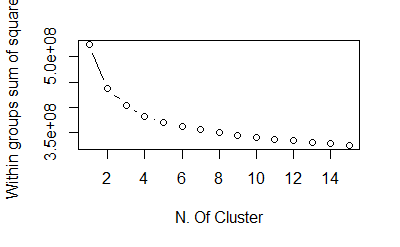

```r
plot(x=1:15,y=totWithinss,type="b", xlab="N. Of Cluster",ylab="Within groups sum of squares")
```

So, the kmeans model is computed and saved for the optimum k.

```r
k = 5
kmModel5 <- kmeans(pca.matrix, centers = k, nstart = 10)
summary(kmModel5)
```

```
             Length Class  Mode
cluster      8401   -none- numeric
centers      2900   -none- numeric
totss           1   -none- numeric
withinss        5   -none- numeric
tot.withinss    1   -none- numeric
betweenss       1   -none- numeric
size            5   -none- numeric
iter            1   -none- numeric
ifault          1   -none- numeric
```

Station locations are plotted with their corresponding codes.

```
[2021-03-25 18:23:52] Doing inventory ...
[2021-03-25 18:23:52] Done.
```

| stationID | longitude | latitude | altitude | name |
| --- | --- | --- | --- | --- |
| NZ75400 | -178.117 | -14.3167 | 36 | Kolopelu(Wallis_and_Futuna) |
| NZ82400 | -169.933 | -19.0667 | 59 | Hakupu(Niue) |
| NZ84317 | -159.800 | -21.2000 | 4 | RarotongaIA(Cook_Island) |
| NZ99701 | -177.933 | -29.2333 | 49 | Bells_Beach(New_Zealand) |
| SP00646 | -168.300 | -17.7167 | 24 | ocean_buoy |
| US14000 | -170.767 | -14.3000 | 408 | Aoloau(American_Samoa) |
| US14690 | -170.700 | -14.3167 | 3 | Aoloau(American_Samoa) |

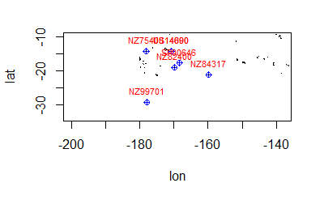

```r
stationInfo("C:/Users/usuario/Desktop/TRMM-Calibration/TRMM-time-series/WT_Analysis_Calibration/SP_ascii.zip")
```

```r
lista <- lapply(1:k, function(x) subsetDimension(pp_reanalysis, dimension = "time", indices = which(kmModel5$cluster == x)) %>% climatology())
```

```
[2021-06-11 16:46:29] - Computing climatology...
[2021-06-11 16:46:34] - Done.
[2021-06-11 16:46:37] - Computing climatology...
[2021-06-11 16:46:53] - Done.
[2021-06-11 16:46:55] - Computing climatology...
[2021-06-11 16:47:08] - Done.
[2021-06-11 16:47:09] - Computing climatology...
[2021-06-11 16:47:11] - Done.
[2021-06-11 16:47:13] - Computing climatology...
[2021-06-11 16:47:38] - Done.
```

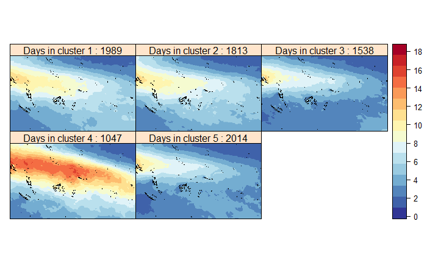

```r
kmedias.pp <- bindGrid(lista, dimension = "member", skip.temporal.check = TRUE)

spatialPlot(kmedias.pp,backdrop.theme = 'countries', rev.color = T, as.table = T, names.attr = paste("Days in cluster", 1:k, ":",kmModel5$size[1:k]))
```

```r
k = 6
kmModel6 <- kmeans(pca.matrix, centers = k, nstart = 10)
summary(kmModel6)
```

```
             Length Class  Mode
cluster      8401   -none- numeric
centers      3480   -none- numeric
totss           1   -none- numeric
withinss        6   -none- numeric
tot.withinss    1   -none- numeric
betweenss       1   -none- numeric
size            6   -none- numeric
iter            1   -none- numeric
ifault          1   -none- numeric
```

```r
lista <- lapply(1:k, function(x) subsetDimension(pp_reanalysis, dimension = "time", indices = which(kmModel6$cluster == x)) %>% climatology())
```

```
[2021-03-25 18:25:42] - Computing climatology...
[2021-03-25 18:25:45] - Done.
[2021-03-25 18:25:46] - Computing climatology...
[2021-03-25 18:25:47] - Done.
[2021-03-25 18:25:48] - Computing climatology...
[2021-03-25 18:25:50] - Done.
[2021-03-25 18:25:51] - Computing climatology...
[2021-03-25 18:25:58] - Done.
[2021-03-25 18:26:00] - Computing climatology...
[2021-03-25 18:26:03] - Done.
[2021-03-25 18:26:04] - Computing climatology...
[2021-03-25 18:26:05] - Done.
```

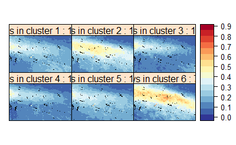

```r
kmedias.pp <- bindGrid(lista, dimension = "member", skip.temporal.check = TRUE)

spatialPlot(kmedias.pp,backdrop.theme = 'countries', rev.color = T, as.table = T, names.attr = paste("Days in cluster", 1:k, ":",kmModel6$size[1:k]))
```

MaxReturnValue function is computed to calculate the Maximum Return Value in 20 years index.

```r
MaxReturnValue <- function(data){
  #library(lubridate)
  #nyears <- round(time_length(difftime(cal.madrid.eqm$Dates$end[length(cal.madrid.eqm$Dates$end)], cal.madrid.eqm$Dates$start[1]),"years"))
  nyears <- 20
  data.maxYear <- aggregateGrid(redim(data), aggr.y = list(FUN = "max",na.rm = TRUE))

  data.maxrv <- climatology(data, clim.fun = list(FUN = "mean", na.rm = T))

  auxData <- data.maxYear$Data
  auxData[which(is.infinite(auxData))] <- NA

  if (any(!is.na(auxData))){
      auxGEV <- fgev(auxData)
      if ((auxGEV$estimate[3] - auxGEV$std.err[3] < 0) & (0  < auxGEV$estimate[3] + auxGEV$std.err[3])){
        auxGEV <- fgev(auxData, shape = 0)
        auxRV <- qgev(1-1/nyears, loc = auxGEV$estimate[1], scale = auxGEV$estimate[2], shape = 0)
      }else{
        auxRV <- qgev(1-1/nyears, loc = auxGEV$estimate[1], scale = auxGEV$estimate[2], shape = auxGEV$estimate[3])
      }
      data.maxrv <- as.numeric(auxRV)
      names(data.maxrv) <- paste("RV",nyears,"_max", sep = "")
  }
  return(data.maxrv)
  }
```

Finally, PACRAIN and TRMM precipitation data is loaded using loadeR funciton loadStationData. This data readout is easy and fast since both datasets are established in a ASCII format for each of the 7 PACRAIN station existing in our target area. Obviously, precip_obs is related with PACRAIN data and precip_trmm with TRMM data.

```r
precip_obs <- loadStationData("C:/Users/usuario/Desktop/TRMM-Calibration/TRMM-time-series/WT_Analysis_Calibration/SP_ascii.zip", var = "precip_obs")
```

```
[2021-03-25 18:26:39] Loading data ...
Warning in .Internal(gc(verbose, reset, full)) :
  closing unused connection 3 (C:/Users/usuario/Desktop/TRMM-Calibration/TRMM-time-series/WT_Analysis_Calibration/SP_ascii.zip:SP_ascii/precip_obs.txt)
[2021-03-25 18:26:40] Retrieving metadata ...
the condition has length > 1 and only the first element will be used[2021-03-25 18:26:40] Done.
```

```r
precip_trmm <- loadStationData("C:/Users/usuario/Desktop/TRMM-Calibration/TRMM-time-series/WT_Analysis_Calibration/SP_ascii.zip", var = "precip_trmm")
```

```
[2021-03-25 18:26:40] Loading data ...
Warning in .Internal(gc(verbose, reset, full)) :
  closing unused connection 3 (C:/Users/usuario/Desktop/TRMM-Calibration/TRMM-time-series/WT_Analysis_Calibration/SP_ascii.zip:SP_ascii/precip_trmm.txt)
[2021-03-25 18:26:40] Retrieving metadata ...
the condition has length > 1 and only the first element will be used[2021-03-25 18:26:41] Done.
```

# Assessment in PACRAIN stations

## Kolopelu (Wallis and Futuna) Station

### Raw not conditioned data

Target station data(TRMM and PACRAIN) selection.

```r
i=1

station.trmm <- subsetGrid(precip_trmm, station.id = precip_trmm$Metadata$station_id[i])
station.obs <- subsetGrid(precip_obs, station.id = precip_trmm$Metadata$station_id[i])
```

```
pad applied on the interval: day
pad applied on the interval: day
```

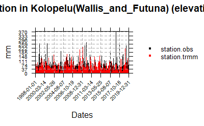

```r
temporalPlot(station.obs,station.trmm, xyplot.custom = list(main = paste("Precipitation in",station.trmm$Metadata$name,"(elevation",precip_trmm$Metadata$altitude[i],"m)"), ylab = "mm"))
```

```r
# temporalPlot(station.obs,station.reanalysis, xyplot.custom = list(main = paste("Precipitation in",station.trmm$Metadata$name,"(elevation",precip_trmm$Metadata$altitude[i],"m)"), ylab = "mm"))
```

```r
index.obs <- valueIndex1D(station.obs$Data[!is.na(station.obs$Data)],index.codes=c("Skewness","SDII","R10","R10p","R20","R20p","P98Wet"))
index.obs <- c(index.obs, valueIndex1D(station.obs$Data[!is.na(station.obs$Data)], index.codes = "P98WetAmount"))
index.obs.rv20max <- MaxReturnValue(station.obs)
```

```
[2021-03-25 18:26:44] Performing annual aggregation...
[2021-03-25 18:26:44] Done.
[2021-03-25 18:26:44] - Computing climatology...
[2021-03-25 18:26:44] - Done.
```

```r
index.trmm <- valueIndex1D(station.trmm$Data,index.codes=c("Skewness","SDII","R10","R10p","R20","R20p","P98Wet","P98WetAmount"))
index.trmm.rv20max <- MaxReturnValue(station.trmm)
```

```
[2021-03-25 18:26:44] Performing annual aggregation...
[2021-03-25 18:26:44] Done.
[2021-03-25 18:26:44] - Computing climatology...
[2021-03-25 18:26:44] - Done.
```

```r
# index.reanalysis <- valueIndex1D(station.reanalysis$Data,index.codes=c("Skewness","SDII","R10","R10p","R20","R20p","P98Wet","P98WetAmount"))
# index.reanalysis.rv20max <- MaxReturnValue(station.reanalysis)
```

```r
index.obs <- c(index.obs, index.obs.rv20max)
index.trmm <- c(index.trmm, index.trmm.rv20max)
# index.reanalysis <- c(index.reanalysis, index.reanalysis.rv20max)
```

```r
df <- data.frame(index.obs,index.trmm)
colnames(df) <- c("Obs", "TRMM")
format(df, digits = 3, scientific = 5)
```

|  | Obs | TRMM |
| --- | --- | --- |
| Skewness | 5.368 | 4.9309 |
| SDII | 16.227 | 16.2376 |
| R10 | 0.282 | 0.1630 |
| R10p | 62446.000 | 42013.8891 |
| R20 | 0.155 | 0.0958 |
| R20p | 50686.000 | 34287.9892 |
| P98Wet | 91.000 | 86.4384 |
| P98WetAmount | 11462.000 | 7280.4898 |
| RV20_max | 336.288 | 222.4940 |

### Assessment conditioned on WT

#### k=5

```r
station.obs.cl1 <- subsetDimension(station.obs, dimension = "time", indices = which(kmModel5$cluster == 1))
station.obs.cl2 <- subsetDimension(station.obs, dimension = "time", indices = which(kmModel5$cluster == 2))
station.obs.cl3 <- subsetDimension(station.obs, dimension = "time", indices = which(kmModel5$cluster == 3))
station.obs.cl4 <- subsetDimension(station.obs, dimension = "time", indices = which(kmModel5$cluster == 4))
station.obs.cl5 <- subsetDimension(station.obs, dimension = "time", indices = which(kmModel5$cluster == 5))
```

```r
station.trmm.cl1 <- subsetDimension(station.trmm, dimension = "time", indices = which(kmModel5$cluster == 1))
station.trmm.cl2 <- subsetDimension(station.trmm, dimension = "time", indices = which(kmModel5$cluster == 2))
station.trmm.cl3 <- subsetDimension(station.trmm, dimension = "time", indices = which(kmModel5$cluster == 3))
station.trmm.cl4 <- subsetDimension(station.trmm, dimension = "time", indices = which(kmModel5$cluster == 4))
station.trmm.cl5 <- subsetDimension(station.trmm, dimension = "time", indices = which(kmModel5$cluster == 5))
```

```r
index.obs.cl1 <- valueIndex1D(station.obs.cl1$Data,index.codes=c("Skewness","SDII","R10","R10p","R20","R20p","P98Wet"))
index.obs.cl1 <- c(index.obs.cl1, valueIndex1D(station.obs.cl1$Data[!is.na(station.obs.cl1$Data)], index.codes = "P98WetAmount"))
index.obs.cl1.rv20max <- MaxReturnValue(station.obs.cl1)
```

```
[2021-03-25 18:26:45] Performing annual aggregation...
[2021-03-25 18:26:45] Done.
[2021-03-25 18:26:45] - Computing climatology...
[2021-03-25 18:26:45] - Done.
```

```r
index.trmm.cl1 <- valueIndex1D(station.trmm.cl1$Data,index.codes=c("Skewness","SDII","R10","R10p","R20","R20p","P98Wet"))
index.trmm.cl1 <- c(index.trmm.cl1, valueIndex1D(station.trmm.cl1$Data[!is.na(station.trmm.cl1$Data)], index.codes = "P98WetAmount"))
index.trmm.cl1.rv20max <- MaxReturnValue(station.trmm.cl1)
```

```
[2021-03-25 18:26:45] Performing annual aggregation...
[2021-03-25 18:26:45] Done.
[2021-03-25 18:26:45] - Computing climatology...
[2021-03-25 18:26:45] - Done.
```

```r
index.obs.cl1 <- c(index.obs.cl1, index.obs.cl1.rv20max)
index.trmm.cl1 <- c(index.trmm.cl1, index.trmm.cl1.rv20max)
```

##### Index assessment conditioned on WT1

```r
df <- data.frame(index.obs.cl1,index.trmm.cl1)
colnames(df) <- c("Obs", "TRMM")
format(df, digits = 3, scientific = 5)
```

|  | Obs | TRMM |
| --- | --- | --- |
| Skewness | 4.8216 | 4.6404 |
| SDII | 13.5764 | 15.7325 |
| R10 | 0.1866 | 0.1310 |
| R10p | 11263.0000 | 8281.7098 |
| R20 | 0.0908 | 0.0759 |
| R20p | 8562.0000 | 6715.3498 |
| P98Wet | 79.0000 | 84.4836 |
| P98WetAmount | 2086.0000 | 1398.4500 |
| RV20_max | 163.6223 | 131.2402 |

```r
index.obs.cl2 <- valueIndex1D(station.obs.cl2$Data,index.codes=c("Skewness","SDII","R10","R10p","R20","R20p","P98Wet"))
index.obs.cl2 <- c(index.obs.cl2, valueIndex1D(station.obs.cl2$Data[!is.na(station.obs.cl2$Data)], index.codes = "P98WetAmount"))
index.obs.cl2.rv20max <- MaxReturnValue(station.obs.cl2)
```

```
[2021-03-25 18:26:46] Performing annual aggregation...
[2021-03-25 18:26:46] Done.
[2021-03-25 18:26:46] - Computing climatology...
[2021-03-25 18:26:46] - Done.
```

```r
index.trmm.cl2 <- valueIndex1D(station.trmm.cl2$Data,index.codes=c("Skewness","SDII","R10","R10p","R20","R20p","P98Wet"))
index.trmm.cl2 <- c(index.trmm.cl2, valueIndex1D(station.trmm.cl2$Data[!is.na(station.trmm.cl2$Data)], index.codes = "P98WetAmount"))
index.trmm.cl2.rv20max <- MaxReturnValue(station.trmm.cl2)
```

```
[2021-03-25 18:26:46] Performing annual aggregation...
[2021-03-25 18:26:46] Done.
[2021-03-25 18:26:46] - Computing climatology...
[2021-03-25 18:26:46] - Done.
```

```r
index.obs.cl2 <- c(index.obs.cl2, index.obs.cl2.rv20max)
index.trmm.cl2<- c(index.trmm.cl2, index.trmm.cl2.rv20max)
```

##### Index assessment conditioned on WT2

```r
df <- data.frame(index.obs.cl2,index.trmm.cl2)
colnames(df) <- c("Obs", "TRMM")
format(df, digits = 3, scientific = 5)
```

|  | Obs | TRMM |
| --- | --- | --- |
| Skewness | 5.777 | 4.838 |
| SDII | 20.892 | 19.295 |
| R10 | 0.265 | 0.210 |
| R10p | 11069.000 | 7846.470 |
| R20 | 0.163 | 0.133 |
| R20p | 9592.000 | 6724.200 |
| P98Wet | 121.400 | 103.559 |
| P98WetAmount | 2409.000 | 1498.740 |
| RV20_max | 245.538 | 162.010 |

```r
index.obs.cl3 <- valueIndex1D(station.obs.cl3$Data,index.codes=c("Skewness","SDII","R10","R10p","R20","R20p","P98Wet"))
index.obs.cl3 <- c(index.obs.cl3, valueIndex1D(station.obs.cl3$Data[!is.na(station.obs.cl3$Data)], index.codes = "P98WetAmount"))
index.obs.cl3.rv20max <- MaxReturnValue(station.obs.cl3)
```

```
[2021-03-25 18:26:46] Performing annual aggregation...
[2021-03-25 18:26:46] Done.
[2021-03-25 18:26:46] - Computing climatology...
[2021-03-25 18:26:46] - Done.
```

```r
index.trmm.cl3 <- valueIndex1D(station.trmm.cl3$Data,index.codes=c("Skewness","SDII","R10","R10p","R20","R20p","P98Wet"))
index.trmm.cl3 <- c(index.trmm.cl3, valueIndex1D(station.trmm.cl3$Data[!is.na(station.trmm.cl3$Data)], index.codes = "P98WetAmount"))
index.trmm.cl3.rv20max <- MaxReturnValue(station.trmm.cl3)
```

```
[2021-03-25 18:26:46] Performing annual aggregation...
[2021-03-25 18:26:46] Done.
[2021-03-25 18:26:46] - Computing climatology...
[2021-03-25 18:26:46] - Done.
```

```r
index.obs.cl3 <- c(index.obs.cl3, index.obs.cl3.rv20max)
index.trmm.cl3 <- c(index.trmm.cl3, index.trmm.cl3.rv20max)
```

##### Index assessment conditioned on WT3

```r
df <- data.frame(index.obs.cl3,index.trmm.cl3)
colnames(df) <- c("Obs", "TRMM")
format(df, digits = 3, scientific = 5)
```

|  | Obs | TRMM |
| --- | --- | --- |
| Skewness | 3.589 | 4.6950 |
| SDII | 15.553 | 14.7660 |
| R10 | 0.231 | 0.1634 |
| R10p | 14434.000 | 9706.1698 |
| R20 | 0.127 | 0.0905 |
| R20p | 11564.000 | 7589.6098 |
| P98Wet | 82.140 | 74.1150 |
| P98WetAmount | 2335.000 | 1704.9600 |
| RV20_max | 164.610 | 171.1679 |

```r
index.obs.cl4 <- valueIndex1D(station.obs.cl4$Data,index.codes=c("Skewness","SDII","R10","R10p","R20","R20p","P98Wet"))
index.obs.cl4 <- c(index.obs.cl4, valueIndex1D(station.obs.cl4$Data[!is.na(station.obs.cl4$Data)], index.codes = "P98WetAmount"))
index.obs.cl4.rv20max <- MaxReturnValue(station.obs.cl4)
```

```
[2021-03-25 18:26:46] Performing annual aggregation...
[2021-03-25 18:26:46] Done.
[2021-03-25 18:26:46] - Computing climatology...
[2021-03-25 18:26:46] - Done.
```

```r
index.trmm.cl4 <- valueIndex1D(station.trmm.cl4$Data,index.codes=c("Skewness","SDII","R10","R10p","R20","R20p","P98Wet"))
index.trmm.cl4 <- c(index.trmm.cl4, valueIndex1D(station.trmm.cl4$Data[!is.na(station.trmm.cl4$Data)], index.codes = "P98WetAmount"))
index.trmm.cl4.rv20max <- MaxReturnValue(station.trmm.cl4)
```

```
[2021-03-25 18:26:47] Performing annual aggregation...
[2021-03-25 18:26:47] Done.
[2021-03-25 18:26:47] - Computing climatology...
[2021-03-25 18:26:47] - Done.
```

```r
index.obs.cl4 <- c(index.obs.cl4, index.obs.cl4.rv20max)
index.trmm.cl4 <- c(index.trmm.cl4, index.trmm.cl4.rv20max)
```

##### Index assessment conditioned on WT4

```r
df <- data.frame(index.obs.cl4,index.trmm.cl4)
colnames(df) <- c("Obs", "TRMM")
format(df, digits = 3, scientific = 5)
```

|  | Obs | TRMM |
| --- | --- | --- |
| Skewness | 4.623 | 4.202 |
| SDII | 16.850 | 15.940 |
| R10 | 0.256 | 0.174 |
| R10p | 14661.000 | 9479.670 |
| R20 | 0.141 | 0.101 |
| R20p | 11795.000 | 7579.320 |
| P98Wet | 94.340 | 76.889 |
| P98WetAmount | 2535.000 | 1564.380 |
| RV20_max | 148.069 | 99.578 |

```r
index.obs.cl5 <- valueIndex1D(station.obs.cl5$Data,index.codes=c("Skewness","SDII","R10","R10p","R20","R20p","P98Wet"))
index.obs.cl5 <- c(index.obs.cl5, valueIndex1D(station.obs.cl5$Data[!is.na(station.obs.cl5$Data)], index.codes = "P98WetAmount"))
index.obs.cl5.rv20max <- MaxReturnValue(station.obs.cl5)
```

```
[2021-03-25 18:26:47] Performing annual aggregation...
[2021-03-25 18:26:47] Done.
[2021-03-25 18:26:47] - Computing climatology...
[2021-03-25 18:26:47] - Done.
```

```r
index.trmm.cl5 <- valueIndex1D(station.trmm.cl5$Data,index.codes=c("Skewness","SDII","R10","R10p","R20","R20p","P98Wet"))
index.trmm.cl5 <- c(index.trmm.cl5, valueIndex1D(station.trmm.cl5$Data[!is.na(station.trmm.cl5$Data)], index.codes = "P98WetAmount"))
index.trmm.cl5.rv20max <- MaxReturnValue(station.trmm.cl5)
```

```
[2021-03-25 18:26:47] Performing annual aggregation...
[2021-03-25 18:26:47] Done.
[2021-03-25 18:26:47] - Computing climatology...
[2021-03-25 18:26:47] - Done.
```

```r
index.obs.cl5 <- c(index.obs.cl5, index.obs.cl5.rv20max)
index.trmm.cl5 <- c(index.trmm.cl5, index.trmm.cl5.rv20max)
```

##### Index assessment conditioned on WT5

```r
df <- data.frame(index.obs.cl5,index.trmm.cl5)
colnames(df) <- c("Obs", "TRMM")
format(df, digits = 3, scientific = 5)
```

|  | Obs | TRMM |
| --- | --- | --- |
| Skewness | 4.998 | 5.3266 |
| SDII | 16.254 | 16.8420 |
| R10 | 0.208 | 0.1210 |
| R10p | 11019.000 | 6699.8699 |
| R20 | 0.120 | 0.0742 |
| R20p | 9173.000 | 5679.5099 |
| P98Wet | 91.000 | 102.4044 |
| P98WetAmount | 2103.000 | 1282.3500 |
| RV20_max | 222.156 | 161.2847 |

##### Difference between obs and raw/WT-conditioned data

```r
diff.df <- data.frame(abs(index.trmm-index.obs),abs(index.trmm.cl1-index.obs.cl1),
                      abs(index.trmm.cl2-index.obs.cl2), abs(index.trmm.cl3-index.obs.cl3), abs(index.trmm.cl4-index.obs.cl4), abs(index.trmm.cl5-index.obs.cl5)
                      )
colnames(diff.df) <- c("Raw","WT1", "WT2","WT3", "WT4","WT5")

format(diff.df, digits = 3, scientific = 5)
```

|  | Raw | WT1 | WT2 | WT3 | WT4 | WT5 |
| --- | --- | --- | --- | --- | --- | --- |
| Skewness | 0.4368 | 0.1812 | 0.9388 | 1.1059 | 0.4211 | 0.3281 |
| SDII | 0.0105 | 2.1560 | 1.5969 | 0.7871 | 0.9097 | 0.5876 |
| R10 | 0.1188 | 0.0556 | 0.0555 | 0.0679 | 0.0815 | 0.0872 |
| R10p | 20432.1109 | 2981.2902 | 3222.5302 | 4727.8302 | 5181.3302 | 4319.1301 |
| R20 | 0.0594 | 0.0149 | 0.0297 | 0.0362 | 0.0397 | 0.0455 |
| R20p | 16398.0108 | 1846.6502 | 2867.8002 | 3974.3902 | 4215.6801 | 3493.4901 |
| P98Wet | 4.5616 | 5.4836 | 17.8412 | 8.0250 | 17.4506 | 11.4044 |
| P98WetAmount | 4181.5102 | 687.5500 | 910.2601 | 630.0400 | 970.6200 | 820.6500 |
| RV20_max | 113.7941 | 32.3821 | 83.5276 | 6.5576 | 48.4909 | 60.8709 |

#### k = 6

```r
station.obs.cl1 <- subsetDimension(station.obs, dimension = "time", indices = which(kmModel6$cluster == 1))
station.obs.cl2 <- subsetDimension(station.obs, dimension = "time", indices = which(kmModel6$cluster == 2))
station.obs.cl3 <- subsetDimension(station.obs, dimension = "time", indices = which(kmModel6$cluster == 3))
station.obs.cl4 <- subsetDimension(station.obs, dimension = "time", indices = which(kmModel6$cluster == 4))
station.obs.cl5 <- subsetDimension(station.obs, dimension = "time", indices = which(kmModel6$cluster == 5))
station.obs.cl6 <- subsetDimension(station.obs, dimension = "time", indices = which(kmModel6$cluster == 6))
```

```r
station.trmm.cl1 <- subsetDimension(station.trmm, dimension = "time", indices = which(kmModel6$cluster == 1))
station.trmm.cl2 <- subsetDimension(station.trmm, dimension = "time", indices = which(kmModel6$cluster == 2))
station.trmm.cl3 <- subsetDimension(station.trmm, dimension = "time", indices = which(kmModel6$cluster == 3))
station.trmm.cl4 <- subsetDimension(station.trmm, dimension = "time", indices = which(kmModel6$cluster == 4))
station.trmm.cl5 <- subsetDimension(station.trmm, dimension = "time", indices = which(kmModel6$cluster == 5))
station.trmm.cl6 <- subsetDimension(station.trmm, dimension = "time", indices = which(kmModel6$cluster == 6))
```

```r
index.obs.cl1 <- valueIndex1D(station.obs.cl1$Data,index.codes=c("Skewness","SDII","R10","R10p","R20","R20p","P98Wet"))
index.obs.cl1 <- c(index.obs.cl1, valueIndex1D(station.obs.cl1$Data[!is.na(station.obs.cl1$Data)], index.codes = "P98WetAmount"))
index.obs.cl1.rv20max <- MaxReturnValue(station.obs.cl1)
```

```
[2021-03-25 18:26:48] Performing annual aggregation...
[2021-03-25 18:26:48] Done.
[2021-03-25 18:26:48] - Computing climatology...
[2021-03-25 18:26:48] - Done.
```

```r
index.trmm.cl1 <- valueIndex1D(station.trmm.cl1$Data,index.codes=c("Skewness","SDII","R10","R10p","R20","R20p","P98Wet"))
index.trmm.cl1 <- c(index.trmm.cl1, valueIndex1D(station.trmm.cl1$Data[!is.na(station.trmm.cl1$Data)], index.codes = "P98WetAmount"))
index.trmm.cl1.rv20max <- MaxReturnValue(station.trmm.cl1)
```

```
[2021-03-25 18:26:48] Performing annual aggregation...
[2021-03-25 18:26:48] Done.
[2021-03-25 18:26:48] - Computing climatology...
[2021-03-25 18:26:48] - Done.
```

```r
index.obs.cl1 <- c(index.obs.cl1, index.obs.cl1.rv20max)
index.trmm.cl1 <- c(index.trmm.cl1, index.trmm.cl1.rv20max)
```

##### Index assessment conditioned on WT1

```r
df <- data.frame(index.obs.cl1,index.trmm.cl1)
colnames(df) <- c("Obs", "TRMM")
format(df, digits = 3, scientific = 5)
```

|  | Obs | TRMM |
| --- | --- | --- |
| Skewness | 4.832 | 4.3719 |
| SDII | 15.267 | 15.4067 |
| R10 | 0.224 | 0.1493 |
| R10p | 12089.000 | 8002.8598 |
| R20 | 0.119 | 0.0865 |
| R20p | 9596.000 | 6425.6698 |
| P98Wet | 83.300 | 74.0160 |
| P98WetAmount | 2239.000 | 1341.2100 |
| RV20_max | 158.947 | 122.0994 |

```r
index.obs.cl2 <- valueIndex1D(station.obs.cl2$Data,index.codes=c("Skewness","SDII","R10","R10p","R20","R20p","P98Wet"))
index.obs.cl2 <- c(index.obs.cl2, valueIndex1D(station.obs.cl2$Data[!is.na(station.obs.cl2$Data)], index.codes = "P98WetAmount"))
index.obs.cl2.rv20max <- MaxReturnValue(station.obs.cl2)
```

```
[2021-03-25 18:26:49] Performing annual aggregation...
[2021-03-25 18:26:49] Done.
[2021-03-25 18:26:49] - Computing climatology...
[2021-03-25 18:26:49] - Done.
```

```r
index.trmm.cl2 <- valueIndex1D(station.trmm.cl2$Data,index.codes=c("Skewness","SDII","R10","R10p","R20","R20p","P98Wet"))
index.trmm.cl2 <- c(index.trmm.cl2, valueIndex1D(station.trmm.cl2$Data[!is.na(station.trmm.cl2$Data)], index.codes = "P98WetAmount"))
index.trmm.cl2.rv20max <- MaxReturnValue(station.trmm.cl2)
```

```
[2021-03-25 18:26:49] Performing annual aggregation...
[2021-03-25 18:26:49] Done.
[2021-03-25 18:26:49] - Computing climatology...
[2021-03-25 18:26:49] - Done.
```

```r
index.obs.cl2 <- c(index.obs.cl2, index.obs.cl2.rv20max)
index.trmm.cl2<- c(index.trmm.cl2, index.trmm.cl2.rv20max)
```

##### Index assessment conditioned on WT2

```r
df <- data.frame(index.obs.cl2,index.trmm.cl2)
colnames(df) <- c("Obs", "TRMM")
format(df, digits = 3, scientific = 5)
```

|  | Obs | TRMM |
| --- | --- | --- |
| Skewness | 3.771 | 4.850 |
| SDII | 18.209 | 17.448 |
| R10 | 0.239 | 0.190 |
| R10p | 10282.000 | 7746.840 |
| R20 | 0.152 | 0.114 |
| R20p | 8792.000 | 6446.640 |
| P98Wet | 98.100 | 97.247 |
| P98WetAmount | 1692.000 | 1512.660 |
| RV20_max | 154.057 | 144.862 |

```r
index.obs.cl3 <- valueIndex1D(station.obs.cl3$Data,index.codes=c("Skewness","SDII","R10","R10p","R20","R20p","P98Wet"))
index.obs.cl3 <- c(index.obs.cl3, valueIndex1D(station.obs.cl3$Data[!is.na(station.obs.cl3$Data)], index.codes = "P98WetAmount"))
index.obs.cl3.rv20max <- MaxReturnValue(station.obs.cl3)
```

```
[2021-03-25 18:26:49] Performing annual aggregation...
[2021-03-25 18:26:49] Done.
[2021-03-25 18:26:49] - Computing climatology...
[2021-03-25 18:26:49] - Done.
```

```r
index.trmm.cl3 <- valueIndex1D(station.trmm.cl3$Data,index.codes=c("Skewness","SDII","R10","R10p","R20","R20p","P98Wet"))
index.trmm.cl3 <- c(index.trmm.cl3, valueIndex1D(station.trmm.cl3$Data[!is.na(station.trmm.cl3$Data)], index.codes = "P98WetAmount"))
index.trmm.cl3.rv20max <- MaxReturnValue(station.trmm.cl3)
```

```
[2021-03-25 18:26:49] Performing annual aggregation...
[2021-03-25 18:26:49] Done.
[2021-03-25 18:26:49] - Computing climatology...
[2021-03-25 18:26:49] - Done.
```

```r
index.obs.cl3 <- c(index.obs.cl3, index.obs.cl3.rv20max)
index.trmm.cl3 <- c(index.trmm.cl3, index.trmm.cl3.rv20max)
```

##### Index assessment conditioned on WT3

```r
df <- data.frame(index.obs.cl3,index.trmm.cl3)
colnames(df) <- c("Obs", "TRMM")
format(df, digits = 3, scientific = 5)
```

|  | Obs | TRMM |
| --- | --- | --- |
| Skewness | 4.571 | 5.7124 |
| SDII | 15.271 | 16.4013 |
| R10 | 0.204 | 0.1178 |
| R10p | 8173.000 | 5052.5699 |
| R20 | 0.116 | 0.0677 |
| R20p | 6785.000 | 4197.8399 |
| P98Wet | 84.640 | 107.0736 |
| P98WetAmount | 1460.000 | 1064.7300 |
| RV20_max | 179.604 | 158.5101 |

```r
index.obs.cl4 <- valueIndex1D(station.obs.cl4$Data,index.codes=c("Skewness","SDII","R10","R10p","R20","R20p","P98Wet"))
index.obs.cl4 <- c(index.obs.cl4, valueIndex1D(station.obs.cl4$Data[!is.na(station.obs.cl4$Data)], index.codes = "P98WetAmount"))
index.obs.cl4.rv20max <- MaxReturnValue(station.obs.cl4)
```

```
[2021-03-25 18:26:49] Performing annual aggregation...
[2021-03-25 18:26:49] Done.
[2021-03-25 18:26:49] - Computing climatology...
[2021-03-25 18:26:49] - Done.
```

```r
index.trmm.cl4 <- valueIndex1D(station.trmm.cl4$Data,index.codes=c("Skewness","SDII","R10","R10p","R20","R20p","P98Wet"))
index.trmm.cl4 <- c(index.trmm.cl4, valueIndex1D(station.trmm.cl4$Data[!is.na(station.trmm.cl4$Data)], index.codes = "P98WetAmount"))
index.trmm.cl4.rv20max <- MaxReturnValue(station.trmm.cl4)
```

```
[2021-03-25 18:26:50] Performing annual aggregation...
[2021-03-25 18:26:50] Done.
[2021-03-25 18:26:50] - Computing climatology...
[2021-03-25 18:26:50] - Done.
```

```r
index.obs.cl4 <- c(index.obs.cl4, index.obs.cl4.rv20max)
index.trmm.cl4 <- c(index.trmm.cl4, index.trmm.cl4.rv20max)
```

##### Index assessment conditioned on WT4

```r
df <- data.frame(index.obs.cl4,index.trmm.cl4)
colnames(df) <- c("Obs", "TRMM")
format(df, digits = 3, scientific = 5)
```

|  | Obs | TRMM |
| --- | --- | --- |
| Skewness | 4.8674 | 4.6924 |
| SDII | 13.9988 | 15.6065 |
| R10 | 0.1922 | 0.1266 |
| R10p | 10064.0000 | 6898.3798 |
| R20 | 0.0909 | 0.0742 |
| R20p | 7578.0000 | 5612.6399 |
| P98Wet | 79.9000 | 75.5280 |
| P98WetAmount | 1833.0000 | 1151.6400 |
| RV20_max | 150.4811 | 139.4490 |

```r
index.obs.cl5 <- valueIndex1D(station.obs.cl5$Data,index.codes=c("Skewness","SDII","R10","R10p","R20","R20p","P98Wet"))
index.obs.cl5 <- c(index.obs.cl5, valueIndex1D(station.obs.cl5$Data[!is.na(station.obs.cl5$Data)], index.codes = "P98WetAmount"))
index.obs.cl5.rv20max <- MaxReturnValue(station.obs.cl5)
```

```
[2021-03-25 18:26:50] Performing annual aggregation...
[2021-03-25 18:26:50] Done.
[2021-03-25 18:26:50] - Computing climatology...
[2021-03-25 18:26:50] - Done.
```

```r
index.trmm.cl5 <- valueIndex1D(station.trmm.cl5$Data,index.codes=c("Skewness","SDII","R10","R10p","R20","R20p","P98Wet"))
index.trmm.cl5 <- c(index.trmm.cl5, valueIndex1D(station.trmm.cl5$Data[!is.na(station.trmm.cl5$Data)], index.codes = "P98WetAmount"))
index.trmm.cl5.rv20max <- MaxReturnValue(station.trmm.cl5)
```

```
[2021-03-25 18:26:50] Performing annual aggregation...
[2021-03-25 18:26:50] Done.
[2021-03-25 18:26:50] - Computing climatology...
[2021-03-25 18:26:50] - Done.
```

```r
index.obs.cl5 <- c(index.obs.cl5, index.obs.cl5.rv20max)
index.trmm.cl5 <- c(index.trmm.cl5, index.trmm.cl5.rv20max)
```

##### Index assessment conditioned on WT5

```r
df <- data.frame(index.obs.cl5,index.trmm.cl5)
colnames(df) <- c("Obs", "TRMM")
format(df, digits = 3, scientific = 5)
```

|  | Obs | TRMM |
| --- | --- | --- |
| Skewness | 4.638 | 4.3234 |
| SDII | 16.664 | 15.4552 |
| R10 | 0.245 | 0.1690 |
| R10p | 14134.000 | 8967.9299 |
| R20 | 0.136 | 0.0993 |
| R20p | 11444.000 | 7172.4899 |
| P98Wet | 94.000 | 72.7074 |
| P98WetAmount | 2593.000 | 1454.3700 |
| RV20_max | 125.083 | 112.1012 |

```r
index.obs.cl6 <- valueIndex1D(station.obs.cl6$Data,index.codes=c("Skewness","SDII","R10","R10p","R20","R20p","P98Wet"))
index.obs.cl6 <- c(index.obs.cl6, valueIndex1D(station.obs.cl6$Data[!is.na(station.obs.cl6$Data)], index.codes = "P98WetAmount"))
index.obs.cl6.rv20max <- MaxReturnValue(station.obs.cl6)
```

```
[2021-03-25 18:26:50] Performing annual aggregation...
no non-missing arguments to max; returning -Inf[2021-03-25 18:26:50] Done.
[2021-03-25 18:26:50] - Computing climatology...
[2021-03-25 18:26:50] - Done.
```

```r
index.trmm.cl6 <- valueIndex1D(station.trmm.cl6$Data,index.codes=c("Skewness","SDII","R10","R10p","R20","R20p","P98Wet"))
index.trmm.cl6 <- c(index.trmm.cl6, valueIndex1D(station.trmm.cl6$Data[!is.na(station.trmm.cl6$Data)], index.codes = "P98WetAmount"))
index.trmm.cl6.rv20max <- MaxReturnValue(station.trmm.cl6)
```

```
[2021-03-25 18:26:50] Performing annual aggregation...
[2021-03-25 18:26:50] Done.
[2021-03-25 18:26:50] - Computing climatology...
[2021-03-25 18:26:50] - Done.
```

```r
index.obs.cl6 <- c(index.obs.cl6, index.obs.cl6.rv20max)
index.trmm.cl6 <- c(index.trmm.cl6, index.trmm.cl6.rv20max)
```

##### Index assessment conditioned on WT6

```r
df <- data.frame(index.obs.cl6,index.trmm.cl6)
colnames(df) <- c("Obs", "TRMM")
format(df, digits = 3, scientific = 5)
```

|  | Obs | TRMM |
| --- | --- | --- |
| Skewness | 6.384 | 4.726 |
| SDII | 20.282 | 18.354 |
| R10 | 0.277 | 0.216 |
| R10p | 7704.000 | 5345.310 |
| R20 | 0.155 | 0.130 |
| R20p | 6491.000 | 4432.710 |
| P98Wet | 112.860 | 89.637 |
| P98WetAmount | 1812.000 | 911.940 |
| RV20_max | 230.405 | 100.724 |

##### Difference between obs and raw/WT-conditioned data

```r
diff.df <- data.frame(abs(index.trmm-index.obs),abs(index.trmm.cl1-index.obs.cl1),
                      abs(index.trmm.cl2-index.obs.cl2), abs(index.trmm.cl3-index.obs.cl3), abs(index.trmm.cl4-index.obs.cl4), abs(index.trmm.cl5-index.obs.cl5),abs(index.trmm.cl6-index.obs.cl6)
                      )
colnames(diff.df) <- c("Raw","WT1", "WT2","WT3", "WT4","WT5","WT6")

format(diff.df, digits = 3, scientific = 5)
```

|  | Raw | WT1 | WT2 | WT3 | WT4 | WT5 | WT6 |
| --- | --- | --- | --- | --- | --- | --- | --- |
| Skewness | 0.4368 | 0.4604 | 1.0786 | 1.1416 | 0.1751 | 0.3147 | 1.6580 |
| SDII | 0.0105 | 0.1396 | 0.7606 | 1.1304 | 1.6076 | 1.2090 | 1.9279 |
| R10 | 0.1188 | 0.0749 | 0.0493 | 0.0860 | 0.0656 | 0.0759 | 0.0607 |
| R10p | 20432.1109 | 4086.1402 | 2535.1602 | 3120.4301 | 3165.6202 | 5166.0701 | 2358.6902 |
| R20 | 0.0594 | 0.0329 | 0.0384 | 0.0485 | 0.0167 | 0.0368 | 0.0256 |
| R20p | 16398.0108 | 3170.3302 | 2345.3601 | 2587.1601 | 1965.3601 | 4271.5101 | 2058.2901 |
| P98Wet | 4.5616 | 9.2840 | 0.8532 | 22.4336 | 4.3720 | 21.2926 | 23.2230 |
| P98WetAmount | 4181.5102 | 897.7900 | 179.3400 | 395.2700 | 681.3600 | 1138.6300 | 900.0601 |
| RV20_max | 113.7941 | 36.8477 | 9.1952 | 21.0943 | 11.0321 | 12.9813 | 129.6812 |

## Hakupu (Niue) station

### Raw not conditioned data

```r
i=2

station.trmm <- subsetGrid(precip_trmm, station.id = precip_trmm$Metadata$station_id[i])
station.obs <- subsetGrid(precip_obs, station.id = precip_trmm$Metadata$station_id[i])
```

```r
# idx <- which.min(abs(pp_reanalysis$xyCoords$x - station.obs$xyCoords$x))
#
# lon <- pp_reanalysis$xyCoords$x[idx]
#
# idx2 <- which.min(abs(pp_reanalysis$xyCoords$y - station.obs$xyCoords$y))
# lat <- pp_reanalysis$xyCoords$y[idx2]
#
# station.reanalysis <- subsetGrid(pp_reanalysis, lonLim = lon, latLim = lat)
```

```
pad applied on the interval: day
pad applied on the interval: day
```

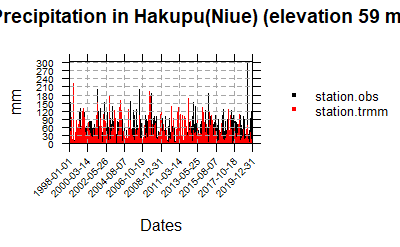

```r
temporalPlot(station.obs,station.trmm, xyplot.custom = list(main = paste("Precipitation in",station.trmm$Metadata$name,"(elevation",precip_trmm$Metadata$altitude[i],"m)"), ylab = "mm"))
```

```r
# temporalPlot(station.obs,station.reanalysis, xyplot.custom = list(main = paste("Precipitation in",station.trmm$Metadata$name,"(elevation",precip_trmm$Metadata$altitude[i],"m)"), ylab = "mm"))
```

```r
index.obs <- valueIndex1D(station.obs$Data[!is.na(station.obs$Data)],index.codes=c("Skewness","SDII","R10","R10p","R20","R20p","P98Wet"))
index.obs <- c(index.obs, valueIndex1D(station.obs$Data[!is.na(station.obs$Data)], index.codes = "P98WetAmount"))
index.obs.rv20max <- MaxReturnValue(station.obs)
```

```
[2021-03-25 18:26:52] Performing annual aggregation...
[2021-03-25 18:26:52] Done.
[2021-03-25 18:26:52] - Computing climatology...
[2021-03-25 18:26:52] - Done.
```

```r
index.trmm <- valueIndex1D(station.trmm$Data,index.codes=c("Skewness","SDII","R10","R10p","R20","R20p","P98Wet","P98WetAmount"))
index.trmm.rv20max <- MaxReturnValue(station.trmm)
```

```
[2021-03-25 18:26:52] Performing annual aggregation...
[2021-03-25 18:26:52] Done.
[2021-03-25 18:26:52] - Computing climatology...
[2021-03-25 18:26:52] - Done.
```

```r
# index.reanalysis <- valueIndex1D(station.reanalysis$Data,index.codes=c("Skewness","SDII","R10","R10p","R20","R20p","P98Wet","P98WetAmount"))
# index.reanalysis.rv20max <- MaxReturnValue(station.reanalysis)
```

```r
index.obs <- c(index.obs, index.obs.rv20max)
index.trmm <- c(index.trmm, index.trmm.rv20max)
# index.reanalysis <- c(index.reanalysis, index.reanalysis.rv20max)
```

```r
df <- data.frame(index.obs,index.trmm)
colnames(df) <- c("Obs", "TRMM")
format(df, digits = 3, scientific = 5)
```

|  | Obs | TRMM |
| --- | --- | --- |
| Skewness | 5.3072 | 6.4058 |
| SDII | 14.7325 | 14.4384 |
| R10 | 0.1577 | 0.0984 |
| R10p | 38733.1000 | 26006.5794 |
| R20 | 0.0946 | 0.0565 |
| R20p | 32137.5000 | 21168.2096 |
| P98Wet | 83.4000 | 86.1732 |
| P98WetAmount | 7499.3000 | 5307.3299 |
| RV20_max | 239.5212 | 211.6264 |

### Assessment conditioned on WT

#### k=5

```r
station.obs.cl1 <- subsetDimension(station.obs, dimension = "time", indices = which(kmModel5$cluster == 1))
station.obs.cl2 <- subsetDimension(station.obs, dimension = "time", indices = which(kmModel5$cluster == 2))
station.obs.cl3 <- subsetDimension(station.obs, dimension = "time", indices = which(kmModel5$cluster == 3))
station.obs.cl4 <- subsetDimension(station.obs, dimension = "time", indices = which(kmModel5$cluster == 4))
station.obs.cl5 <- subsetDimension(station.obs, dimension = "time", indices = which(kmModel5$cluster == 5))
```

```r
station.trmm.cl1 <- subsetDimension(station.trmm, dimension = "time", indices = which(kmModel5$cluster == 1))
station.trmm.cl2 <- subsetDimension(station.trmm, dimension = "time", indices = which(kmModel5$cluster == 2))
station.trmm.cl3 <- subsetDimension(station.trmm, dimension = "time", indices = which(kmModel5$cluster == 3))
station.trmm.cl4 <- subsetDimension(station.trmm, dimension = "time", indices = which(kmModel5$cluster == 4))
station.trmm.cl5 <- subsetDimension(station.trmm, dimension = "time", indices = which(kmModel5$cluster == 5))
```

```r
index.obs.cl1 <- valueIndex1D(station.obs.cl1$Data,index.codes=c("Skewness","SDII","R10","R10p","R20","R20p","P98Wet"))
index.obs.cl1 <- c(index.obs.cl1, valueIndex1D(station.obs.cl1$Data[!is.na(station.obs.cl1$Data)], index.codes = "P98WetAmount"))
index.obs.cl1.rv20max <- MaxReturnValue(station.obs.cl1)
```

```
[2021-03-25 18:26:53] Performing annual aggregation...
[2021-03-25 18:26:53] Done.
[2021-03-25 18:26:53] - Computing climatology...
[2021-03-25 18:26:53] - Done.
```

```r
index.trmm.cl1 <- valueIndex1D(station.trmm.cl1$Data,index.codes=c("Skewness","SDII","R10","R10p","R20","R20p","P98Wet"))
index.trmm.cl1 <- c(index.trmm.cl1, valueIndex1D(station.trmm.cl1$Data[!is.na(station.trmm.cl1$Data)], index.codes = "P98WetAmount"))
index.trmm.cl1.rv20max <- MaxReturnValue(station.trmm.cl1)
```

```
[2021-03-25 18:26:53] Performing annual aggregation...
[2021-03-25 18:26:53] Done.
[2021-03-25 18:26:53] - Computing climatology...
[2021-03-25 18:26:53] - Done.
```

```r
index.obs.cl1 <- c(index.obs.cl1, index.obs.cl1.rv20max)
index.trmm.cl1 <- c(index.trmm.cl1, index.trmm.cl1.rv20max)
```

##### Index assessment conditioned on WT1

```r
df <- data.frame(index.obs.cl1,index.trmm.cl1)
colnames(df) <- c("Obs", "TRMM")
format(df, digits = 3, scientific = 5)
```

|  | Obs | TRMM |
| --- | --- | --- |
| Skewness | 7.615 | 10.4766 |
| SDII | 13.270 | 12.2489 |
| R10 | 0.117 | 0.0610 |
| R10p | 7915.300 | 3779.4599 |
| R20 | 0.072 | 0.0308 |
| R20p | 6678.100 | 2939.6399 |
| P98Wet | 75.372 | 83.8494 |
| P98WetAmount | 1987.800 | 999.1200 |
| RV20_max | 167.615 | 177.4839 |

```r
index.obs.cl2 <- valueIndex1D(station.obs.cl2$Data,index.codes=c("Skewness","SDII","R10","R10p","R20","R20p","P98Wet"))
index.obs.cl2 <- c(index.obs.cl2, valueIndex1D(station.obs.cl2$Data[!is.na(station.obs.cl2$Data)], index.codes = "P98WetAmount"))
index.obs.cl2.rv20max <- MaxReturnValue(station.obs.cl2)
```

```
[2021-03-25 18:26:53] Performing annual aggregation...
[2021-03-25 18:26:53] Done.
[2021-03-25 18:26:53] - Computing climatology...
[2021-03-25 18:26:54] - Done.
```

```r
index.trmm.cl2 <- valueIndex1D(station.trmm.cl2$Data,index.codes=c("Skewness","SDII","R10","R10p","R20","R20p","P98Wet"))
index.trmm.cl2 <- c(index.trmm.cl2, valueIndex1D(station.trmm.cl2$Data[!is.na(station.trmm.cl2$Data)], index.codes = "P98WetAmount"))
index.trmm.cl2.rv20max <- MaxReturnValue(station.trmm.cl2)
```

```
[2021-03-25 18:26:54] Performing annual aggregation...
[2021-03-25 18:26:54] Done.
[2021-03-25 18:26:54] - Computing climatology...
[2021-03-25 18:26:54] - Done.
```

```r
index.obs.cl2 <- c(index.obs.cl2, index.obs.cl2.rv20max)
index.trmm.cl2<- c(index.trmm.cl2, index.trmm.cl2.rv20max)
```

##### Index assessment conditioned on WT2

```r
df <- data.frame(index.obs.cl2,index.trmm.cl2)
colnames(df) <- c("Obs", "TRMM")
format(df, digits = 3, scientific = 5)
```

|  | Obs | TRMM |
| --- | --- | --- |
| Skewness | 4.230 | 4.6728 |
| SDII | 14.831 | 15.0707 |
| R10 | 0.163 | 0.1282 |
| R10p | 5699.400 | 4478.5199 |
| R20 | 0.102 | 0.0756 |
| R20p | 4844.200 | 3678.6599 |
| P98Wet | 81.770 | 87.6900 |
| P98WetAmount | 1046.400 | 886.6800 |
| RV20_max | 106.761 | 165.6893 |

```r
index.obs.cl3 <- valueIndex1D(station.obs.cl3$Data,index.codes=c("Skewness","SDII","R10","R10p","R20","R20p","P98Wet"))
index.obs.cl3 <- c(index.obs.cl3, valueIndex1D(station.obs.cl3$Data[!is.na(station.obs.cl3$Data)], index.codes = "P98WetAmount"))
index.obs.cl3.rv20max <- MaxReturnValue(station.obs.cl3)
```

```
[2021-03-25 18:26:54] Performing annual aggregation...
[2021-03-25 18:26:54] Done.
[2021-03-25 18:26:54] - Computing climatology...
[2021-03-25 18:26:54] - Done.
```

```r
index.trmm.cl3 <- valueIndex1D(station.trmm.cl3$Data,index.codes=c("Skewness","SDII","R10","R10p","R20","R20p","P98Wet"))
index.trmm.cl3 <- c(index.trmm.cl3, valueIndex1D(station.trmm.cl3$Data[!is.na(station.trmm.cl3$Data)], index.codes = "P98WetAmount"))
index.trmm.cl3.rv20max <- MaxReturnValue(station.trmm.cl3)
```

```
[2021-03-25 18:26:54] Performing annual aggregation...
[2021-03-25 18:26:54] Done.
[2021-03-25 18:26:54] - Computing climatology...
[2021-03-25 18:26:54] - Done.
```

```r
index.obs.cl3 <- c(index.obs.cl3, index.obs.cl3.rv20max)
index.trmm.cl3 <- c(index.trmm.cl3, index.trmm.cl3.rv20max)
```

##### Index assessment conditioned on WT3

```r
df <- data.frame(index.obs.cl3,index.trmm.cl3)
colnames(df) <- c("Obs", "TRMM")
format(df, digits = 3, scientific = 5)
```

|  | Obs | TRMM |
| --- | --- | --- |
| Skewness | 4.594 | 5.1549 |
| SDII | 15.543 | 16.1575 |
| R10 | 0.163 | 0.1151 |
| R10p | 10369.100 | 7947.8998 |
| R20 | 0.096 | 0.0744 |
| R20p | 8445.800 | 6764.2199 |
| P98Wet | 85.376 | 84.5184 |
| P98WetAmount | 1868.800 | 1426.5000 |
| RV20_max | 169.208 | 131.3303 |

```r
index.obs.cl4 <- valueIndex1D(station.obs.cl4$Data,index.codes=c("Skewness","SDII","R10","R10p","R20","R20p","P98Wet"))
index.obs.cl4 <- c(index.obs.cl4, valueIndex1D(station.obs.cl4$Data[!is.na(station.obs.cl4$Data)], index.codes = "P98WetAmount"))
index.obs.cl4.rv20max <- MaxReturnValue(station.obs.cl4)
```

```
[2021-03-25 18:26:54] Performing annual aggregation...
[2021-03-25 18:26:54] Done.
[2021-03-25 18:26:54] - Computing climatology...
[2021-03-25 18:26:54] - Done.
```

```r
index.trmm.cl4 <- valueIndex1D(station.trmm.cl4$Data,index.codes=c("Skewness","SDII","R10","R10p","R20","R20p","P98Wet"))
index.trmm.cl4 <- c(index.trmm.cl4, valueIndex1D(station.trmm.cl4$Data[!is.na(station.trmm.cl4$Data)], index.codes = "P98WetAmount"))
index.trmm.cl4.rv20max <- MaxReturnValue(station.trmm.cl4)
```

```
[2021-03-25 18:26:54] Performing annual aggregation...
[2021-03-25 18:26:54] Done.
[2021-03-25 18:26:54] - Computing climatology...
[2021-03-25 18:26:54] - Done.
```

```r
index.obs.cl4 <- c(index.obs.cl4, index.obs.cl4.rv20max)
index.trmm.cl4 <- c(index.trmm.cl4, index.trmm.cl4.rv20max)
```

##### Index assessment conditioned on WT4

```r
df <- data.frame(index.obs.cl4,index.trmm.cl4)
colnames(df) <- c("Obs", "TRMM")
format(df, digits = 3, scientific = 5)
```

|  | Obs | TRMM |
| --- | --- | --- |
| Skewness | 4.3184 | 5.9464 |
| SDII | 15.5824 | 14.3248 |
| R10 | 0.1565 | 0.1135 |
| R10p | 9144.7000 | 6402.3599 |
| R20 | 0.0926 | 0.0601 |
| R20p | 7505.7000 | 4998.6299 |
| P98Wet | 83.1420 | 81.8352 |
| P98WetAmount | 1579.4000 | 1322.0700 |
| RV20_max | 151.8926 | 150.2834 |

```r
index.obs.cl5 <- valueIndex1D(station.obs.cl5$Data,index.codes=c("Skewness","SDII","R10","R10p","R20","R20p","P98Wet"))
index.obs.cl5 <- c(index.obs.cl5, valueIndex1D(station.obs.cl5$Data[!is.na(station.obs.cl5$Data)], index.codes = "P98WetAmount"))
index.obs.cl5.rv20max <- MaxReturnValue(station.obs.cl5)
```

```
[2021-03-25 18:26:55] Performing annual aggregation...
[2021-03-25 18:26:55] Done.
[2021-03-25 18:26:55] - Computing climatology...
[2021-03-25 18:26:55] - Done.
```

```r
index.trmm.cl5 <- valueIndex1D(station.trmm.cl5$Data,index.codes=c("Skewness","SDII","R10","R10p","R20","R20p","P98Wet"))
index.trmm.cl5 <- c(index.trmm.cl5, valueIndex1D(station.trmm.cl5$Data[!is.na(station.trmm.cl5$Data)], index.codes = "P98WetAmount"))
index.trmm.cl5.rv20max <- MaxReturnValue(station.trmm.cl5)
```

```
[2021-03-25 18:26:55] Performing annual aggregation...
[2021-03-25 18:26:55] Done.
[2021-03-25 18:26:55] - Computing climatology...
[2021-03-25 18:26:55] - Done.
```

```r
index.obs.cl5 <- c(index.obs.cl5, index.obs.cl5.rv20max)
index.trmm.cl5 <- c(index.trmm.cl5, index.trmm.cl5.rv20max)
```

##### Index assessment conditioned on WT5

```r
df <- data.frame(index.obs.cl5,index.trmm.cl5)
colnames(df) <- c("Obs", "TRMM")
format(df, digits = 3, scientific = 5)
```

|  | Obs | TRMM |
| --- | --- | --- |
| Skewness | 5.0540 | 7.4330 |
| SDII | 14.3514 | 13.5172 |
| R10 | 0.1034 | 0.0644 |
| R10p | 5604.6000 | 3398.3399 |
| R20 | 0.0605 | 0.0364 |
| R20p | 4663.7000 | 2787.0600 |
| P98Wet | 93.9080 | 94.8582 |
| P98WetAmount | 1169.8000 | 837.4500 |
| RV20_max | 126.1166 | 142.6790 |

##### Difference between obs and raw/WT-conditioned data

```r
diff.df <- data.frame(abs(index.trmm-index.obs),abs(index.trmm.cl1-index.obs.cl1),
                      abs(index.trmm.cl2-index.obs.cl2), abs(index.trmm.cl3-index.obs.cl3), abs(index.trmm.cl4-index.obs.cl4), abs(index.trmm.cl5-index.obs.cl5)
                      )
colnames(diff.df) <- c("Raw","WT1", "WT2","WT3", "WT4","WT5")

format(diff.df, digits = 3, scientific = 5)
```

|  | Raw | WT1 | WT2 | WT3 | WT4 | WT5 |
| --- | --- | --- | --- | --- | --- | --- |
| Skewness | 1.0986 | 2.8613 | 0.4424 | 0.5607 | 1.6280 | 2.3791 |
| SDII | 0.2941 | 1.0208 | 0.2393 | 0.6144 | 1.2576 | 0.8341 |
| R10 | 0.0592 | 0.0561 | 0.0344 | 0.0483 | 0.0430 | 0.0390 |
| R10p | 12726.5206 | 4135.8401 | 1220.8801 | 2421.2002 | 2742.3401 | 2206.2601 |
| R20 | 0.0381 | 0.0412 | 0.0268 | 0.0216 | 0.0325 | 0.0241 |
| R20p | 10969.2904 | 3738.4601 | 1165.5401 | 1681.5801 | 2507.0701 | 1876.6400 |
| P98Wet | 2.7732 | 8.4774 | 5.9200 | 0.8576 | 1.3068 | 0.9502 |
| P98WetAmount | 2191.9701 | 988.6800 | 159.7200 | 442.3000 | 257.3300 | 332.3500 |
| RV20_max | 27.8948 | 9.8685 | 58.9280 | 37.8773 | 1.6093 | 16.5624 |

#### k = 6

```r
station.obs.cl1 <- subsetDimension(station.obs, dimension = "time", indices = which(kmModel6$cluster == 1))
station.obs.cl2 <- subsetDimension(station.obs, dimension = "time", indices = which(kmModel6$cluster == 2))
station.obs.cl3 <- subsetDimension(station.obs, dimension = "time", indices = which(kmModel6$cluster == 3))
station.obs.cl4 <- subsetDimension(station.obs, dimension = "time", indices = which(kmModel6$cluster == 4))
station.obs.cl5 <- subsetDimension(station.obs, dimension = "time", indices = which(kmModel6$cluster == 5))
station.obs.cl6 <- subsetDimension(station.obs, dimension = "time", indices = which(kmModel6$cluster == 6))
```

```r
station.trmm.cl1 <- subsetDimension(station.trmm, dimension = "time", indices = which(kmModel6$cluster == 1))
station.trmm.cl2 <- subsetDimension(station.trmm, dimension = "time", indices = which(kmModel6$cluster == 2))
station.trmm.cl3 <- subsetDimension(station.trmm, dimension = "time", indices = which(kmModel6$cluster == 3))
station.trmm.cl4 <- subsetDimension(station.trmm, dimension = "time", indices = which(kmModel6$cluster == 4))
station.trmm.cl5 <- subsetDimension(station.trmm, dimension = "time", indices = which(kmModel6$cluster == 5))
station.trmm.cl6 <- subsetDimension(station.trmm, dimension = "time", indices = which(kmModel6$cluster == 6))
```

```r
index.obs.cl1 <- valueIndex1D(station.obs.cl1$Data,index.codes=c("Skewness","SDII","R10","R10p","R20","R20p","P98Wet"))
index.obs.cl1 <- c(index.obs.cl1, valueIndex1D(station.obs.cl1$Data[!is.na(station.obs.cl1$Data)], index.codes = "P98WetAmount"))
index.obs.cl1.rv20max <- MaxReturnValue(station.obs.cl1)
```

```
[2021-03-25 18:26:56] Performing annual aggregation...
[2021-03-25 18:26:56] Done.
[2021-03-25 18:26:56] - Computing climatology...
[2021-03-25 18:26:56] - Done.
```

```r
index.trmm.cl1 <- valueIndex1D(station.trmm.cl1$Data,index.codes=c("Skewness","SDII","R10","R10p","R20","R20p","P98Wet"))
index.trmm.cl1 <- c(index.trmm.cl1, valueIndex1D(station.trmm.cl1$Data[!is.na(station.trmm.cl1$Data)], index.codes = "P98WetAmount"))
index.trmm.cl1.rv20max <- MaxReturnValue(station.trmm.cl1)
```

```
[2021-03-25 18:26:56] Performing annual aggregation...
[2021-03-25 18:26:56] Done.
[2021-03-25 18:26:56] - Computing climatology...
[2021-03-25 18:26:56] - Done.
```

```r
index.obs.cl1 <- c(index.obs.cl1, index.obs.cl1.rv20max)
index.trmm.cl1 <- c(index.trmm.cl1, index.trmm.cl1.rv20max)
```

##### Index assessment conditioned on WT1

```r
df <- data.frame(index.obs.cl1,index.trmm.cl1)
colnames(df) <- c("Obs", "TRMM")
format(df, digits = 3, scientific = 5)
```

|  | Obs | TRMM |
| --- | --- | --- |
| Skewness | 5.091 | 5.1523 |
| SDII | 15.180 | 14.2695 |
| R10 | 0.152 | 0.0939 |
| R10p | 8306.600 | 5169.9599 |
| R20 | 0.083 | 0.0571 |
| R20p | 6603.900 | 4248.8999 |
| P98Wet | 92.688 | 82.9290 |
| P98WetAmount | 1608.700 | 896.1000 |
| RV20_max | 168.101 | 105.1428 |

```r
index.obs.cl2 <- valueIndex1D(station.obs.cl2$Data,index.codes=c("Skewness","SDII","R10","R10p","R20","R20p","P98Wet"))
index.obs.cl2 <- c(index.obs.cl2, valueIndex1D(station.obs.cl2$Data[!is.na(station.obs.cl2$Data)], index.codes = "P98WetAmount"))
index.obs.cl2.rv20max <- MaxReturnValue(station.obs.cl2)
```

```
[2021-03-25 18:26:56] Performing annual aggregation...
[2021-03-25 18:26:56] Done.
[2021-03-25 18:26:56] - Computing climatology...
[2021-03-25 18:26:56] - Done.
```

```r
index.trmm.cl2 <- valueIndex1D(station.trmm.cl2$Data,index.codes=c("Skewness","SDII","R10","R10p","R20","R20p","P98Wet"))
index.trmm.cl2 <- c(index.trmm.cl2, valueIndex1D(station.trmm.cl2$Data[!is.na(station.trmm.cl2$Data)], index.codes = "P98WetAmount"))
index.trmm.cl2.rv20max <- MaxReturnValue(station.trmm.cl2)
```

```
[2021-03-25 18:26:56] Performing annual aggregation...
[2021-03-25 18:26:56] Done.
[2021-03-25 18:26:56] - Computing climatology...
[2021-03-25 18:26:56] - Done.
```

```r
index.obs.cl2 <- c(index.obs.cl2, index.obs.cl2.rv20max)
index.trmm.cl2<- c(index.trmm.cl2, index.trmm.cl2.rv20max)
```

##### Index assessment conditioned on WT2

```r
df <- data.frame(index.obs.cl2,index.trmm.cl2)
colnames(df) <- c("Obs", "TRMM")
format(df, digits = 3, scientific = 5)
```

|  | Obs | TRMM |
| --- | --- | --- |
| Skewness | 3.919 | 4.8885 |
| SDII | 15.386 | 17.2758 |
| R10 | 0.158 | 0.1345 |
| R10p | 6130.500 | 5908.0498 |
| R20 | 0.100 | 0.0886 |
| R20p | 5175.000 | 5129.6099 |
| P98Wet | 81.572 | 101.8890 |
| P98WetAmount | 1033.300 | 1062.5100 |
| RV20_max | 125.009 | 146.9821 |

```r
index.obs.cl3 <- valueIndex1D(station.obs.cl3$Data,index.codes=c("Skewness","SDII","R10","R10p","R20","R20p","P98Wet"))
index.obs.cl3 <- c(index.obs.cl3, valueIndex1D(station.obs.cl3$Data[!is.na(station.obs.cl3$Data)], index.codes = "P98WetAmount"))
index.obs.cl3.rv20max <- MaxReturnValue(station.obs.cl3)
```

```
[2021-03-25 18:26:57] Performing annual aggregation...
[2021-03-25 18:26:57] Done.
[2021-03-25 18:26:57] - Computing climatology...
[2021-03-25 18:26:57] - Done.
```

```r
index.trmm.cl3 <- valueIndex1D(station.trmm.cl3$Data,index.codes=c("Skewness","SDII","R10","R10p","R20","R20p","P98Wet"))
index.trmm.cl3 <- c(index.trmm.cl3, valueIndex1D(station.trmm.cl3$Data[!is.na(station.trmm.cl3$Data)], index.codes = "P98WetAmount"))
index.trmm.cl3.rv20max <- MaxReturnValue(station.trmm.cl3)
```

```
[2021-03-25 18:26:57] Performing annual aggregation...
[2021-03-25 18:26:57] Done.
[2021-03-25 18:26:57] - Computing climatology...
[2021-03-25 18:26:57] - Done.
```

```r
index.obs.cl3 <- c(index.obs.cl3, index.obs.cl3.rv20max)
index.trmm.cl3 <- c(index.trmm.cl3, index.trmm.cl3.rv20max)
```

##### Index assessment conditioned on WT3

```r
df <- data.frame(index.obs.cl3,index.trmm.cl3)
colnames(df) <- c("Obs", "TRMM")
format(df, digits = 3, scientific = 5)
```

|  | Obs | TRMM |
| --- | --- | --- |
| Skewness | 4.9366 | 8.2126 |
| SDII | 13.0683 | 12.8766 |
| R10 | 0.0977 | 0.0576 |
| R10p | 3876.5000 | 2382.4800 |
| R20 | 0.0576 | 0.0301 |
| R20p | 3201.2000 | 1893.0300 |
| P98Wet | 74.9640 | 97.4628 |
| P98WetAmount | 803.8000 | 635.5800 |
| RV20_max | 121.5165 | 232.4994 |

```r
index.obs.cl4 <- valueIndex1D(station.obs.cl4$Data,index.codes=c("Skewness","SDII","R10","R10p","R20","R20p","P98Wet"))
index.obs.cl4 <- c(index.obs.cl4, valueIndex1D(station.obs.cl4$Data[!is.na(station.obs.cl4$Data)], index.codes = "P98WetAmount"))
index.obs.cl4.rv20max <- MaxReturnValue(station.obs.cl4)
```

```
[2021-03-25 18:26:57] Performing annual aggregation...
[2021-03-25 18:26:57] Done.
[2021-03-25 18:26:57] - Computing climatology...
[2021-03-25 18:26:57] - Done.
```

```r
index.trmm.cl4 <- valueIndex1D(station.trmm.cl4$Data,index.codes=c("Skewness","SDII","R10","R10p","R20","R20p","P98Wet"))
index.trmm.cl4 <- c(index.trmm.cl4, valueIndex1D(station.trmm.cl4$Data[!is.na(station.trmm.cl4$Data)], index.codes = "P98WetAmount"))
index.trmm.cl4.rv20max <- MaxReturnValue(station.trmm.cl4)
```

```
[2021-03-25 18:26:57] Performing annual aggregation...
[2021-03-25 18:26:57] Done.
[2021-03-25 18:26:57] - Computing climatology...
[2021-03-25 18:26:57] - Done.
```

```r
index.obs.cl4 <- c(index.obs.cl4, index.obs.cl4.rv20max)
index.trmm.cl4 <- c(index.trmm.cl4, index.trmm.cl4.rv20max)
```

##### Index assessment conditioned on WT4

```r
df <- data.frame(index.obs.cl4,index.trmm.cl4)
colnames(df) <- c("Obs", "TRMM")
format(df, digits = 3, scientific = 5)
```

|  | Obs | TRMM |
| --- | --- | --- |
| Skewness | 7.4011 | 10.3432 |
| SDII | 13.7917 | 12.7153 |
| R10 | 0.1128 | 0.0610 |
| R10p | 7099.1000 | 3405.1799 |
| R20 | 0.0731 | 0.0328 |
| R20p | 6146.4000 | 2732.3699 |
| P98Wet | 94.2480 | 84.0984 |
| P98WetAmount | 1814.4000 | 907.5000 |
| RV20_max | 178.5655 | 243.2407 |

```r
index.obs.cl5 <- valueIndex1D(station.obs.cl5$Data,index.codes=c("Skewness","SDII","R10","R10p","R20","R20p","P98Wet"))
index.obs.cl5 <- c(index.obs.cl5, valueIndex1D(station.obs.cl5$Data[!is.na(station.obs.cl5$Data)], index.codes = "P98WetAmount"))
index.obs.cl5.rv20max <- MaxReturnValue(station.obs.cl5)
```

```
[2021-03-25 18:26:57] Performing annual aggregation...
[2021-03-25 18:26:57] Done.
[2021-03-25 18:26:57] - Computing climatology...
[2021-03-25 18:26:57] - Done.
```

```r
index.trmm.cl5 <- valueIndex1D(station.trmm.cl5$Data,index.codes=c("Skewness","SDII","R10","R10p","R20","R20p","P98Wet"))
index.trmm.cl5 <- c(index.trmm.cl5, valueIndex1D(station.trmm.cl5$Data[!is.na(station.trmm.cl5$Data)], index.codes = "P98WetAmount"))
index.trmm.cl5.rv20max <- MaxReturnValue(station.trmm.cl5)
```

```
[2021-03-25 18:26:57] Performing annual aggregation...
[2021-03-25 18:26:57] Done.
[2021-03-25 18:26:57] - Computing climatology...
[2021-03-25 18:26:57] - Done.
```

```r
index.obs.cl5 <- c(index.obs.cl5, index.obs.cl5.rv20max)
index.trmm.cl5 <- c(index.trmm.cl5, index.trmm.cl5.rv20max)
```

##### Index assessment conditioned on WT5

```r
df <- data.frame(index.obs.cl5,index.trmm.cl5)
colnames(df) <- c("Obs", "TRMM")
format(df, digits = 3, scientific = 5)
```

|  | Obs | TRMM |
| --- | --- | --- |
| Skewness | 4.380 | 5.9312 |
| SDII | 15.447 | 14.5195 |
| R10 | 0.157 | 0.1110 |
| R10p | 8969.500 | 6307.4699 |
| R20 | 0.092 | 0.0597 |
| R20p | 7333.600 | 5007.0599 |
| P98Wet | 83.184 | 86.0688 |
| P98WetAmount | 1579.400 | 1327.7700 |
| RV20_max | 144.505 | 142.5250 |

```r
index.obs.cl6 <- valueIndex1D(station.obs.cl6$Data,index.codes=c("Skewness","SDII","R10","R10p","R20","R20p","P98Wet"))
index.obs.cl6 <- c(index.obs.cl6, valueIndex1D(station.obs.cl6$Data[!is.na(station.obs.cl6$Data)], index.codes = "P98WetAmount"))
index.obs.cl6.rv20max <- MaxReturnValue(station.obs.cl6)
```

```
[2021-03-25 18:26:58] Performing annual aggregation...
[2021-03-25 18:26:58] Done.
[2021-03-25 18:26:58] - Computing climatology...
[2021-03-25 18:26:58] - Done.
```

```r
index.trmm.cl6 <- valueIndex1D(station.trmm.cl6$Data,index.codes=c("Skewness","SDII","R10","R10p","R20","R20p","P98Wet"))
index.trmm.cl6 <- c(index.trmm.cl6, valueIndex1D(station.trmm.cl6$Data[!is.na(station.trmm.cl6$Data)], index.codes = "P98WetAmount"))
index.trmm.cl6.rv20max <- MaxReturnValue(station.trmm.cl6)
```

```
[2021-03-25 18:26:58] Performing annual aggregation...
[2021-03-25 18:26:58] Done.
[2021-03-25 18:26:58] - Computing climatology...
[2021-03-25 18:26:58] - Done.
```

```r
index.obs.cl6 <- c(index.obs.cl6, index.obs.cl6.rv20max)
index.trmm.cl6 <- c(index.trmm.cl6, index.trmm.cl6.rv20max)
```

##### Index assessment conditioned on WT6

```r
df <- data.frame(index.obs.cl6,index.trmm.cl6)
colnames(df) <- c("Obs", "TRMM")
format(df, digits = 3, scientific = 5)
```

|  | Obs | TRMM |
| --- | --- | --- |
| Skewness | 4.258 | 4.7175 |
| SDII | 15.157 | 13.9000 |
| R10 | 0.173 | 0.1255 |
| R10p | 4350.900 | 2833.4400 |
| R20 | 0.107 | 0.0661 |
| R20p | 3677.400 | 2157.2400 |
| P98Wet | 82.040 | 72.2580 |
| P98WetAmount | 778.600 | 501.9000 |
| RV20_max | 195.410 | 123.7588 |

##### Difference between obs and raw/WT-conditioned data

```r
diff.df <- data.frame(abs(index.trmm-index.obs),abs(index.trmm.cl1-index.obs.cl1),
                      abs(index.trmm.cl2-index.obs.cl2), abs(index.trmm.cl3-index.obs.cl3), abs(index.trmm.cl4-index.obs.cl4), abs(index.trmm.cl5-index.obs.cl5),abs(index.trmm.cl6-index.obs.cl6)
                      )
colnames(diff.df) <- c("Raw","WT1", "WT2","WT3", "WT4","WT5","WT6")

format(diff.df, digits = 3, scientific = 5)
```

|  | Raw | WT1 | WT2 | WT3 | WT4 | WT5 | WT6 |
| --- | --- | --- | --- | --- | --- | --- | --- |
| Skewness | 1.0986 | 0.0611 | 0.9691 | 3.2760 | 2.9420 | 1.5510 | 0.4599 |
| SDII | 0.2941 | 0.9103 | 1.8901 | 0.1917 | 1.0764 | 0.9277 | 1.2572 |
| R10 | 0.0592 | 0.0576 | 0.0234 | 0.0401 | 0.0518 | 0.0457 | 0.0472 |
| R10p | 12726.5206 | 3136.6401 | 222.4502 | 1494.0200 | 3693.9201 | 2662.0301 | 1517.4600 |
| R20 | 0.0381 | 0.0259 | 0.0117 | 0.0276 | 0.0403 | 0.0323 | 0.0405 |
| R20p | 10969.2904 | 2355.0001 | 45.3901 | 1308.1700 | 3414.0301 | 2326.5401 | 1520.1600 |
| P98Wet | 2.7732 | 9.7590 | 20.3170 | 22.4988 | 10.1496 | 2.8848 | 9.7820 |
| P98WetAmount | 2191.9701 | 712.6000 | 29.2100 | 168.2200 | 906.9000 | 251.6300 | 276.7000 |
| RV20_max | 27.8948 | 62.9583 | 21.9734 | 110.9829 | 64.6752 | 1.9798 | 71.6510 |

## Rarotonga International Airport (Cook Island) station

### Raw not conditioned data

```r
i=3

station.trmm <- subsetGrid(precip_trmm, station.id = precip_trmm$Metadata$station_id[i])
station.obs <- subsetGrid(precip_obs, station.id = precip_trmm$Metadata$station_id[i])
```

```r
# idx <- which.min(abs(pp_reanalysis$xyCoords$x - station.obs$xyCoords$x))
#
# lon <- pp_reanalysis$xyCoords$x[idx]
#
# idx2 <- which.min(abs(pp_reanalysis$xyCoords$y - station.obs$xyCoords$y))
# lat <- pp_reanalysis$xyCoords$y[idx2]
#
# station.reanalysis <- subsetGrid(pp_reanalysis, lonLim = lon, latLim = lat)
```

```
pad applied on the interval: day
pad applied on the interval: day
```

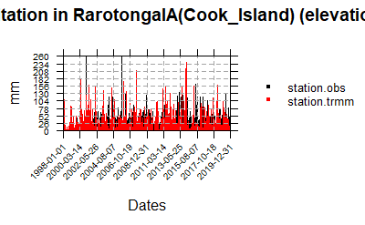

```r
temporalPlot(station.obs,station.trmm, xyplot.custom = list(main = paste("Precipitation in",station.trmm$Metadata$name,"(elevation",precip_trmm$Metadata$altitude[i],"m)"), ylab = "mm"))
```

```r
# temporalPlot(station.obs,station.reanalysis, xyplot.custom = list(main = paste("Precipitation in",station.trmm$Metadata$name,"(elevation",precip_trmm$Metadata$altitude[i],"m)"), ylab = "mm"))
```

```r
index.obs <- valueIndex1D(station.obs$Data[!is.na(station.obs$Data)],index.codes=c("Skewness","SDII","R10","R10p","R20","R20p","P98Wet"))
index.obs <- c(index.obs, valueIndex1D(station.obs$Data[!is.na(station.obs$Data)], index.codes = "P98WetAmount"))
index.obs.rv20max <- MaxReturnValue(station.obs)
```

```
[2021-03-25 18:27:00] Performing annual aggregation...
no non-missing arguments to max; returning -Inf[2021-03-25 18:27:00] Done.
[2021-03-25 18:27:00] - Computing climatology...
[2021-03-25 18:27:00] - Done.
```

```r
index.trmm <- valueIndex1D(station.trmm$Data,index.codes=c("Skewness","SDII","R10","R10p","R20","R20p","P98Wet","P98WetAmount"))
index.trmm.rv20max <- MaxReturnValue(station.trmm)
```

```
[2021-03-25 18:27:00] Performing annual aggregation...
[2021-03-25 18:27:00] Done.
[2021-03-25 18:27:00] - Computing climatology...
[2021-03-25 18:27:00] - Done.
```

```r
# index.reanalysis <- valueIndex1D(station.reanalysis$Data,index.codes=c("Skewness","SDII","R10","R10p","R20","R20p","P98Wet","P98WetAmount"))
# index.reanalysis.rv20max <- MaxReturnValue(station.reanalysis)
```

```r
index.obs <- c(index.obs, index.obs.rv20max)
index.trmm <- c(index.trmm, index.trmm.rv20max)
# index.reanalysis <- c(index.reanalysis, index.reanalysis.rv20max)
```

```r
df <- data.frame(index.obs,index.trmm)
colnames(df) <- c("Obs", "TRMM")
format(df, digits = 3, scientific = 5)
```

|  | Obs | TRMM |
| --- | --- | --- |
| Skewness | 6.0890 | 6.6158 |
| SDII | 13.0112 | 14.7257 |
| R10 | 0.1264 | 0.1075 |
| R10p | 26631.0000 | 28134.4194 |
| R20 | 0.0727 | 0.0601 |
| R20p | 21383.0000 | 22644.9595 |
| P98Wet | 69.2320 | 86.5470 |
| P98WetAmount | 5025.0000 | 5794.3799 |
| RV20_max | 204.3369 | 210.6556 |

### Assessment conditioned on WT

#### k=5

```r
station.obs.cl1 <- subsetDimension(station.obs, dimension = "time", indices = which(kmModel5$cluster == 1))
station.obs.cl2 <- subsetDimension(station.obs, dimension = "time", indices = which(kmModel5$cluster == 2))
station.obs.cl3 <- subsetDimension(station.obs, dimension = "time", indices = which(kmModel5$cluster == 3))
station.obs.cl4 <- subsetDimension(station.obs, dimension = "time", indices = which(kmModel5$cluster == 4))
station.obs.cl5 <- subsetDimension(station.obs, dimension = "time", indices = which(kmModel5$cluster == 5))
```

```r
station.trmm.cl1 <- subsetDimension(station.trmm, dimension = "time", indices = which(kmModel5$cluster == 1))
station.trmm.cl2 <- subsetDimension(station.trmm, dimension = "time", indices = which(kmModel5$cluster == 2))
station.trmm.cl3 <- subsetDimension(station.trmm, dimension = "time", indices = which(kmModel5$cluster == 3))
station.trmm.cl4 <- subsetDimension(station.trmm, dimension = "time", indices = which(kmModel5$cluster == 4))
station.trmm.cl5 <- subsetDimension(station.trmm, dimension = "time", indices = which(kmModel5$cluster == 5))
```

```r
index.obs.cl1 <- valueIndex1D(station.obs.cl1$Data,index.codes=c("Skewness","SDII","R10","R10p","R20","R20p","P98Wet"))
index.obs.cl1 <- c(index.obs.cl1, valueIndex1D(station.obs.cl1$Data[!is.na(station.obs.cl1$Data)], index.codes = "P98WetAmount"))
index.obs.cl1.rv20max <- MaxReturnValue(station.obs.cl1)
```

```
[2021-03-25 18:27:01] Performing annual aggregation...
no non-missing arguments to max; returning -Infno non-missing arguments to max; returning -Inf[2021-03-25 18:27:01] Done.
[2021-03-25 18:27:01] - Computing climatology...
[2021-03-25 18:27:01] - Done.
```

```r
index.trmm.cl1 <- valueIndex1D(station.trmm.cl1$Data,index.codes=c("Skewness","SDII","R10","R10p","R20","R20p","P98Wet"))
index.trmm.cl1 <- c(index.trmm.cl1, valueIndex1D(station.trmm.cl1$Data[!is.na(station.trmm.cl1$Data)], index.codes = "P98WetAmount"))
index.trmm.cl1.rv20max <- MaxReturnValue(station.trmm.cl1)
```

```
[2021-03-25 18:27:01] Performing annual aggregation...
[2021-03-25 18:27:01] Done.
[2021-03-25 18:27:01] - Computing climatology...
[2021-03-25 18:27:01] - Done.
```

```r
index.obs.cl1 <- c(index.obs.cl1, index.obs.cl1.rv20max)
index.trmm.cl1 <- c(index.trmm.cl1, index.trmm.cl1.rv20max)
```

##### Index assessment conditioned on WT1

```r
df <- data.frame(index.obs.cl1,index.trmm.cl1)
colnames(df) <- c("Obs", "TRMM")
format(df, digits = 3, scientific = 5)
```

|  | Obs | TRMM |
| --- | --- | --- |
| Skewness | 8.4937 | 7.6098 |
| SDII | 11.8074 | 11.9708 |
| R10 | 0.0829 | 0.0710 |
| R10p | 5075.0000 | 4088.2799 |
| R20 | 0.0447 | 0.0328 |
| R20p | 4002.0000 | 2992.0499 |
| P98Wet | 68.7440 | 76.3470 |
| P98WetAmount | 1237.8000 | 952.3500 |
| RV20_max | 174.1226 | 132.6600 |

```r
index.obs.cl2 <- valueIndex1D(station.obs.cl2$Data,index.codes=c("Skewness","SDII","R10","R10p","R20","R20p","P98Wet"))
index.obs.cl2 <- c(index.obs.cl2, valueIndex1D(station.obs.cl2$Data[!is.na(station.obs.cl2$Data)], index.codes = "P98WetAmount"))
index.obs.cl2.rv20max <- MaxReturnValue(station.obs.cl2)
```

```
[2021-03-25 18:27:01] Performing annual aggregation...
no non-missing arguments to max; returning -Infno non-missing arguments to max; returning -Inf[2021-03-25 18:27:01] Done.
[2021-03-25 18:27:01] - Computing climatology...
[2021-03-25 18:27:01] - Done.
```

```r
index.trmm.cl2 <- valueIndex1D(station.trmm.cl2$Data,index.codes=c("Skewness","SDII","R10","R10p","R20","R20p","P98Wet"))
index.trmm.cl2 <- c(index.trmm.cl2, valueIndex1D(station.trmm.cl2$Data[!is.na(station.trmm.cl2$Data)], index.codes = "P98WetAmount"))
index.trmm.cl2.rv20max <- MaxReturnValue(station.trmm.cl2)
```

```
[2021-03-25 18:27:01] Performing annual aggregation...
[2021-03-25 18:27:01] Done.
[2021-03-25 18:27:01] - Computing climatology...
[2021-03-25 18:27:01] - Done.
```

```r
index.obs.cl2 <- c(index.obs.cl2, index.obs.cl2.rv20max)
index.trmm.cl2<- c(index.trmm.cl2, index.trmm.cl2.rv20max)
```

##### Index assessment conditioned on WT2

```r
df <- data.frame(index.obs.cl2,index.trmm.cl2)
colnames(df) <- c("Obs", "TRMM")
format(df, digits = 3, scientific = 5)
```

|  | Obs | TRMM |
| --- | --- | --- |
| Skewness | 4.0978 | 5.5454 |
| SDII | 15.2597 | 17.0410 |
| R10 | 0.1340 | 0.1416 |
| R10p | 4791.2000 | 5455.9499 |
| R20 | 0.0909 | 0.0813 |
| R20p | 4142.8000 | 4554.9299 |
| P98Wet | 85.7920 | 104.1384 |
| P98WetAmount | 771.2000 | 1193.5200 |
| RV20_max | 99.6177 | 198.4776 |

```r
index.obs.cl3 <- valueIndex1D(station.obs.cl3$Data,index.codes=c("Skewness","SDII","R10","R10p","R20","R20p","P98Wet"))
index.obs.cl3 <- c(index.obs.cl3, valueIndex1D(station.obs.cl3$Data[!is.na(station.obs.cl3$Data)], index.codes = "P98WetAmount"))
index.obs.cl3.rv20max <- MaxReturnValue(station.obs.cl3)
```

```
[2021-03-25 18:27:02] Performing annual aggregation...
no non-missing arguments to max; returning -Infno non-missing arguments to max; returning -Infno non-missing arguments to max; returning -Inf[2021-03-25 18:27:02] Done.
[2021-03-25 18:27:02] - Computing climatology...
[2021-03-25 18:27:02] - Done.
```

```r
index.trmm.cl3 <- valueIndex1D(station.trmm.cl3$Data,index.codes=c("Skewness","SDII","R10","R10p","R20","R20p","P98Wet"))
index.trmm.cl3 <- c(index.trmm.cl3, valueIndex1D(station.trmm.cl3$Data[!is.na(station.trmm.cl3$Data)], index.codes = "P98WetAmount"))
index.trmm.cl3.rv20max <- MaxReturnValue(station.trmm.cl3)
```

```
[2021-03-25 18:27:02] Performing annual aggregation...
[2021-03-25 18:27:02] Done.
[2021-03-25 18:27:02] - Computing climatology...
[2021-03-25 18:27:02] - Done.
```

```r
index.obs.cl3 <- c(index.obs.cl3, index.obs.cl3.rv20max)
index.trmm.cl3 <- c(index.trmm.cl3, index.trmm.cl3.rv20max)
```

##### Index assessment conditioned on WT3

```r
df <- data.frame(index.obs.cl3,index.trmm.cl3)
colnames(df) <- c("Obs", "TRMM")
format(df, digits = 3, scientific = 5)
```

|  | Obs | TRMM |
| --- | --- | --- |
| Skewness | 6.4282 | 5.8845 |
| SDII | 13.4116 | 16.5589 |
| R10 | 0.1187 | 0.1297 |
| R10p | 7250.8000 | 8653.8298 |
| R20 | 0.0659 | 0.0744 |
| R20p | 5761.6000 | 7048.1699 |
| P98Wet | 69.1200 | 88.3164 |
| P98WetAmount | 1327.8000 | 1646.7600 |
| RV20_max | 131.3741 | 128.6084 |

```r
index.obs.cl4 <- valueIndex1D(station.obs.cl4$Data,index.codes=c("Skewness","SDII","R10","R10p","R20","R20p","P98Wet"))
index.obs.cl4 <- c(index.obs.cl4, valueIndex1D(station.obs.cl4$Data[!is.na(station.obs.cl4$Data)], index.codes = "P98WetAmount"))
index.obs.cl4.rv20max <- MaxReturnValue(station.obs.cl4)
```

```
[2021-03-25 18:27:02] Performing annual aggregation...
no non-missing arguments to max; returning -Infno non-missing arguments to max; returning -Inf[2021-03-25 18:27:02] Done.
[2021-03-25 18:27:02] - Computing climatology...
[2021-03-25 18:27:02] - Done.
```

```r
index.trmm.cl4 <- valueIndex1D(station.trmm.cl4$Data,index.codes=c("Skewness","SDII","R10","R10p","R20","R20p","P98Wet"))
index.trmm.cl4 <- c(index.trmm.cl4, valueIndex1D(station.trmm.cl4$Data[!is.na(station.trmm.cl4$Data)], index.codes = "P98WetAmount"))
index.trmm.cl4.rv20max <- MaxReturnValue(station.trmm.cl4)
```

```
[2021-03-25 18:27:02] Performing annual aggregation...
[2021-03-25 18:27:02] Done.
[2021-03-25 18:27:02] - Computing climatology...
[2021-03-25 18:27:02] - Done.
```

```r
index.obs.cl4 <- c(index.obs.cl4, index.obs.cl4.rv20max)
index.trmm.cl4 <- c(index.trmm.cl4, index.trmm.cl4.rv20max)
```

##### Index assessment conditioned on WT4

```r
df <- data.frame(index.obs.cl4,index.trmm.cl4)
colnames(df) <- c("Obs", "TRMM")
format(df, digits = 3, scientific = 5)
```

|  | Obs | TRMM |
| --- | --- | --- |
| Skewness | 3.6954 | 6.8464 |
| SDII | 12.4630 | 14.3806 |
| R10 | 0.1113 | 0.1129 |
| R10p | 5582.4000 | 6440.3699 |
| R20 | 0.0639 | 0.0639 |
| R20p | 4362.6000 | 5168.7299 |
| P98Wet | 61.0000 | 77.5800 |
| P98WetAmount | 809.6000 | 1431.3000 |
| RV20_max | 72.1081 | 175.5725 |

```r
index.obs.cl5 <- valueIndex1D(station.obs.cl5$Data,index.codes=c("Skewness","SDII","R10","R10p","R20","R20p","P98Wet"))
index.obs.cl5 <- c(index.obs.cl5, valueIndex1D(station.obs.cl5$Data[!is.na(station.obs.cl5$Data)], index.codes = "P98WetAmount"))
index.obs.cl5.rv20max <- MaxReturnValue(station.obs.cl5)
```

```
[2021-03-25 18:27:02] Performing annual aggregation...
no non-missing arguments to max; returning -Inf[2021-03-25 18:27:02] Done.
[2021-03-25 18:27:02] - Computing climatology...
[2021-03-25 18:27:02] - Done.
```

```r
index.trmm.cl5 <- valueIndex1D(station.trmm.cl5$Data,index.codes=c("Skewness","SDII","R10","R10p","R20","R20p","P98Wet"))
index.trmm.cl5 <- c(index.trmm.cl5, valueIndex1D(station.trmm.cl5$Data[!is.na(station.trmm.cl5$Data)], index.codes = "P98WetAmount"))
index.trmm.cl5.rv20max <- MaxReturnValue(station.trmm.cl5)
```

```
[2021-03-25 18:27:03] Performing annual aggregation...
[2021-03-25 18:27:03] Done.
[2021-03-25 18:27:03] - Computing climatology...
[2021-03-25 18:27:03] - Done.
```

```r
index.obs.cl5 <- c(index.obs.cl5, index.obs.cl5.rv20max)
index.trmm.cl5 <- c(index.trmm.cl5, index.trmm.cl5.rv20max)
```

##### Index assessment conditioned on WT5

```r
df <- data.frame(index.obs.cl5,index.trmm.cl5)
colnames(df) <- c("Obs", "TRMM")
format(df, digits = 3, scientific = 5)
```

|  | Obs | TRMM |
| --- | --- | --- |
| Skewness | 5.9647 | 5.9208 |
| SDII | 12.7126 | 12.9367 |
| R10 | 0.0813 | 0.0716 |
| R10p | 3931.6000 | 3495.9899 |
| R20 | 0.0442 | 0.0442 |
| R20p | 3114.0000 | 2881.0799 |
| P98Wet | 72.7720 | 73.7964 |
| P98WetAmount | 802.0000 | 681.2700 |
| RV20_max | 122.6246 | 119.1354 |

##### Difference between obs and raw/WT-conditioned data

```r
diff.df <- data.frame(abs(index.trmm-index.obs),abs(index.trmm.cl1-index.obs.cl1),
                      abs(index.trmm.cl2-index.obs.cl2), abs(index.trmm.cl3-index.obs.cl3), abs(index.trmm.cl4-index.obs.cl4), abs(index.trmm.cl5-index.obs.cl5)
                      )
colnames(diff.df) <- c("Raw","WT1", "WT2","WT3", "WT4","WT5")

format(diff.df, digits = 3, scientific = 5)
```

|  | Raw | WT1 | WT2 | WT3 | WT4 | WT5 |
| --- | --- | --- | --- | --- | --- | --- |
| Skewness | 0.5269 | 0.8839 | 1.44763 | 0.54367 | 3.15100 | 0.04388 |
| SDII | 1.7144 | 0.1635 | 1.78137 | 3.14731 | 1.91752 | 0.22403 |
| R10 | 0.0189 | 0.0119 | 0.00766 | 0.01106 | 0.00165 | 0.00976 |
| R10p | 1503.4194 | 986.7201 | 664.74987 | 1403.02982 | 857.96985 | 435.61007 |
| R20 | 0.0126 | 0.0119 | 0.00957 | 0.00855 | 0.00000 | 0.00000 |
| R20p | 1261.9595 | 1009.9501 | 412.12989 | 1286.56987 | 806.12989 | 232.92006 |
| P98Wet | 17.3150 | 7.6030 | 18.34640 | 19.19640 | 16.57999 | 1.02440 |
| P98WetAmount | 769.3799 | 285.4500 | 422.31997 | 318.96000 | 621.69996 | 120.73003 |
| RV20_max | 6.3187 | 41.4626 | 98.85994 | 2.76572 | 103.46439 | 3.48919 |

#### k = 6

```r
station.obs.cl1 <- subsetDimension(station.obs, dimension = "time", indices = which(kmModel6$cluster == 1))
station.obs.cl2 <- subsetDimension(station.obs, dimension = "time", indices = which(kmModel6$cluster == 2))
station.obs.cl3 <- subsetDimension(station.obs, dimension = "time", indices = which(kmModel6$cluster == 3))
station.obs.cl4 <- subsetDimension(station.obs, dimension = "time", indices = which(kmModel6$cluster == 4))
station.obs.cl5 <- subsetDimension(station.obs, dimension = "time", indices = which(kmModel6$cluster == 5))
station.obs.cl6 <- subsetDimension(station.obs, dimension = "time", indices = which(kmModel6$cluster == 6))
```

```r
station.trmm.cl1 <- subsetDimension(station.trmm, dimension = "time", indices = which(kmModel6$cluster == 1))
station.trmm.cl2 <- subsetDimension(station.trmm, dimension = "time", indices = which(kmModel6$cluster == 2))
station.trmm.cl3 <- subsetDimension(station.trmm, dimension = "time", indices = which(kmModel6$cluster == 3))
station.trmm.cl4 <- subsetDimension(station.trmm, dimension = "time", indices = which(kmModel6$cluster == 4))
station.trmm.cl5 <- subsetDimension(station.trmm, dimension = "time", indices = which(kmModel6$cluster == 5))
station.trmm.cl6 <- subsetDimension(station.trmm, dimension = "time", indices = which(kmModel6$cluster == 6))
```

```r
index.obs.cl1 <- valueIndex1D(station.obs.cl1$Data,index.codes=c("Skewness","SDII","R10","R10p","R20","R20p","P98Wet"))
index.obs.cl1 <- c(index.obs.cl1, valueIndex1D(station.obs.cl1$Data[!is.na(station.obs.cl1$Data)], index.codes = "P98WetAmount"))
index.obs.cl1.rv20max <- MaxReturnValue(station.obs.cl1)
```

```
[2021-03-25 18:27:04] Performing annual aggregation...
no non-missing arguments to max; returning -Infno non-missing arguments to max; returning -Inf[2021-03-25 18:27:04] Done.
[2021-03-25 18:27:04] - Computing climatology...
[2021-03-25 18:27:04] - Done.
```

```r
index.trmm.cl1 <- valueIndex1D(station.trmm.cl1$Data,index.codes=c("Skewness","SDII","R10","R10p","R20","R20p","P98Wet"))
index.trmm.cl1 <- c(index.trmm.cl1, valueIndex1D(station.trmm.cl1$Data[!is.na(station.trmm.cl1$Data)], index.codes = "P98WetAmount"))
index.trmm.cl1.rv20max <- MaxReturnValue(station.trmm.cl1)
```

```
[2021-03-25 18:27:04] Performing annual aggregation...
[2021-03-25 18:27:04] Done.
[2021-03-25 18:27:04] - Computing climatology...
[2021-03-25 18:27:04] - Done.
```

```r
index.obs.cl1 <- c(index.obs.cl1, index.obs.cl1.rv20max)
index.trmm.cl1 <- c(index.trmm.cl1, index.trmm.cl1.rv20max)
```

##### Index assessment conditioned on WT1

```r
df <- data.frame(index.obs.cl1,index.trmm.cl1)
colnames(df) <- c("Obs", "TRMM")
format(df, digits = 3, scientific = 5)
```

|  | Obs | TRMM |
| --- | --- | --- |
| Skewness | 5.1792 | 5.6234 |
| SDII | 12.6140 | 16.1861 |
| R10 | 0.1037 | 0.1164 |
| R10p | 5330.8000 | 6734.5799 |
| R20 | 0.0571 | 0.0686 |
| R20p | 4169.6000 | 5557.9199 |
| P98Wet | 63.4200 | 86.9940 |
| P98WetAmount | 949.6000 | 1285.2600 |
| RV20_max | 97.0523 | 119.0016 |

```r
index.obs.cl2 <- valueIndex1D(station.obs.cl2$Data,index.codes=c("Skewness","SDII","R10","R10p","R20","R20p","P98Wet"))
index.obs.cl2 <- c(index.obs.cl2, valueIndex1D(station.obs.cl2$Data[!is.na(station.obs.cl2$Data)], index.codes = "P98WetAmount"))
index.obs.cl2.rv20max <- MaxReturnValue(station.obs.cl2)
```

```
[2021-03-25 18:27:04] Performing annual aggregation...
no non-missing arguments to max; returning -Infno non-missing arguments to max; returning -Infno non-missing arguments to max; returning -Inf[2021-03-25 18:27:04] Done.
[2021-03-25 18:27:04] - Computing climatology...
[2021-03-25 18:27:04] - Done.
```

```r
index.trmm.cl2 <- valueIndex1D(station.trmm.cl2$Data,index.codes=c("Skewness","SDII","R10","R10p","R20","R20p","P98Wet"))
index.trmm.cl2 <- c(index.trmm.cl2, valueIndex1D(station.trmm.cl2$Data[!is.na(station.trmm.cl2$Data)], index.codes = "P98WetAmount"))
index.trmm.cl2.rv20max <- MaxReturnValue(station.trmm.cl2)
```

```
[2021-03-25 18:27:04] Performing annual aggregation...
[2021-03-25 18:27:04] Done.
[2021-03-25 18:27:04] - Computing climatology...
[2021-03-25 18:27:04] - Done.
```

```r
index.obs.cl2 <- c(index.obs.cl2, index.obs.cl2.rv20max)
index.trmm.cl2<- c(index.trmm.cl2, index.trmm.cl2.rv20max)
```

##### Index assessment conditioned on WT2

```r
df <- data.frame(index.obs.cl2,index.trmm.cl2)
colnames(df) <- c("Obs", "TRMM")
format(df, digits = 3, scientific = 5)
```

|  | Obs | TRMM |
| --- | --- | --- |
| Skewness | 6.477 | 5.7851 |
| SDII | 14.638 | 17.1969 |
| R10 | 0.134 | 0.1395 |
| R10p | 5191.600 | 5878.8299 |
| R20 | 0.076 | 0.0844 |
| R20p | 4210.200 | 4905.5099 |
| P98Wet | 83.568 | 92.4108 |
| P98WetAmount | 1026.600 | 1052.5800 |
| RV20_max | 174.100 | 79.8653 |

```r
index.obs.cl3 <- valueIndex1D(station.obs.cl3$Data,index.codes=c("Skewness","SDII","R10","R10p","R20","R20p","P98Wet"))
index.obs.cl3 <- c(index.obs.cl3, valueIndex1D(station.obs.cl3$Data[!is.na(station.obs.cl3$Data)], index.codes = "P98WetAmount"))
index.obs.cl3.rv20max <- MaxReturnValue(station.obs.cl3)
```

```
[2021-03-25 18:27:04] Performing annual aggregation...
no non-missing arguments to max; returning -Inf[2021-03-25 18:27:04] Done.
[2021-03-25 18:27:04] - Computing climatology...
[2021-03-25 18:27:04] - Done.
```

```r
index.trmm.cl3 <- valueIndex1D(station.trmm.cl3$Data,index.codes=c("Skewness","SDII","R10","R10p","R20","R20p","P98Wet"))
index.trmm.cl3 <- c(index.trmm.cl3, valueIndex1D(station.trmm.cl3$Data[!is.na(station.trmm.cl3$Data)], index.codes = "P98WetAmount"))
index.trmm.cl3.rv20max <- MaxReturnValue(station.trmm.cl3)
```

```
[2021-03-25 18:27:05] Performing annual aggregation...
[2021-03-25 18:27:05] Done.
[2021-03-25 18:27:05] - Computing climatology...
[2021-03-25 18:27:05] - Done.
```

```r
index.obs.cl3 <- c(index.obs.cl3, index.obs.cl3.rv20max)
index.trmm.cl3 <- c(index.trmm.cl3, index.trmm.cl3.rv20max)
```

##### Index assessment conditioned on WT3

```r
df <- data.frame(index.obs.cl3,index.trmm.cl3)
colnames(df) <- c("Obs", "TRMM")
format(df, digits = 3, scientific = 5)
```

|  | Obs | TRMM |
| --- | --- | --- |
| Skewness | 5.2967 | 5.8957 |
| SDII | 11.5640 | 11.5269 |
| R10 | 0.0777 | 0.0643 |
| R10p | 2674.8000 | 2209.2000 |
| R20 | 0.0384 | 0.0343 |
| R20p | 2005.0000 | 1685.4000 |
| P98Wet | 68.7000 | 65.8434 |
| P98WetAmount | 542.0000 | 420.1200 |
| RV20_max | 110.2580 | 93.1517 |

```r
index.obs.cl4 <- valueIndex1D(station.obs.cl4$Data,index.codes=c("Skewness","SDII","R10","R10p","R20","R20p","P98Wet"))
index.obs.cl4 <- c(index.obs.cl4, valueIndex1D(station.obs.cl4$Data[!is.na(station.obs.cl4$Data)], index.codes = "P98WetAmount"))
index.obs.cl4.rv20max <- MaxReturnValue(station.obs.cl4)
```

```
[2021-03-25 18:27:05] Performing annual aggregation...
no non-missing arguments to max; returning -Inf[2021-03-25 18:27:05] Done.
[2021-03-25 18:27:05] - Computing climatology...
[2021-03-25 18:27:05] - Done.
```

```r
index.trmm.cl4 <- valueIndex1D(station.trmm.cl4$Data,index.codes=c("Skewness","SDII","R10","R10p","R20","R20p","P98Wet"))
index.trmm.cl4 <- c(index.trmm.cl4, valueIndex1D(station.trmm.cl4$Data[!is.na(station.trmm.cl4$Data)], index.codes = "P98WetAmount"))
index.trmm.cl4.rv20max <- MaxReturnValue(station.trmm.cl4)
```

```
[2021-03-25 18:27:05] Performing annual aggregation...
[2021-03-25 18:27:05] Done.
[2021-03-25 18:27:05] - Computing climatology...
[2021-03-25 18:27:05] - Done.
```

```r
index.obs.cl4 <- c(index.obs.cl4, index.obs.cl4.rv20max)
index.trmm.cl4 <- c(index.trmm.cl4, index.trmm.cl4.rv20max)
```

##### Index assessment conditioned on WT4

```r
df <- data.frame(index.obs.cl4,index.trmm.cl4)
colnames(df) <- c("Obs", "TRMM")
format(df, digits = 3, scientific = 5)
```

|  | Obs | TRMM |
| --- | --- | --- |
| Skewness | 8.4060 | 7.1874 |
| SDII | 12.0899 | 11.8409 |
| R10 | 0.0800 | 0.0702 |
| R10p | 4479.8000 | 3472.9199 |
| R20 | 0.0455 | 0.0322 |
| R20p | 3654.2000 | 2531.9699 |
| P98Wet | 72.9600 | 76.7850 |
| P98WetAmount | 1092.6000 | 799.8600 |
| RV20_max | 172.0607 | 120.3122 |

```r
index.obs.cl5 <- valueIndex1D(station.obs.cl5$Data,index.codes=c("Skewness","SDII","R10","R10p","R20","R20p","P98Wet"))
index.obs.cl5 <- c(index.obs.cl5, valueIndex1D(station.obs.cl5$Data[!is.na(station.obs.cl5$Data)], index.codes = "P98WetAmount"))
index.obs.cl5.rv20max <- MaxReturnValue(station.obs.cl5)
```

```
[2021-03-25 18:27:05] Performing annual aggregation...
no non-missing arguments to max; returning -Infno non-missing arguments to max; returning -Inf[2021-03-25 18:27:05] Done.
[2021-03-25 18:27:05] - Computing climatology...
[2021-03-25 18:27:06] - Done.
```

```r
index.trmm.cl5 <- valueIndex1D(station.trmm.cl5$Data,index.codes=c("Skewness","SDII","R10","R10p","R20","R20p","P98Wet"))
index.trmm.cl5 <- c(index.trmm.cl5, valueIndex1D(station.trmm.cl5$Data[!is.na(station.trmm.cl5$Data)], index.codes = "P98WetAmount"))
index.trmm.cl5.rv20max <- MaxReturnValue(station.trmm.cl5)
```

```
[2021-03-25 18:27:06] Performing annual aggregation...
[2021-03-25 18:27:06] Done.
[2021-03-25 18:27:06] - Computing climatology...
[2021-03-25 18:27:06] - Done.
```

```r
index.obs.cl5 <- c(index.obs.cl5, index.obs.cl5.rv20max)
index.trmm.cl5 <- c(index.trmm.cl5, index.trmm.cl5.rv20max)
```

##### Index assessment conditioned on WT5

```r
df <- data.frame(index.obs.cl5,index.trmm.cl5)
colnames(df) <- c("Obs", "TRMM")
format(df, digits = 3, scientific = 5)
```

|  | Obs | TRMM |
| --- | --- | --- |
| Skewness | 3.7362 | 7.0196 |
| SDII | 12.5889 | 14.1703 |
| R10 | 0.1093 | 0.1110 |
| R10p | 5560.2000 | 6135.1799 |
| R20 | 0.0647 | 0.0619 |
| R20p | 4437.8000 | 4864.4099 |
| P98Wet | 63.1720 | 74.1798 |
| P98WetAmount | 826.2000 | 1356.3000 |
| RV20_max | 69.9544 | 168.0923 |

```r
index.obs.cl6 <- valueIndex1D(station.obs.cl6$Data,index.codes=c("Skewness","SDII","R10","R10p","R20","R20p","P98Wet"))
index.obs.cl6 <- c(index.obs.cl6, valueIndex1D(station.obs.cl6$Data[!is.na(station.obs.cl6$Data)], index.codes = "P98WetAmount"))
index.obs.cl6.rv20max <- MaxReturnValue(station.obs.cl6)
```

```
[2021-03-25 18:27:06] Performing annual aggregation...
no non-missing arguments to max; returning -Infno non-missing arguments to max; returning -Inf[2021-03-25 18:27:06] Done.
[2021-03-25 18:27:06] - Computing climatology...
[2021-03-25 18:27:06] - Done.
```

```r
index.trmm.cl6 <- valueIndex1D(station.trmm.cl6$Data,index.codes=c("Skewness","SDII","R10","R10p","R20","R20p","P98Wet"))
index.trmm.cl6 <- c(index.trmm.cl6, valueIndex1D(station.trmm.cl6$Data[!is.na(station.trmm.cl6$Data)], index.codes = "P98WetAmount"))
index.trmm.cl6.rv20max <- MaxReturnValue(station.trmm.cl6)
```

```
[2021-03-25 18:27:06] Performing annual aggregation...
[2021-03-25 18:27:06] Done.
[2021-03-25 18:27:06] - Computing climatology...
[2021-03-25 18:27:06] - Done.
```

```r
index.obs.cl6 <- c(index.obs.cl6, index.obs.cl6.rv20max)
index.trmm.cl6 <- c(index.trmm.cl6, index.trmm.cl6.rv20max)
```

##### Index assessment conditioned on WT6

```r
df <- data.frame(index.obs.cl6,index.trmm.cl6)
colnames(df) <- c("Obs", "TRMM")
format(df, digits = 3, scientific = 5)
```

|  | Obs | TRMM |
| --- | --- | --- |
| Skewness | 3.7633 | 5.8176 |
| SDII | 15.3866 | 16.4536 |
| R10 | 0.1377 | 0.1309 |
| R10p | 3393.8000 | 3703.7099 |
| R20 | 0.0931 | 0.0742 |
| R20p | 2906.2000 | 3099.7499 |
| P98Wet | 78.6400 | 118.8210 |
| P98WetAmount | 510.0000 | 941.2500 |
| RV20_max | 103.9429 | 221.1614 |

##### Difference between obs and raw/WT-conditioned data

```r
diff.df <- data.frame(abs(index.trmm-index.obs),abs(index.trmm.cl1-index.obs.cl1),
                      abs(index.trmm.cl2-index.obs.cl2), abs(index.trmm.cl3-index.obs.cl3), abs(index.trmm.cl4-index.obs.cl4), abs(index.trmm.cl5-index.obs.cl5),abs(index.trmm.cl6-index.obs.cl6)
                      )
colnames(diff.df) <- c("Raw","WT1", "WT2","WT3", "WT4","WT5","WT6")

format(diff.df, digits = 3, scientific = 5)
```

|  | Raw | WT1 | WT2 | WT3 | WT4 | WT5 | WT6 |
| --- | --- | --- | --- | --- | --- | --- | --- |
| Skewness | 0.5269 | 0.4443 | 0.69228 | 0.59902 | 1.21860 | 3.28347 | 2.05428 |
| SDII | 1.7144 | 3.5722 | 2.55917 | 0.03704 | 0.24903 | 1.58145 | 1.06703 |
| R10 | 0.0189 | 0.0127 | 0.00585 | 0.01337 | 0.00978 | 0.00167 | 0.00675 |
| R10p | 1503.4194 | 1403.7799 | 687.22991 | 465.60005 | 1006.88010 | 574.97986 | 309.90988 |
| R20 | 0.0126 | 0.0115 | 0.00835 | 0.00418 | 0.01323 | 0.00279 | 0.01889 |
| R20p | 1261.9595 | 1388.3199 | 695.30993 | 319.60004 | 1122.23008 | 426.60989 | 193.54989 |
| P98Wet | 17.3150 | 23.5740 | 8.84280 | 2.85661 | 3.82500 | 11.00780 | 40.18100 |
| P98WetAmount | 769.3799 | 335.6600 | 25.98002 | 121.88002 | 292.74004 | 530.09996 | 431.24996 |
| RV20_max | 6.3187 | 21.9493 | 94.23472 | 17.10631 | 51.74849 | 98.13797 | 117.21848 |

## Bells Beach (New Zealand) station

### Raw not conditioned data

```r
i=4

station.trmm <- subsetGrid(precip_trmm, station.id = precip_trmm$Metadata$station_id[i])
station.obs <- subsetGrid(precip_obs, station.id = precip_trmm$Metadata$station_id[i])
```

```r
# idx <- which.min(abs(pp_reanalysis$xyCoords$x - station.obs$xyCoords$x))
#
# lon <- pp_reanalysis$xyCoords$x[idx]
#
# idx2 <- which.min(abs(pp_reanalysis$xyCoords$y - station.obs$xyCoords$y))
# lat <- pp_reanalysis$xyCoords$y[idx2]
#
# station.reanalysis <- subsetGrid(pp_reanalysis, lonLim = lon, latLim = lat)
```

```
pad applied on the interval: day
pad applied on the interval: day
```

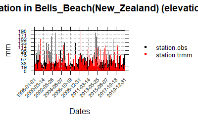

```r
temporalPlot(station.obs,station.trmm, xyplot.custom = list(main = paste("Precipitation in",station.trmm$Metadata$name,"(elevation",precip_trmm$Metadata$altitude[i],"m)"), ylab = "mm"))
```

```r
# temporalPlot(station.obs,station.reanalysis, xyplot.custom = list(main = paste("Precipitation in",station.trmm$Metadata$name,"(elevation",precip_trmm$Metadata$altitude[i],"m)"), ylab = "mm"))
```

```r
index.obs <- valueIndex1D(station.obs$Data[!is.na(station.obs$Data)],index.codes=c("Skewness","SDII","R10","R10p","R20","R20p","P98Wet"))
index.obs <- c(index.obs, valueIndex1D(station.obs$Data[!is.na(station.obs$Data)], index.codes = "P98WetAmount"))
index.obs.rv20max <- MaxReturnValue(station.obs)
```

```
[2021-03-25 18:27:08] Performing annual aggregation...
[2021-03-25 18:27:08] Done.
[2021-03-25 18:27:08] - Computing climatology...
[2021-03-25 18:27:08] - Done.
```

```r
index.trmm <- valueIndex1D(station.trmm$Data,index.codes=c("Skewness","SDII","R10","R10p","R20","R20p","P98Wet","P98WetAmount"))
index.trmm.rv20max <- MaxReturnValue(station.trmm)
```

```
[2021-03-25 18:27:08] Performing annual aggregation...
[2021-03-25 18:27:08] Done.
[2021-03-25 18:27:08] - Computing climatology...
[2021-03-25 18:27:08] - Done.
```

```r
# index.reanalysis <- valueIndex1D(station.reanalysis$Data,index.codes=c("Skewness","SDII","R10","R10p","R20","R20p","P98Wet","P98WetAmount"))
# index.reanalysis.rv20max <- MaxReturnValue(station.reanalysis)
```

```r
index.obs <- c(index.obs, index.obs.rv20max)
index.trmm <- c(index.trmm, index.trmm.rv20max)
# index.reanalysis <- c(index.reanalysis, index.reanalysis.rv20max)
```

```r
df <- data.frame(index.obs,index.trmm)
colnames(df) <- c("Obs", "TRMM")
format(df, digits = 3, scientific = 5)
```

|  | Obs | TRMM |
| --- | --- | --- |
| Skewness | 6.9039 | 7.8582 |
| SDII | 10.5418 | 12.1949 |
| R10 | 0.1062 | 0.0600 |
| R10p | 23269.0000 | 14116.0497 |
| R20 | 0.0527 | 0.0329 |
| R20p | 17337.4000 | 10988.0997 |
| P98Wet | 58.6800 | 70.3638 |
| P98WetAmount | 5418.2000 | 2918.1599 |
| RV20_max | 174.4866 | 174.5531 |

### Assessment conditioned on WT

#### k=5

```r
station.obs.cl1 <- subsetDimension(station.obs, dimension = "time", indices = which(kmModel5$cluster == 1))
station.obs.cl2 <- subsetDimension(station.obs, dimension = "time", indices = which(kmModel5$cluster == 2))
station.obs.cl3 <- subsetDimension(station.obs, dimension = "time", indices = which(kmModel5$cluster == 3))
station.obs.cl4 <- subsetDimension(station.obs, dimension = "time", indices = which(kmModel5$cluster == 4))
station.obs.cl5 <- subsetDimension(station.obs, dimension = "time", indices = which(kmModel5$cluster == 5))
```

```r
station.trmm.cl1 <- subsetDimension(station.trmm, dimension = "time", indices = which(kmModel5$cluster == 1))
station.trmm.cl2 <- subsetDimension(station.trmm, dimension = "time", indices = which(kmModel5$cluster == 2))
station.trmm.cl3 <- subsetDimension(station.trmm, dimension = "time", indices = which(kmModel5$cluster == 3))
station.trmm.cl4 <- subsetDimension(station.trmm, dimension = "time", indices = which(kmModel5$cluster == 4))
station.trmm.cl5 <- subsetDimension(station.trmm, dimension = "time", indices = which(kmModel5$cluster == 5))
```

```r
index.obs.cl1 <- valueIndex1D(station.obs.cl1$Data,index.codes=c("Skewness","SDII","R10","R10p","R20","R20p","P98Wet"))
index.obs.cl1 <- c(index.obs.cl1, valueIndex1D(station.obs.cl1$Data[!is.na(station.obs.cl1$Data)], index.codes = "P98WetAmount"))
index.obs.cl1.rv20max <- MaxReturnValue(station.obs.cl1)
```

```
[2021-03-25 18:27:09] Performing annual aggregation...
no non-missing arguments to max; returning -Inf[2021-03-25 18:27:09] Done.
[2021-03-25 18:27:09] - Computing climatology...
[2021-03-25 18:27:09] - Done.
```

```r
index.trmm.cl1 <- valueIndex1D(station.trmm.cl1$Data,index.codes=c("Skewness","SDII","R10","R10p","R20","R20p","P98Wet"))
index.trmm.cl1 <- c(index.trmm.cl1, valueIndex1D(station.trmm.cl1$Data[!is.na(station.trmm.cl1$Data)], index.codes = "P98WetAmount"))
index.trmm.cl1.rv20max <- MaxReturnValue(station.trmm.cl1)
```

```
[2021-03-25 18:27:09] Performing annual aggregation...
[2021-03-25 18:27:09] Done.
[2021-03-25 18:27:09] - Computing climatology...
[2021-03-25 18:27:09] - Done.
```

```r
index.obs.cl1 <- c(index.obs.cl1, index.obs.cl1.rv20max)
index.trmm.cl1 <- c(index.trmm.cl1, index.trmm.cl1.rv20max)
```

##### Index assessment conditioned on WT1

```r
df <- data.frame(index.obs.cl1,index.trmm.cl1)
colnames(df) <- c("Obs", "TRMM")
format(df, digits = 3, scientific = 5)
```

|  | Obs | TRMM |
| --- | --- | --- |
| Skewness | 5.3765 | 5.7524 |
| SDII | 9.1107 | 11.2937 |
| R10 | 0.0948 | 0.0581 |
| R10p | 4600.9000 | 3078.3599 |
| R20 | 0.0427 | 0.0318 |
| R20p | 3177.7000 | 2320.6499 |
| P98Wet | 48.6960 | 54.2700 |
| P98WetAmount | 962.7000 | 543.2700 |
| RV20_max | 79.8411 | 79.9349 |

```r
index.obs.cl2 <- valueIndex1D(station.obs.cl2$Data,index.codes=c("Skewness","SDII","R10","R10p","R20","R20p","P98Wet"))
index.obs.cl2 <- c(index.obs.cl2, valueIndex1D(station.obs.cl2$Data[!is.na(station.obs.cl2$Data)], index.codes = "P98WetAmount"))
index.obs.cl2.rv20max <- MaxReturnValue(station.obs.cl2)
```

```
[2021-03-25 18:27:09] Performing annual aggregation...
[2021-03-25 18:27:09] Done.
[2021-03-25 18:27:09] - Computing climatology...
[2021-03-25 18:27:09] - Done.
```

```r
index.trmm.cl2 <- valueIndex1D(station.trmm.cl2$Data,index.codes=c("Skewness","SDII","R10","R10p","R20","R20p","P98Wet"))
index.trmm.cl2 <- c(index.trmm.cl2, valueIndex1D(station.trmm.cl2$Data[!is.na(station.trmm.cl2$Data)], index.codes = "P98WetAmount"))
index.trmm.cl2.rv20max <- MaxReturnValue(station.trmm.cl2)
```

```
[2021-03-25 18:27:09] Performing annual aggregation...
[2021-03-25 18:27:09] Done.
[2021-03-25 18:27:09] - Computing climatology...
[2021-03-25 18:27:09] - Done.
```

```r
index.obs.cl2 <- c(index.obs.cl2, index.obs.cl2.rv20max)
index.trmm.cl2<- c(index.trmm.cl2, index.trmm.cl2.rv20max)
```

##### Index assessment conditioned on WT2

```r
df <- data.frame(index.obs.cl2,index.trmm.cl2)
colnames(df) <- c("Obs", "TRMM")
format(df, digits = 3, scientific = 5)
```

|  | Obs | TRMM |
| --- | --- | --- |
| Skewness | 6.9237 | 8.3914 |
| SDII | 12.1945 | 13.2594 |
| R10 | 0.1072 | 0.0498 |
| R10p | 3712.8000 | 1642.5900 |
| R20 | 0.0565 | 0.0230 |
| R20p | 2961.8000 | 1213.1400 |
| P98Wet | 85.9680 | 99.6120 |
| P98WetAmount | 1095.0000 | 447.5400 |
| RV20_max | 183.7217 | 79.2498 |

```r
index.obs.cl3 <- valueIndex1D(station.obs.cl3$Data,index.codes=c("Skewness","SDII","R10","R10p","R20","R20p","P98Wet"))
index.obs.cl3 <- c(index.obs.cl3, valueIndex1D(station.obs.cl3$Data[!is.na(station.obs.cl3$Data)], index.codes = "P98WetAmount"))
index.obs.cl3.rv20max <- MaxReturnValue(station.obs.cl3)
```

```
[2021-03-25 18:27:09] Performing annual aggregation...
[2021-03-25 18:27:09] Done.
[2021-03-25 18:27:10] - Computing climatology...
[2021-03-25 18:27:10] - Done.
```

```r
index.trmm.cl3 <- valueIndex1D(station.trmm.cl3$Data,index.codes=c("Skewness","SDII","R10","R10p","R20","R20p","P98Wet"))
index.trmm.cl3 <- c(index.trmm.cl3, valueIndex1D(station.trmm.cl3$Data[!is.na(station.trmm.cl3$Data)], index.codes = "P98WetAmount"))
index.trmm.cl3.rv20max <- MaxReturnValue(station.trmm.cl3)
```

```
[2021-03-25 18:27:10] Performing annual aggregation...
[2021-03-25 18:27:10] Done.
[2021-03-25 18:27:10] - Computing climatology...
[2021-03-25 18:27:10] - Done.
```

```r
index.obs.cl3 <- c(index.obs.cl3, index.obs.cl3.rv20max)
index.trmm.cl3 <- c(index.trmm.cl3, index.trmm.cl3.rv20max)
```

##### Index assessment conditioned on WT3

```r
df <- data.frame(index.obs.cl3,index.trmm.cl3)
colnames(df) <- c("Obs", "TRMM")
format(df, digits = 3, scientific = 5)
```

|  | Obs | TRMM |
| --- | --- | --- |
| Skewness | 6.7610 | 8.2432 |
| SDII | 11.1527 | 12.6970 |
| R10 | 0.1056 | 0.0593 |
| R10p | 5941.3000 | 3748.4999 |
| R20 | 0.0483 | 0.0337 |
| R20p | 4336.8000 | 3039.9299 |
| P98Wet | 71.1200 | 75.6924 |
| P98WetAmount | 1519.8000 | 842.5800 |
| RV20_max | 321.3827 | 61.6644 |

```r
index.obs.cl4 <- valueIndex1D(station.obs.cl4$Data,index.codes=c("Skewness","SDII","R10","R10p","R20","R20p","P98Wet"))
index.obs.cl4 <- c(index.obs.cl4, valueIndex1D(station.obs.cl4$Data[!is.na(station.obs.cl4$Data)], index.codes = "P98WetAmount"))
index.obs.cl4.rv20max <- MaxReturnValue(station.obs.cl4)
```

```
[2021-03-25 18:27:10] Performing annual aggregation...
[2021-03-25 18:27:10] Done.
[2021-03-25 18:27:10] - Computing climatology...
[2021-03-25 18:27:10] - Done.
```

```r
index.trmm.cl4 <- valueIndex1D(station.trmm.cl4$Data,index.codes=c("Skewness","SDII","R10","R10p","R20","R20p","P98Wet"))
index.trmm.cl4 <- c(index.trmm.cl4, valueIndex1D(station.trmm.cl4$Data[!is.na(station.trmm.cl4$Data)], index.codes = "P98WetAmount"))
index.trmm.cl4.rv20max <- MaxReturnValue(station.trmm.cl4)
```

```
[2021-03-25 18:27:10] Performing annual aggregation...
[2021-03-25 18:27:10] Done.
[2021-03-25 18:27:10] - Computing climatology...
[2021-03-25 18:27:10] - Done.
```

```r
index.obs.cl4 <- c(index.obs.cl4, index.obs.cl4.rv20max)
index.trmm.cl4 <- c(index.trmm.cl4, index.trmm.cl4.rv20max)
```

##### Index assessment conditioned on WT4

```r
df <- data.frame(index.obs.cl4,index.trmm.cl4)
colnames(df) <- c("Obs", "TRMM")
format(df, digits = 3, scientific = 5)
```

|  | Obs | TRMM |
| --- | --- | --- |
| Skewness | 5.9032 | 7.0952 |
| SDII | 10.0857 | 13.1409 |
| R10 | 0.1003 | 0.0645 |
| R10p | 4765.5000 | 3467.4300 |
| R20 | 0.0529 | 0.0347 |
| R20p | 3568.6000 | 2695.2900 |
| P98Wet | 51.8000 | 71.7420 |
| P98WetAmount | 947.2000 | 675.1500 |
| RV20_max | 119.1818 | 98.8492 |

```r
index.obs.cl5 <- valueIndex1D(station.obs.cl5$Data,index.codes=c("Skewness","SDII","R10","R10p","R20","R20p","P98Wet"))
index.obs.cl5 <- c(index.obs.cl5, valueIndex1D(station.obs.cl5$Data[!is.na(station.obs.cl5$Data)], index.codes = "P98WetAmount"))
index.obs.cl5.rv20max <- MaxReturnValue(station.obs.cl5)
```

```
[2021-03-25 18:27:10] Performing annual aggregation...
[2021-03-25 18:27:10] Done.
[2021-03-25 18:27:10] - Computing climatology...
[2021-03-25 18:27:10] - Done.
```

```r
index.trmm.cl5 <- valueIndex1D(station.trmm.cl5$Data,index.codes=c("Skewness","SDII","R10","R10p","R20","R20p","P98Wet"))
index.trmm.cl5 <- c(index.trmm.cl5, valueIndex1D(station.trmm.cl5$Data[!is.na(station.trmm.cl5$Data)], index.codes = "P98WetAmount"))
index.trmm.cl5.rv20max <- MaxReturnValue(station.trmm.cl5)
```

```
[2021-03-25 18:27:10] Performing annual aggregation...
[2021-03-25 18:27:10] Done.
[2021-03-25 18:27:10] - Computing climatology...
[2021-03-25 18:27:10] - Done.
```

```r
index.obs.cl5 <- c(index.obs.cl5, index.obs.cl5.rv20max)
index.trmm.cl5 <- c(index.trmm.cl5, index.trmm.cl5.rv20max)
```

##### Index assessment conditioned on WT5

```r
df <- data.frame(index.obs.cl5,index.trmm.cl5)
colnames(df) <- c("Obs", "TRMM")
format(df, digits = 3, scientific = 5)
```

|  | Obs | TRMM |
| --- | --- | --- |
| Skewness | 7.0463 | 8.7693 |
| SDII | 11.0245 | 10.9791 |
| R10 | 0.0995 | 0.0507 |
| R10p | 4248.5000 | 2179.1699 |
| R20 | 0.0547 | 0.0299 |
| R20p | 3292.5000 | 1719.0900 |
| P98Wet | 52.3960 | 56.2692 |
| P98WetAmount | 1000.9000 | 533.7300 |
| RV20_max | 171.5944 | 130.0982 |

##### Difference between obs and raw/WT-conditioned data

```r
diff.df <- data.frame(abs(index.trmm-index.obs),abs(index.trmm.cl1-index.obs.cl1),
                      abs(index.trmm.cl2-index.obs.cl2), abs(index.trmm.cl3-index.obs.cl3), abs(index.trmm.cl4-index.obs.cl4), abs(index.trmm.cl5-index.obs.cl5)
                      )
colnames(diff.df) <- c("Raw","WT1", "WT2","WT3", "WT4","WT5")

format(diff.df, digits = 3, scientific = 5)
```

|  | Raw | WT1 | WT2 | WT3 | WT4 | WT5 |
| --- | --- | --- | --- | --- | --- | --- |
| Skewness | 0.9542 | 0.3759 | 1.4677 | 1.4822 | 1.1921 | 1.7230 |
| SDII | 1.6531 | 2.1830 | 1.0649 | 1.5443 | 3.0552 | 0.0454 |
| R10 | 0.0462 | 0.0367 | 0.0574 | 0.0463 | 0.0358 | 0.0488 |
| R10p | 9152.9503 | 1522.5401 | 2070.2100 | 2192.8001 | 1298.0700 | 2069.3301 |
| R20 | 0.0199 | 0.0109 | 0.0335 | 0.0146 | 0.0182 | 0.0247 |
| R20p | 6349.3003 | 857.0501 | 1748.6600 | 1296.8701 | 873.3100 | 1573.4100 |
| P98Wet | 11.6838 | 5.5740 | 13.6440 | 4.5724 | 19.9420 | 3.8732 |
| P98WetAmount | 2500.0401 | 419.4300 | 647.4600 | 677.2200 | 272.0500 | 467.1700 |
| RV20_max | 0.0664 | 0.0937 | 104.4719 | 259.7184 | 20.3326 | 41.4962 |

#### k = 6

```r
station.obs.cl1 <- subsetDimension(station.obs, dimension = "time", indices = which(kmModel6$cluster == 1))
station.obs.cl2 <- subsetDimension(station.obs, dimension = "time", indices = which(kmModel6$cluster == 2))
station.obs.cl3 <- subsetDimension(station.obs, dimension = "time", indices = which(kmModel6$cluster == 3))
station.obs.cl4 <- subsetDimension(station.obs, dimension = "time", indices = which(kmModel6$cluster == 4))
station.obs.cl5 <- subsetDimension(station.obs, dimension = "time", indices = which(kmModel6$cluster == 5))
station.obs.cl6 <- subsetDimension(station.obs, dimension = "time", indices = which(kmModel6$cluster == 6))
```

```r
station.trmm.cl1 <- subsetDimension(station.trmm, dimension = "time", indices = which(kmModel6$cluster == 1))
station.trmm.cl2 <- subsetDimension(station.trmm, dimension = "time", indices = which(kmModel6$cluster == 2))
station.trmm.cl3 <- subsetDimension(station.trmm, dimension = "time", indices = which(kmModel6$cluster == 3))
station.trmm.cl4 <- subsetDimension(station.trmm, dimension = "time", indices = which(kmModel6$cluster == 4))
station.trmm.cl5 <- subsetDimension(station.trmm, dimension = "time", indices = which(kmModel6$cluster == 5))
station.trmm.cl6 <- subsetDimension(station.trmm, dimension = "time", indices = which(kmModel6$cluster == 6))
```

```r
index.obs.cl1 <- valueIndex1D(station.obs.cl1$Data,index.codes=c("Skewness","SDII","R10","R10p","R20","R20p","P98Wet"))
index.obs.cl1 <- c(index.obs.cl1, valueIndex1D(station.obs.cl1$Data[!is.na(station.obs.cl1$Data)], index.codes = "P98WetAmount"))
index.obs.cl1.rv20max <- MaxReturnValue(station.obs.cl1)
```

```
[2021-03-25 18:27:11] Performing annual aggregation...
[2021-03-25 18:27:11] Done.
[2021-03-25 18:27:11] - Computing climatology...
[2021-03-25 18:27:11] - Done.
```

```r
index.trmm.cl1 <- valueIndex1D(station.trmm.cl1$Data,index.codes=c("Skewness","SDII","R10","R10p","R20","R20p","P98Wet"))
index.trmm.cl1 <- c(index.trmm.cl1, valueIndex1D(station.trmm.cl1$Data[!is.na(station.trmm.cl1$Data)], index.codes = "P98WetAmount"))
index.trmm.cl1.rv20max <- MaxReturnValue(station.trmm.cl1)
```

```
[2021-03-25 18:27:12] Performing annual aggregation...
[2021-03-25 18:27:12] Done.
[2021-03-25 18:27:12] - Computing climatology...
[2021-03-25 18:27:12] - Done.
```

```r
index.obs.cl1 <- c(index.obs.cl1, index.obs.cl1.rv20max)
index.trmm.cl1 <- c(index.trmm.cl1, index.trmm.cl1.rv20max)
```

##### Index assessment conditioned on WT1

```r
df <- data.frame(index.obs.cl1,index.trmm.cl1)
colnames(df) <- c("Obs", "TRMM")
format(df, digits = 3, scientific = 5)
```

|  | Obs | TRMM |
| --- | --- | --- |
| Skewness | 6.5493 | 9.3491 |
| SDII | 11.1530 | 12.5249 |
| R10 | 0.1043 | 0.0634 |
| R10p | 5220.5000 | 3262.5299 |
| R20 | 0.0519 | 0.0346 |
| R20p | 3954.4000 | 2550.7499 |
| P98Wet | 68.7040 | 72.5700 |
| P98WetAmount | 1254.2000 | 890.5800 |
| RV20_max | 122.2062 | 135.8898 |

```r
index.obs.cl2 <- valueIndex1D(station.obs.cl2$Data,index.codes=c("Skewness","SDII","R10","R10p","R20","R20p","P98Wet"))
index.obs.cl2 <- c(index.obs.cl2, valueIndex1D(station.obs.cl2$Data[!is.na(station.obs.cl2$Data)], index.codes = "P98WetAmount"))
index.obs.cl2.rv20max <- MaxReturnValue(station.obs.cl2)
```

```
[2021-03-25 18:27:12] Performing annual aggregation...
[2021-03-25 18:27:12] Done.
[2021-03-25 18:27:12] - Computing climatology...
[2021-03-25 18:27:12] - Done.
```

```r
index.trmm.cl2 <- valueIndex1D(station.trmm.cl2$Data,index.codes=c("Skewness","SDII","R10","R10p","R20","R20p","P98Wet"))
index.trmm.cl2 <- c(index.trmm.cl2, valueIndex1D(station.trmm.cl2$Data[!is.na(station.trmm.cl2$Data)], index.codes = "P98WetAmount"))
index.trmm.cl2.rv20max <- MaxReturnValue(station.trmm.cl2)
```

```
[2021-03-25 18:27:12] Performing annual aggregation...
[2021-03-25 18:27:12] Done.
[2021-03-25 18:27:12] - Computing climatology...
[2021-03-25 18:27:12] - Done.
```

```r
index.obs.cl2 <- c(index.obs.cl2, index.obs.cl2.rv20max)
index.trmm.cl2<- c(index.trmm.cl2, index.trmm.cl2.rv20max)
```

##### Index assessment conditioned on WT2

```r
df <- data.frame(index.obs.cl2,index.trmm.cl2)
colnames(df) <- c("Obs", "TRMM")
format(df, digits = 3, scientific = 5)
```

|  | Obs | TRMM |
| --- | --- | --- |
| Skewness | 7.6385 | 6.7437 |
| SDII | 11.4910 | 12.0000 |
| R10 | 0.0994 | 0.0585 |
| R10p | 3694.2000 | 2077.4400 |
| R20 | 0.0476 | 0.0292 |
| R20p | 2825.6000 | 1585.2000 |
| P98Wet | 76.5480 | 75.3732 |
| P98WetAmount | 1088.4000 | 456.7500 |
| RV20_max | 295.7941 | 80.5019 |

```r
index.obs.cl3 <- valueIndex1D(station.obs.cl3$Data,index.codes=c("Skewness","SDII","R10","R10p","R20","R20p","P98Wet"))
index.obs.cl3 <- c(index.obs.cl3, valueIndex1D(station.obs.cl3$Data[!is.na(station.obs.cl3$Data)], index.codes = "P98WetAmount"))
index.obs.cl3.rv20max <- MaxReturnValue(station.obs.cl3)
```

```
[2021-03-25 18:27:12] Performing annual aggregation...
[2021-03-25 18:27:12] Done.
[2021-03-25 18:27:12] - Computing climatology...
[2021-03-25 18:27:12] - Done.
```

```r
index.trmm.cl3 <- valueIndex1D(station.trmm.cl3$Data,index.codes=c("Skewness","SDII","R10","R10p","R20","R20p","P98Wet"))
index.trmm.cl3 <- c(index.trmm.cl3, valueIndex1D(station.trmm.cl3$Data[!is.na(station.trmm.cl3$Data)], index.codes = "P98WetAmount"))
index.trmm.cl3.rv20max <- MaxReturnValue(station.trmm.cl3)
```

```
[2021-03-25 18:27:12] Performing annual aggregation...
[2021-03-25 18:27:12] Done.
[2021-03-25 18:27:12] - Computing climatology...
[2021-03-25 18:27:12] - Done.
```

```r
index.obs.cl3 <- c(index.obs.cl3, index.obs.cl3.rv20max)
index.trmm.cl3 <- c(index.trmm.cl3, index.trmm.cl3.rv20max)
```

##### Index assessment conditioned on WT3

```r
df <- data.frame(index.obs.cl3,index.trmm.cl3)
colnames(df) <- c("Obs", "TRMM")
format(df, digits = 3, scientific = 5)
```

|  | Obs | TRMM |
| --- | --- | --- |
| Skewness | 6.2266 | 5.9998 |
| SDII | 10.7132 | 9.8530 |
| R10 | 0.0977 | 0.0426 |
| R10p | 3126.1000 | 1337.3400 |
| R20 | 0.0510 | 0.0267 |
| R20p | 2345.5000 | 1068.9300 |
| P98Wet | 50.8320 | 47.5536 |
| P98WetAmount | 671.9000 | 249.3900 |
| RV20_max | 117.6461 | 65.7432 |

```r
index.obs.cl4 <- valueIndex1D(station.obs.cl4$Data,index.codes=c("Skewness","SDII","R10","R10p","R20","R20p","P98Wet"))
index.obs.cl4 <- c(index.obs.cl4, valueIndex1D(station.obs.cl4$Data[!is.na(station.obs.cl4$Data)], index.codes = "P98WetAmount"))
index.obs.cl4.rv20max <- MaxReturnValue(station.obs.cl4)
```

```
[2021-03-25 18:27:13] Performing annual aggregation...
[2021-03-25 18:27:13] Done.
[2021-03-25 18:27:13] - Computing climatology...
[2021-03-25 18:27:13] - Done.
```

```r
index.trmm.cl4 <- valueIndex1D(station.trmm.cl4$Data,index.codes=c("Skewness","SDII","R10","R10p","R20","R20p","P98Wet"))
index.trmm.cl4 <- c(index.trmm.cl4, valueIndex1D(station.trmm.cl4$Data[!is.na(station.trmm.cl4$Data)], index.codes = "P98WetAmount"))
index.trmm.cl4.rv20max <- MaxReturnValue(station.trmm.cl4)
```

```
[2021-03-25 18:27:13] Performing annual aggregation...
[2021-03-25 18:27:13] Done.
[2021-03-25 18:27:13] - Computing climatology...
[2021-03-25 18:27:13] - Done.
```

```r
index.obs.cl4 <- c(index.obs.cl4, index.obs.cl4.rv20max)
index.trmm.cl4 <- c(index.trmm.cl4, index.trmm.cl4.rv20max)
```

##### Index assessment conditioned on WT4

```r
df <- data.frame(index.obs.cl4,index.trmm.cl4)
colnames(df) <- c("Obs", "TRMM")
format(df, digits = 3, scientific = 5)
```

|  | Obs | TRMM |
| --- | --- | --- |
| Skewness | 5.3125 | 5.8836 |
| SDII | 9.0837 | 11.2796 |
| R10 | 0.0978 | 0.0558 |
| R10p | 4006.5000 | 2543.4599 |
| R20 | 0.0432 | 0.0293 |
| R20p | 2724.1000 | 1883.0400 |
| P98Wet | 45.3400 | 54.4260 |
| P98WetAmount | 794.5000 | 412.8300 |
| RV20_max | 81.5090 | 81.5200 |

```r
index.obs.cl5 <- valueIndex1D(station.obs.cl5$Data,index.codes=c("Skewness","SDII","R10","R10p","R20","R20p","P98Wet"))
index.obs.cl5 <- c(index.obs.cl5, valueIndex1D(station.obs.cl5$Data[!is.na(station.obs.cl5$Data)], index.codes = "P98WetAmount"))
index.obs.cl5.rv20max <- MaxReturnValue(station.obs.cl5)
```

```
[2021-03-25 18:27:13] Performing annual aggregation...
[2021-03-25 18:27:13] Done.
[2021-03-25 18:27:13] - Computing climatology...
[2021-03-25 18:27:13] - Done.
```

```r
index.trmm.cl5 <- valueIndex1D(station.trmm.cl5$Data,index.codes=c("Skewness","SDII","R10","R10p","R20","R20p","P98Wet"))
index.trmm.cl5 <- c(index.trmm.cl5, valueIndex1D(station.trmm.cl5$Data[!is.na(station.trmm.cl5$Data)], index.codes = "P98WetAmount"))
index.trmm.cl5.rv20max <- MaxReturnValue(station.trmm.cl5)
```

```
[2021-03-25 18:27:13] Performing annual aggregation...
[2021-03-25 18:27:13] Done.
[2021-03-25 18:27:13] - Computing climatology...
[2021-03-25 18:27:13] - Done.
```

```r
index.obs.cl5 <- c(index.obs.cl5, index.obs.cl5.rv20max)
index.trmm.cl5 <- c(index.trmm.cl5, index.trmm.cl5.rv20max)
```

##### Index assessment conditioned on WT5

```r
df <- data.frame(index.obs.cl5,index.trmm.cl5)
colnames(df) <- c("Obs", "TRMM")
format(df, digits = 3, scientific = 5)
```

|  | Obs | TRMM |
| --- | --- | --- |
| Skewness | 5.7583 | 6.7823 |
| SDII | 10.2594 | 13.2807 |
| R10 | 0.1009 | 0.0664 |
| R10p | 4828.5000 | 3632.3700 |
| R20 | 0.0558 | 0.0374 |
| R20p | 3694.0000 | 2894.6700 |
| P98Wet | 51.3200 | 74.3400 |
| P98WetAmount | 986.0000 | 678.8100 |
| RV20_max | 79.2411 | 72.2478 |

```r
index.obs.cl6 <- valueIndex1D(station.obs.cl6$Data,index.codes=c("Skewness","SDII","R10","R10p","R20","R20p","P98Wet"))
index.obs.cl6 <- c(index.obs.cl6, valueIndex1D(station.obs.cl6$Data[!is.na(station.obs.cl6$Data)], index.codes = "P98WetAmount"))
index.obs.cl6.rv20max <- MaxReturnValue(station.obs.cl6)
```

```
[2021-03-25 18:27:13] Performing annual aggregation...
[2021-03-25 18:27:13] Done.
[2021-03-25 18:27:13] - Computing climatology...
[2021-03-25 18:27:13] - Done.
```

```r
index.trmm.cl6 <- valueIndex1D(station.trmm.cl6$Data,index.codes=c("Skewness","SDII","R10","R10p","R20","R20p","P98Wet"))
index.trmm.cl6 <- c(index.trmm.cl6, valueIndex1D(station.trmm.cl6$Data[!is.na(station.trmm.cl6$Data)], index.codes = "P98WetAmount"))
index.trmm.cl6.rv20max <- MaxReturnValue(station.trmm.cl6)
```

```
[2021-03-25 18:27:14] Performing annual aggregation...
[2021-03-25 18:27:14] Done.
[2021-03-25 18:27:14] - Computing climatology...
[2021-03-25 18:27:14] - Done.
```

```r
index.obs.cl6 <- c(index.obs.cl6, index.obs.cl6.rv20max)
index.trmm.cl6 <- c(index.trmm.cl6, index.trmm.cl6.rv20max)
```

##### Index assessment conditioned on WT6

```r
df <- data.frame(index.obs.cl6,index.trmm.cl6)
colnames(df) <- c("Obs", "TRMM")
format(df, digits = 3, scientific = 5)
```

|  | Obs | TRMM |
| --- | --- | --- |
| Skewness | 6.9600 | 7.9540 |
| SDII | 11.4217 | 15.3407 |
| R10 | 0.1080 | 0.0472 |
| R10p | 2393.2000 | 1262.9100 |
| R20 | 0.0513 | 0.0256 |
| R20p | 1793.8000 | 1005.5100 |
| P98Wet | 75.8160 | 108.5814 |
| P98WetAmount | 716.8000 | 239.5500 |
| RV20_max | 88.3799 | 275.3525 |

##### Difference between obs and raw/WT-conditioned data

```r
diff.df <- data.frame(abs(index.trmm-index.obs),abs(index.trmm.cl1-index.obs.cl1),
                      abs(index.trmm.cl2-index.obs.cl2), abs(index.trmm.cl3-index.obs.cl3), abs(index.trmm.cl4-index.obs.cl4), abs(index.trmm.cl5-index.obs.cl5),abs(index.trmm.cl6-index.obs.cl6)
                      )
colnames(diff.df) <- c("Raw","WT1", "WT2","WT3", "WT4","WT5","WT6")

format(diff.df, digits = 3, scientific = 5)
```

|  | Raw | WT1 | WT2 | WT3 | WT4 | WT5 | WT6 |
| --- | --- | --- | --- | --- | --- | --- | --- |
| Skewness | 0.9542 | 2.7998 | 0.8948 | 0.2268 | 0.5711 | 1.0240 | 0.9941 |
| SDII | 1.6531 | 1.3719 | 0.5090 | 0.8602 | 2.1959 | 3.0213 | 3.9190 |
| R10 | 0.0462 | 0.0409 | 0.0409 | 0.0551 | 0.0420 | 0.0346 | 0.0607 |
| R10p | 9152.9503 | 1957.9701 | 1616.7600 | 1788.7600 | 1463.0401 | 1196.1300 | 1130.2900 |
| R20 | 0.0199 | 0.0173 | 0.0184 | 0.0242 | 0.0138 | 0.0184 | 0.0256 |
| R20p | 6349.3003 | 1403.6501 | 1240.4000 | 1276.5700 | 841.0600 | 799.3300 | 788.2900 |
| P98Wet | 11.6838 | 3.8660 | 1.1748 | 3.2784 | 9.0860 | 23.0200 | 32.7654 |
| P98WetAmount | 2500.0401 | 363.6200 | 631.6500 | 422.5100 | 381.6700 | 307.1900 | 477.2500 |
| RV20_max | 0.0664 | 13.6835 | 215.2922 | 51.9028 | 0.0109 | 6.9933 | 186.9726 |

## Possible ocean buoy

### Raw not conditioned data

```r
i=5

station.trmm <- subsetGrid(precip_trmm, station.id = precip_trmm$Metadata$station_id[i])
station.obs <- subsetGrid(precip_obs, station.id = precip_trmm$Metadata$station_id[i])
```

```r
# idx <- which.min(abs(pp_reanalysis$xyCoords$x - station.obs$xyCoords$x))
#
# lon <- pp_reanalysis$xyCoords$x[idx]
#
# idx2 <- which.min(abs(pp_reanalysis$xyCoords$y - station.obs$xyCoords$y))
# lat <- pp_reanalysis$xyCoords$y[idx2]
#
# station.reanalysis <- subsetGrid(pp_reanalysis, lonLim = lon, latLim = lat)
```

```
pad applied on the interval: day
pad applied on the interval: day
```

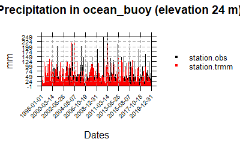

```r
temporalPlot(station.obs,station.trmm, xyplot.custom = list(main = paste("Precipitation in",station.trmm$Metadata$name,"(elevation",precip_trmm$Metadata$altitude[i],"m)"), ylab = "mm"))
```

```r
# temporalPlot(station.obs,station.reanalysis, xyplot.custom = list(main = paste("Precipitation in",station.trmm$Metadata$name,"(elevation",precip_trmm$Metadata$altitude[i],"m)"), ylab = "mm"))
```

```r
index.obs <- valueIndex1D(station.obs$Data[!is.na(station.obs$Data)],index.codes=c("Skewness","SDII","R10","R10p","R20","R20p","P98Wet"))
index.obs <- c(index.obs, valueIndex1D(station.obs$Data[!is.na(station.obs$Data)], index.codes = "P98WetAmount"))
index.obs.rv20max <- MaxReturnValue(station.obs)
```

```
[2021-03-25 18:27:16] Performing annual aggregation...
no non-missing arguments to max; returning -Infno non-missing arguments to max; returning -Inf[2021-03-25 18:27:16] Done.
[2021-03-25 18:27:16] - Computing climatology...
[2021-03-25 18:27:16] - Done.
```

```r
index.trmm <- valueIndex1D(station.trmm$Data,index.codes=c("Skewness","SDII","R10","R10p","R20","R20p","P98Wet","P98WetAmount"))
index.trmm.rv20max <- MaxReturnValue(station.trmm)
```

```
[2021-03-25 18:27:16] Performing annual aggregation...
[2021-03-25 18:27:16] Done.
[2021-03-25 18:27:16] - Computing climatology...
[2021-03-25 18:27:16] - Done.
```

```r
# index.reanalysis <- valueIndex1D(station.reanalysis$Data,index.codes=c("Skewness","SDII","R10","R10p","R20","R20p","P98Wet","P98WetAmount"))
# index.reanalysis.rv20max <- MaxReturnValue(station.reanalysis)
```

```r
index.obs <- c(index.obs, index.obs.rv20max)
index.trmm <- c(index.trmm, index.trmm.rv20max)
# index.reanalysis <- c(index.reanalysis, index.reanalysis.rv20max)
```

```r
df <- data.frame(index.obs,index.trmm)
colnames(df) <- c("Obs", "TRMM")
format(df, digits = 3, scientific = 5)
```

|  | Obs | TRMM |
| --- | --- | --- |
| Skewness | 6.3333 | 5.5016 |
| SDII | 13.9221 | 14.9745 |
| R10 | 0.1647 | 0.1302 |
| R10p | 30831.9000 | 32913.4193 |
| R20 | 0.0921 | 0.0721 |
| R20p | 24561.9000 | 26143.5595 |
| P98Wet | 70.9520 | 88.6818 |
| P98WetAmount | 6418.1000 | 6002.9099 |
| RV20_max | 238.8885 | 206.7782 |

### Assessment conditioned on WT

#### k=5

```r
station.obs.cl1 <- subsetDimension(station.obs, dimension = "time", indices = which(kmModel5$cluster == 1))
station.obs.cl2 <- subsetDimension(station.obs, dimension = "time", indices = which(kmModel5$cluster == 2))
station.obs.cl3 <- subsetDimension(station.obs, dimension = "time", indices = which(kmModel5$cluster == 3))
station.obs.cl4 <- subsetDimension(station.obs, dimension = "time", indices = which(kmModel5$cluster == 4))
station.obs.cl5 <- subsetDimension(station.obs, dimension = "time", indices = which(kmModel5$cluster == 5))
```

```r
station.trmm.cl1 <- subsetDimension(station.trmm, dimension = "time", indices = which(kmModel5$cluster == 1))
station.trmm.cl2 <- subsetDimension(station.trmm, dimension = "time", indices = which(kmModel5$cluster == 2))
station.trmm.cl3 <- subsetDimension(station.trmm, dimension = "time", indices = which(kmModel5$cluster == 3))
station.trmm.cl4 <- subsetDimension(station.trmm, dimension = "time", indices = which(kmModel5$cluster == 4))
station.trmm.cl5 <- subsetDimension(station.trmm, dimension = "time", indices = which(kmModel5$cluster == 5))
```

```r
index.obs.cl1 <- valueIndex1D(station.obs.cl1$Data,index.codes=c("Skewness","SDII","R10","R10p","R20","R20p","P98Wet"))
index.obs.cl1 <- c(index.obs.cl1, valueIndex1D(station.obs.cl1$Data[!is.na(station.obs.cl1$Data)], index.codes = "P98WetAmount"))
index.obs.cl1.rv20max <- MaxReturnValue(station.obs.cl1)
```

```
[2021-03-25 18:27:17] Performing annual aggregation...
no non-missing arguments to max; returning -Infno non-missing arguments to max; returning -Inf[2021-03-25 18:27:17] Done.
[2021-03-25 18:27:17] - Computing climatology...
[2021-03-25 18:27:17] - Done.
```

```r
index.trmm.cl1 <- valueIndex1D(station.trmm.cl1$Data,index.codes=c("Skewness","SDII","R10","R10p","R20","R20p","P98Wet"))
index.trmm.cl1 <- c(index.trmm.cl1, valueIndex1D(station.trmm.cl1$Data[!is.na(station.trmm.cl1$Data)], index.codes = "P98WetAmount"))
index.trmm.cl1.rv20max <- MaxReturnValue(station.trmm.cl1)
```

```
[2021-03-25 18:27:17] Performing annual aggregation...
[2021-03-25 18:27:17] Done.
[2021-03-25 18:27:17] - Computing climatology...
[2021-03-25 18:27:17] - Done.
```

```r
index.obs.cl1 <- c(index.obs.cl1, index.obs.cl1.rv20max)
index.trmm.cl1 <- c(index.trmm.cl1, index.trmm.cl1.rv20max)
```

##### Index assessment conditioned on WT1

```r
df <- data.frame(index.obs.cl1,index.trmm.cl1)
colnames(df) <- c("Obs", "TRMM")
format(df, digits = 3, scientific = 5)
```

|  | Obs | TRMM |
| --- | --- | --- |
| Skewness | 6.7280 | 7.3892 |
| SDII | 12.6840 | 13.7390 |
| R10 | 0.0923 | 0.0794 |
| R10p | 5796.9000 | 5314.3799 |
| R20 | 0.0556 | 0.0427 |
| R20p | 4801.6000 | 4239.0000 |
| P98Wet | 63.1120 | 94.0650 |
| P98WetAmount | 1421.4000 | 1182.2100 |
| RV20_max | 171.1515 | 174.6812 |

```r
index.obs.cl2 <- valueIndex1D(station.obs.cl2$Data,index.codes=c("Skewness","SDII","R10","R10p","R20","R20p","P98Wet"))
index.obs.cl2 <- c(index.obs.cl2, valueIndex1D(station.obs.cl2$Data[!is.na(station.obs.cl2$Data)], index.codes = "P98WetAmount"))
index.obs.cl2.rv20max <- MaxReturnValue(station.obs.cl2)
```

```
[2021-03-25 18:27:18] Performing annual aggregation...
no non-missing arguments to max; returning -Infno non-missing arguments to max; returning -Infno non-missing arguments to max; returning -Inf[2021-03-25 18:27:18] Done.
[2021-03-25 18:27:18] - Computing climatology...
[2021-03-25 18:27:18] - Done.
```

```r
index.trmm.cl2 <- valueIndex1D(station.trmm.cl2$Data,index.codes=c("Skewness","SDII","R10","R10p","R20","R20p","P98Wet"))
index.trmm.cl2 <- c(index.trmm.cl2, valueIndex1D(station.trmm.cl2$Data[!is.na(station.trmm.cl2$Data)], index.codes = "P98WetAmount"))
index.trmm.cl2.rv20max <- MaxReturnValue(station.trmm.cl2)
```

```
[2021-03-25 18:27:18] Performing annual aggregation...
[2021-03-25 18:27:18] Done.
[2021-03-25 18:27:18] - Computing climatology...
[2021-03-25 18:27:18] - Done.
```

```r
index.obs.cl2 <- c(index.obs.cl2, index.obs.cl2.rv20max)
index.trmm.cl2<- c(index.trmm.cl2, index.trmm.cl2.rv20max)
```

##### Index assessment conditioned on WT2

```r
df <- data.frame(index.obs.cl2,index.trmm.cl2)
colnames(df) <- c("Obs", "TRMM")
format(df, digits = 3, scientific = 5)
```

|  | Obs | TRMM |
| --- | --- | --- |
| Skewness | 5.6283 | 5.319 |
| SDII | 15.2043 | 16.846 |
| R10 | 0.1502 | 0.177 |
| R10p | 5092.9000 | 6395.970 |
| R20 | 0.0871 | 0.103 |
| R20p | 4148.2000 | 5281.260 |
| P98Wet | 95.8160 | 98.359 |
| P98WetAmount | 1122.2000 | 1258.230 |
| RV20_max | 155.6944 | 140.067 |

```r
index.obs.cl3 <- valueIndex1D(station.obs.cl3$Data,index.codes=c("Skewness","SDII","R10","R10p","R20","R20p","P98Wet"))
index.obs.cl3 <- c(index.obs.cl3, valueIndex1D(station.obs.cl3$Data[!is.na(station.obs.cl3$Data)], index.codes = "P98WetAmount"))
index.obs.cl3.rv20max <- MaxReturnValue(station.obs.cl3)
```

```
[2021-03-25 18:27:18] Performing annual aggregation...
no non-missing arguments to max; returning -Infno non-missing arguments to max; returning -Infno non-missing arguments to max; returning -Infno non-missing arguments to max; returning -Inf[2021-03-25 18:27:18] Done.
[2021-03-25 18:27:18] - Computing climatology...
[2021-03-25 18:27:18] - Done.
```

```r
index.trmm.cl3 <- valueIndex1D(station.trmm.cl3$Data,index.codes=c("Skewness","SDII","R10","R10p","R20","R20p","P98Wet"))
index.trmm.cl3 <- c(index.trmm.cl3, valueIndex1D(station.trmm.cl3$Data[!is.na(station.trmm.cl3$Data)], index.codes = "P98WetAmount"))
index.trmm.cl3.rv20max <- MaxReturnValue(station.trmm.cl3)
```

```
[2021-03-25 18:27:18] Performing annual aggregation...
[2021-03-25 18:27:18] Done.
[2021-03-25 18:27:18] - Computing climatology...
[2021-03-25 18:27:18] - Done.
```

```r
index.obs.cl3 <- c(index.obs.cl3, index.obs.cl3.rv20max)
index.trmm.cl3 <- c(index.trmm.cl3, index.trmm.cl3.rv20max)
```

##### Index assessment conditioned on WT3

```r
df <- data.frame(index.obs.cl3,index.trmm.cl3)
colnames(df) <- c("Obs", "TRMM")
format(df, digits = 3, scientific = 5)
```

|  | Obs | TRMM |
| --- | --- | --- |
| Skewness | 7.5618 | 4.2542 |
| SDII | 14.0914 | 15.4449 |
| R10 | 0.1277 | 0.1513 |
| R10p | 7627.6000 | 9100.6498 |
| R20 | 0.0684 | 0.0799 |
| R20p | 5942.3000 | 7022.8498 |
| P98Wet | 66.1440 | 88.3494 |
| P98WetAmount | 1691.8000 | 1440.2100 |
| RV20_max | 132.5168 | 103.5254 |

```r
index.obs.cl4 <- valueIndex1D(station.obs.cl4$Data,index.codes=c("Skewness","SDII","R10","R10p","R20","R20p","P98Wet"))
index.obs.cl4 <- c(index.obs.cl4, valueIndex1D(station.obs.cl4$Data[!is.na(station.obs.cl4$Data)], index.codes = "P98WetAmount"))
index.obs.cl4.rv20max <- MaxReturnValue(station.obs.cl4)
```

```
[2021-03-25 18:27:18] Performing annual aggregation...
no non-missing arguments to max; returning -Infno non-missing arguments to max; returning -Infno non-missing arguments to max; returning -Inf[2021-03-25 18:27:18] Done.
[2021-03-25 18:27:18] - Computing climatology...
[2021-03-25 18:27:18] - Done.
```

```r
index.trmm.cl4 <- valueIndex1D(station.trmm.cl4$Data,index.codes=c("Skewness","SDII","R10","R10p","R20","R20p","P98Wet"))
index.trmm.cl4 <- c(index.trmm.cl4, valueIndex1D(station.trmm.cl4$Data[!is.na(station.trmm.cl4$Data)], index.codes = "P98WetAmount"))
index.trmm.cl4.rv20max <- MaxReturnValue(station.trmm.cl4)
```

```
[2021-03-25 18:27:19] Performing annual aggregation...
[2021-03-25 18:27:19] Done.
[2021-03-25 18:27:19] - Computing climatology...
[2021-03-25 18:27:19] - Done.
```

```r
index.obs.cl4 <- c(index.obs.cl4, index.obs.cl4.rv20max)
index.trmm.cl4 <- c(index.trmm.cl4, index.trmm.cl4.rv20max)
```

##### Index assessment conditioned on WT4

```r
df <- data.frame(index.obs.cl4,index.trmm.cl4)
colnames(df) <- c("Obs", "TRMM")
format(df, digits = 3, scientific = 5)
```

|  | Obs | TRMM |
| --- | --- | --- |
| Skewness | 4.5646 | 3.872 |
| SDII | 15.2025 | 14.861 |
| R10 | 0.1521 | 0.148 |
| R10p | 8247.5000 | 7719.600 |
| R20 | 0.0871 | 0.081 |
| R20p | 6636.3000 | 5930.160 |
| P98Wet | 71.4680 | 73.908 |
| P98WetAmount | 1442.0000 | 1140.510 |
| RV20_max | 126.9794 | 103.277 |

```r
index.obs.cl5 <- valueIndex1D(station.obs.cl5$Data,index.codes=c("Skewness","SDII","R10","R10p","R20","R20p","P98Wet"))
index.obs.cl5 <- c(index.obs.cl5, valueIndex1D(station.obs.cl5$Data[!is.na(station.obs.cl5$Data)], index.codes = "P98WetAmount"))
index.obs.cl5.rv20max <- MaxReturnValue(station.obs.cl5)
```

```
[2021-03-25 18:27:19] Performing annual aggregation...
no non-missing arguments to max; returning -Inf[2021-03-25 18:27:19] Done.
[2021-03-25 18:27:19] - Computing climatology...
[2021-03-25 18:27:19] - Done.
```

```r
index.trmm.cl5 <- valueIndex1D(station.trmm.cl5$Data,index.codes=c("Skewness","SDII","R10","R10p","R20","R20p","P98Wet"))
index.trmm.cl5 <- c(index.trmm.cl5, valueIndex1D(station.trmm.cl5$Data[!is.na(station.trmm.cl5$Data)], index.codes = "P98WetAmount"))
index.trmm.cl5.rv20max <- MaxReturnValue(station.trmm.cl5)
```

```
[2021-03-25 18:27:19] Performing annual aggregation...
[2021-03-25 18:27:19] Done.
[2021-03-25 18:27:19] - Computing climatology...
[2021-03-25 18:27:19] - Done.
```

```r
index.obs.cl5 <- c(index.obs.cl5, index.obs.cl5.rv20max)
index.trmm.cl5 <- c(index.trmm.cl5, index.trmm.cl5.rv20max)
```

##### Index assessment conditioned on WT5

```r
df <- data.frame(index.obs.cl5,index.trmm.cl5)
colnames(df) <- c("Obs", "TRMM")
format(df, digits = 3, scientific = 5)
```

|  | Obs | TRMM |
| --- | --- | --- |
| Skewness | 6.6016 | 6.2231 |
| SDII | 12.1787 | 13.7117 |
| R10 | 0.0930 | 0.0859 |
| R10p | 4067.0000 | 4382.8199 |
| R20 | 0.0462 | 0.0514 |
| R20p | 3033.5000 | 3670.2899 |
| P98Wet | 61.9680 | 91.2672 |
| P98WetAmount | 801.3000 | 956.7300 |
| RV20_max | 137.9143 | 135.7710 |

##### Difference between obs and raw/WT-conditioned data

```r
diff.df <- data.frame(abs(index.trmm-index.obs),abs(index.trmm.cl1-index.obs.cl1),
                      abs(index.trmm.cl2-index.obs.cl2), abs(index.trmm.cl3-index.obs.cl3), abs(index.trmm.cl4-index.obs.cl4), abs(index.trmm.cl5-index.obs.cl5)
                      )
colnames(diff.df) <- c("Raw","WT1", "WT2","WT3", "WT4","WT5")

format(diff.df, digits = 3, scientific = 5)
```

|  | Raw | WT1 | WT2 | WT3 | WT4 | WT5 |
| --- | --- | --- | --- | --- | --- | --- |
| Skewness | 0.8317 | 0.6611 | 0.3097 | 3.3076 | 0.69253 | 0.37854 |
| SDII | 1.0524 | 1.0550 | 1.6413 | 1.3534 | 0.34194 | 1.53301 |
| R10 | 0.0345 | 0.0129 | 0.0268 | 0.0236 | 0.00441 | 0.00716 |
| R10p | 2081.5193 | 482.5201 | 1303.0699 | 1473.0498 | 527.90019 | 315.81989 |
| R20 | 0.0200 | 0.0129 | 0.0163 | 0.0116 | 0.00606 | 0.00520 |
| R20p | 1581.6595 | 562.6000 | 1133.0599 | 1080.5498 | 706.14014 | 636.78991 |
| P98Wet | 17.7298 | 30.9530 | 2.5432 | 22.2054 | 2.44000 | 29.29920 |
| P98WetAmount | 415.1901 | 239.1900 | 136.0300 | 251.5900 | 301.49004 | 155.42996 |
| RV20_max | 32.1102 | 3.5297 | 15.6271 | 28.9914 | 23.70201 | 2.14334 |

#### k = 6

```r
station.obs.cl1 <- subsetDimension(station.obs, dimension = "time", indices = which(kmModel6$cluster == 1))
station.obs.cl2 <- subsetDimension(station.obs, dimension = "time", indices = which(kmModel6$cluster == 2))
station.obs.cl3 <- subsetDimension(station.obs, dimension = "time", indices = which(kmModel6$cluster == 3))
station.obs.cl4 <- subsetDimension(station.obs, dimension = "time", indices = which(kmModel6$cluster == 4))
station.obs.cl5 <- subsetDimension(station.obs, dimension = "time", indices = which(kmModel6$cluster == 5))
station.obs.cl6 <- subsetDimension(station.obs, dimension = "time", indices = which(kmModel6$cluster == 6))
```

```r
station.trmm.cl1 <- subsetDimension(station.trmm, dimension = "time", indices = which(kmModel6$cluster == 1))
station.trmm.cl2 <- subsetDimension(station.trmm, dimension = "time", indices = which(kmModel6$cluster == 2))
station.trmm.cl3 <- subsetDimension(station.trmm, dimension = "time", indices = which(kmModel6$cluster == 3))
station.trmm.cl4 <- subsetDimension(station.trmm, dimension = "time", indices = which(kmModel6$cluster == 4))
station.trmm.cl5 <- subsetDimension(station.trmm, dimension = "time", indices = which(kmModel6$cluster == 5))
station.trmm.cl6 <- subsetDimension(station.trmm, dimension = "time", indices = which(kmModel6$cluster == 6))
```

```r
index.obs.cl1 <- valueIndex1D(station.obs.cl1$Data,index.codes=c("Skewness","SDII","R10","R10p","R20","R20p","P98Wet"))
index.obs.cl1 <- c(index.obs.cl1, valueIndex1D(station.obs.cl1$Data[!is.na(station.obs.cl1$Data)], index.codes = "P98WetAmount"))
index.obs.cl1.rv20max <- MaxReturnValue(station.obs.cl1)
```

```
[2021-03-25 18:27:20] Performing annual aggregation...
no non-missing arguments to max; returning -Infno non-missing arguments to max; returning -Infno non-missing arguments to max; returning -Inf[2021-03-25 18:27:20] Done.
[2021-03-25 18:27:20] - Computing climatology...
[2021-03-25 18:27:20] - Done.
```

```r
index.trmm.cl1 <- valueIndex1D(station.trmm.cl1$Data,index.codes=c("Skewness","SDII","R10","R10p","R20","R20p","P98Wet"))
index.trmm.cl1 <- c(index.trmm.cl1, valueIndex1D(station.trmm.cl1$Data[!is.na(station.trmm.cl1$Data)], index.codes = "P98WetAmount"))
index.trmm.cl1.rv20max <- MaxReturnValue(station.trmm.cl1)
```

```
[2021-03-25 18:27:20] Performing annual aggregation...
[2021-03-25 18:27:20] Done.
[2021-03-25 18:27:20] - Computing climatology...
[2021-03-25 18:27:20] - Done.
```

```r
index.obs.cl1 <- c(index.obs.cl1, index.obs.cl1.rv20max)
index.trmm.cl1 <- c(index.trmm.cl1, index.trmm.cl1.rv20max)
```

##### Index assessment conditioned on WT1

```r
df <- data.frame(index.obs.cl1,index.trmm.cl1)
colnames(df) <- c("Obs", "TRMM")
format(df, digits = 3, scientific = 5)
```

|  | Obs | TRMM |
| --- | --- | --- |
| Skewness | 7.0909 | 4.5782 |
| SDII | 13.9744 | 15.9687 |
| R10 | 0.1210 | 0.1372 |
| R10p | 6194.4000 | 7300.8299 |
| R20 | 0.0657 | 0.0767 |
| R20p | 4806.4000 | 5763.7799 |
| P98Wet | 61.6080 | 88.9050 |
| P98WetAmount | 1273.3000 | 1167.4200 |
| RV20_max | 106.7175 | 127.0161 |

```r
index.obs.cl2 <- valueIndex1D(station.obs.cl2$Data,index.codes=c("Skewness","SDII","R10","R10p","R20","R20p","P98Wet"))
index.obs.cl2 <- c(index.obs.cl2, valueIndex1D(station.obs.cl2$Data[!is.na(station.obs.cl2$Data)], index.codes = "P98WetAmount"))
index.obs.cl2.rv20max <- MaxReturnValue(station.obs.cl2)
```

```
[2021-03-25 18:27:20] Performing annual aggregation...
no non-missing arguments to max; returning -Infno non-missing arguments to max; returning -Infno non-missing arguments to max; returning -Infno non-missing arguments to max; returning -Inf[2021-03-25 18:27:20] Done.
[2021-03-25 18:27:20] - Computing climatology...
[2021-03-25 18:27:20] - Done.
```

```r
index.trmm.cl2 <- valueIndex1D(station.trmm.cl2$Data,index.codes=c("Skewness","SDII","R10","R10p","R20","R20p","P98Wet"))
index.trmm.cl2 <- c(index.trmm.cl2, valueIndex1D(station.trmm.cl2$Data[!is.na(station.trmm.cl2$Data)], index.codes = "P98WetAmount"))
index.trmm.cl2.rv20max <- MaxReturnValue(station.trmm.cl2)
```

```
[2021-03-25 18:27:21] Performing annual aggregation...
[2021-03-25 18:27:21] Done.
[2021-03-25 18:27:21] - Computing climatology...
[2021-03-25 18:27:21] - Done.
```

```r
index.obs.cl2 <- c(index.obs.cl2, index.obs.cl2.rv20max)
index.trmm.cl2<- c(index.trmm.cl2, index.trmm.cl2.rv20max)
```

##### Index assessment conditioned on WT2

```r
df <- data.frame(index.obs.cl2,index.trmm.cl2)
colnames(df) <- c("Obs", "TRMM")
format(df, digits = 3, scientific = 5)
```

|  | Obs | TRMM |
| --- | --- | --- |
| Skewness | 7.136 | 5.3026 |
| SDII | 14.057 | 14.8473 |
| R10 | 0.133 | 0.1621 |
| R10p | 5053.100 | 6049.8899 |
| R20 | 0.076 | 0.0835 |
| R20p | 4096.300 | 4686.9299 |
| P98Wet | 79.152 | 88.4436 |
| P98WetAmount | 1317.100 | 1186.0200 |
| RV20_max | 207.545 | 114.8184 |

```r
index.obs.cl3 <- valueIndex1D(station.obs.cl3$Data,index.codes=c("Skewness","SDII","R10","R10p","R20","R20p","P98Wet"))
index.obs.cl3 <- c(index.obs.cl3, valueIndex1D(station.obs.cl3$Data[!is.na(station.obs.cl3$Data)], index.codes = "P98WetAmount"))
index.obs.cl3.rv20max <- MaxReturnValue(station.obs.cl3)
```

```
[2021-03-25 18:27:21] Performing annual aggregation...
no non-missing arguments to max; returning -Inf[2021-03-25 18:27:21] Done.
[2021-03-25 18:27:21] - Computing climatology...
[2021-03-25 18:27:21] - Done.
```

```r
index.trmm.cl3 <- valueIndex1D(station.trmm.cl3$Data,index.codes=c("Skewness","SDII","R10","R10p","R20","R20p","P98Wet"))
index.trmm.cl3 <- c(index.trmm.cl3, valueIndex1D(station.trmm.cl3$Data[!is.na(station.trmm.cl3$Data)], index.codes = "P98WetAmount"))
index.trmm.cl3.rv20max <- MaxReturnValue(station.trmm.cl3)
```

```
[2021-03-25 18:27:21] Performing annual aggregation...
[2021-03-25 18:27:21] Done.
[2021-03-25 18:27:21] - Computing climatology...
[2021-03-25 18:27:21] - Done.
```

```r
index.obs.cl3 <- c(index.obs.cl3, index.obs.cl3.rv20max)
index.trmm.cl3 <- c(index.trmm.cl3, index.trmm.cl3.rv20max)
```

##### Index assessment conditioned on WT3

```r
df <- data.frame(index.obs.cl3,index.trmm.cl3)
colnames(df) <- c("Obs", "TRMM")
format(df, digits = 3, scientific = 5)
```

|  | Obs | TRMM |
| --- | --- | --- |
| Skewness | 7.3620 | 6.8611 |
| SDII | 12.0121 | 12.1137 |
| R10 | 0.0844 | 0.0744 |
| R10p | 2910.3000 | 2806.2299 |
| R20 | 0.0409 | 0.0409 |
| R20p | 2159.0000 | 2276.0699 |
| P98Wet | 65.0880 | 82.9476 |
| P98WetAmount | 624.7000 | 773.0700 |
| RV20_max | 125.0456 | 144.4109 |

```r
index.obs.cl4 <- valueIndex1D(station.obs.cl4$Data,index.codes=c("Skewness","SDII","R10","R10p","R20","R20p","P98Wet"))
index.obs.cl4 <- c(index.obs.cl4, valueIndex1D(station.obs.cl4$Data[!is.na(station.obs.cl4$Data)], index.codes = "P98WetAmount"))
index.obs.cl4.rv20max <- MaxReturnValue(station.obs.cl4)
```

```
[2021-03-25 18:27:21] Performing annual aggregation...
no non-missing arguments to max; returning -Inf[2021-03-25 18:27:21] Done.
[2021-03-25 18:27:21] - Computing climatology...
[2021-03-25 18:27:21] - Done.
```

```r
index.trmm.cl4 <- valueIndex1D(station.trmm.cl4$Data,index.codes=c("Skewness","SDII","R10","R10p","R20","R20p","P98Wet"))
index.trmm.cl4 <- c(index.trmm.cl4, valueIndex1D(station.trmm.cl4$Data[!is.na(station.trmm.cl4$Data)], index.codes = "P98WetAmount"))
index.trmm.cl4.rv20max <- MaxReturnValue(station.trmm.cl4)
```

```
[2021-03-25 18:27:21] Performing annual aggregation...
[2021-03-25 18:27:21] Done.
[2021-03-25 18:27:21] - Computing climatology...
[2021-03-25 18:27:21] - Done.
```

```r
index.obs.cl4 <- c(index.obs.cl4, index.obs.cl4.rv20max)
index.trmm.cl4 <- c(index.trmm.cl4, index.trmm.cl4.rv20max)
```

##### Index assessment conditioned on WT4

```r
df <- data.frame(index.obs.cl4,index.trmm.cl4)
colnames(df) <- c("Obs", "TRMM")
format(df, digits = 3, scientific = 5)
```

|  | Obs | TRMM |
| --- | --- | --- |
| Skewness | 6.7843 | 7.4939 |
| SDII | 12.9421 | 14.0870 |
| R10 | 0.0938 | 0.0783 |
| R10p | 5143.6000 | 4619.9699 |
| R20 | 0.0570 | 0.0420 |
| R20p | 4286.2000 | 3696.5399 |
| P98Wet | 61.5760 | 95.9700 |
| P98WetAmount | 1314.4000 | 1084.8300 |
| RV20_max | 229.0247 | 163.7781 |

```r
index.obs.cl5 <- valueIndex1D(station.obs.cl5$Data,index.codes=c("Skewness","SDII","R10","R10p","R20","R20p","P98Wet"))
index.obs.cl5 <- c(index.obs.cl5, valueIndex1D(station.obs.cl5$Data[!is.na(station.obs.cl5$Data)], index.codes = "P98WetAmount"))
index.obs.cl5.rv20max <- MaxReturnValue(station.obs.cl5)
```

```
[2021-03-25 18:27:22] Performing annual aggregation...
no non-missing arguments to max; returning -Infno non-missing arguments to max; returning -Infno non-missing arguments to max; returning -Inf[2021-03-25 18:27:22] Done.
[2021-03-25 18:27:22] - Computing climatology...
[2021-03-25 18:27:22] - Done.
```

```r
index.trmm.cl5 <- valueIndex1D(station.trmm.cl5$Data,index.codes=c("Skewness","SDII","R10","R10p","R20","R20p","P98Wet"))
index.trmm.cl5 <- c(index.trmm.cl5, valueIndex1D(station.trmm.cl5$Data[!is.na(station.trmm.cl5$Data)], index.codes = "P98WetAmount"))
index.trmm.cl5.rv20max <- MaxReturnValue(station.trmm.cl5)
```

```
[2021-03-25 18:27:22] Performing annual aggregation...
[2021-03-25 18:27:22] Done.
[2021-03-25 18:27:22] - Computing climatology...
[2021-03-25 18:27:22] - Done.
```

```r
index.obs.cl5 <- c(index.obs.cl5, index.obs.cl5.rv20max)
index.trmm.cl5 <- c(index.trmm.cl5, index.trmm.cl5.rv20max)
```

##### Index assessment conditioned on WT5

```r
df <- data.frame(index.obs.cl5,index.trmm.cl5)
colnames(df) <- c("Obs", "TRMM")
format(df, digits = 3, scientific = 5)
```

|  | Obs | TRMM |
| --- | --- | --- |
| Skewness | 4.5486 | 3.9534 |
| SDII | 15.0200 | 14.9969 |
| R10 | 0.1534 | 0.1422 |
| R10p | 8018.8000 | 7481.3698 |
| R20 | 0.0864 | 0.0786 |
| R20p | 6385.3000 | 5794.4699 |
| P98Wet | 70.8880 | 74.6118 |
| P98WetAmount | 1375.2000 | 1079.6700 |
| RV20_max | 116.7624 | 104.8275 |

```r
index.obs.cl6 <- valueIndex1D(station.obs.cl6$Data,index.codes=c("Skewness","SDII","R10","R10p","R20","R20p","P98Wet"))
index.obs.cl6 <- c(index.obs.cl6, valueIndex1D(station.obs.cl6$Data[!is.na(station.obs.cl6$Data)], index.codes = "P98WetAmount"))
index.obs.cl6.rv20max <- MaxReturnValue(station.obs.cl6)
```

```
[2021-03-25 18:27:22] Performing annual aggregation...
no non-missing arguments to max; returning -Infno non-missing arguments to max; returning -Infno non-missing arguments to max; returning -Inf[2021-03-25 18:27:22] Done.
[2021-03-25 18:27:22] - Computing climatology...
[2021-03-25 18:27:22] - Done.
```

```r
index.trmm.cl6 <- valueIndex1D(station.trmm.cl6$Data,index.codes=c("Skewness","SDII","R10","R10p","R20","R20p","P98Wet"))
index.trmm.cl6 <- c(index.trmm.cl6, valueIndex1D(station.trmm.cl6$Data[!is.na(station.trmm.cl6$Data)], index.codes = "P98WetAmount"))
index.trmm.cl6.rv20max <- MaxReturnValue(station.trmm.cl6)
```

```
[2021-03-25 18:27:22] Performing annual aggregation...
[2021-03-25 18:27:22] Done.
[2021-03-25 18:27:22] - Computing climatology...
[2021-03-25 18:27:22] - Done.
```

```r
index.obs.cl6 <- c(index.obs.cl6, index.obs.cl6.rv20max)
index.trmm.cl6 <- c(index.trmm.cl6, index.trmm.cl6.rv20max)
```

##### Index assessment conditioned on WT6

```r
df <- data.frame(index.obs.cl6,index.trmm.cl6)
colnames(df) <- c("Obs", "TRMM")
format(df, digits = 3, scientific = 5)
```

|  | Obs | TRMM |
| --- | --- | --- |
| Skewness | 4.599 | 4.877 |
| SDII | 14.979 | 17.342 |
| R10 | 0.146 | 0.181 |
| R10p | 3511.700 | 4655.130 |
| R20 | 0.081 | 0.112 |
| R20p | 2828.700 | 3925.770 |
| P98Wet | 95.400 | 95.911 |
| P98WetAmount | 831.600 | 900.240 |
| RV20_max | 126.093 | 144.783 |

##### Difference between obs and raw/WT-conditioned data

```r
diff.df <- data.frame(abs(index.trmm-index.obs),abs(index.trmm.cl1-index.obs.cl1),
                      abs(index.trmm.cl2-index.obs.cl2), abs(index.trmm.cl3-index.obs.cl3), abs(index.trmm.cl4-index.obs.cl4), abs(index.trmm.cl5-index.obs.cl5),abs(index.trmm.cl6-index.obs.cl6)
                      )
colnames(diff.df) <- c("Raw","WT1", "WT2","WT3", "WT4","WT5","WT6")

format(diff.df, digits = 3, scientific = 5)
```

|  | Raw | WT1 | WT2 | WT3 | WT4 | WT5 | WT6 |
| --- | --- | --- | --- | --- | --- | --- | --- |
| Skewness | 0.8317 | 2.5128 | 1.83349 | 0.501 | 0.7096 | 0.59518 | 0.2778 |
| SDII | 1.0524 | 1.9944 | 0.79063 | 0.102 | 1.1449 | 0.02317 | 2.3635 |
| R10 | 0.0345 | 0.0161 | 0.02924 | 0.010 | 0.0155 | 0.01115 | 0.0351 |
| R10p | 2081.5193 | 1106.4299 | 996.78986 | 104.070 | 523.6301 | 537.43017 | 1143.4299 |
| R20 | 0.0200 | 0.0110 | 0.00752 | 0.000 | 0.0150 | 0.00781 | 0.0310 |
| R20p | 1581.6595 | 957.3799 | 590.62990 | 117.070 | 589.6601 | 590.83013 | 1097.0699 |
| P98Wet | 17.7298 | 27.2970 | 9.29160 | 17.860 | 34.3940 | 3.72380 | 0.5106 |
| P98WetAmount | 415.1901 | 105.8800 | 131.08002 | 148.370 | 229.5700 | 295.53003 | 68.6400 |
| RV20_max | 32.1102 | 20.2986 | 92.72627 | 19.365 | 65.2466 | 11.93488 | 18.6905 |

## Aoloau (American Samoa) station

### Raw not conditioned data

```r
i=6

station.trmm <- subsetGrid(precip_trmm, station.id = precip_trmm$Metadata$station_id[i])
station.obs <- subsetGrid(precip_obs, station.id = precip_trmm$Metadata$station_id[i])
```

```r
# idx <- which.min(abs(pp_reanalysis$xyCoords$x - station.obs$xyCoords$x))
#
# lon <- pp_reanalysis$xyCoords$x[idx]
#
# idx2 <- which.min(abs(pp_reanalysis$xyCoords$y - station.obs$xyCoords$y))
# lat <- pp_reanalysis$xyCoords$y[idx2]
#
# station.reanalysis <- subsetGrid(pp_reanalysis, lonLim = lon, latLim = lat)
```

```
pad applied on the interval: day
pad applied on the interval: day
```

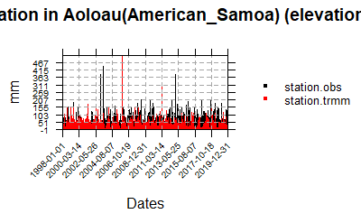

```r
temporalPlot(station.obs,station.trmm, xyplot.custom = list(main = paste("Precipitation in",station.trmm$Metadata$name,"(elevation",precip_trmm$Metadata$altitude[i],"m)"), ylab = "mm"))
```

```r
# temporalPlot(station.obs,station.reanalysis, xyplot.custom = list(main = paste("Precipitation in",station.trmm$Metadata$name,"(elevation",precip_trmm$Metadata$altitude[i],"m)"), ylab = "mm"))
```

```r
index.obs <- valueIndex1D(station.obs$Data[!is.na(station.obs$Data)],index.codes=c("Skewness","SDII","R10","R10p","R20","R20p","P98Wet"))
index.obs <- c(index.obs, valueIndex1D(station.obs$Data[!is.na(station.obs$Data)], index.codes = "P98WetAmount"))
index.obs.rv20max <- MaxReturnValue(station.obs)
```

```
[2021-03-25 18:27:25] Performing annual aggregation...
[2021-03-25 18:27:25] Done.
[2021-03-25 18:27:25] - Computing climatology...
[2021-03-25 18:27:25] - Done.
```

```r
index.trmm <- valueIndex1D(station.trmm$Data,index.codes=c("Skewness","SDII","R10","R10p","R20","R20p","P98Wet","P98WetAmount"))
index.trmm.rv20max <- MaxReturnValue(station.trmm)
```

```
[2021-03-25 18:27:25] Performing annual aggregation...
[2021-03-25 18:27:25] Done.
[2021-03-25 18:27:25] - Computing climatology...
[2021-03-25 18:27:25] - Done.
```

```r
# index.reanalysis <- valueIndex1D(station.reanalysis$Data,index.codes=c("Skewness","SDII","R10","R10p","R20","R20p","P98Wet","P98WetAmount"))
# index.reanalysis.rv20max <- MaxReturnValue(station.reanalysis)
```

```r
index.obs <- c(index.obs, index.obs.rv20max)
index.trmm <- c(index.trmm, index.trmm.rv20max)
# index.reanalysis <- c(index.reanalysis, index.reanalysis.rv20max)
```

```r
df <- data.frame(index.obs,index.trmm)
colnames(df) <- c("Obs", "TRMM")
format(df, digits = 3, scientific = 5)
```

|  | Obs | TRMM |
| --- | --- | --- |
| Skewness | 4.527 | 7.472 |
| SDII | 20.884 | 15.331 |
| R10 | 0.414 | 0.190 |
| R10p | 91186.600 | 47130.839 |
| R20 | 0.237 | 0.107 |
| R20p | 75271.500 | 37714.139 |
| P98Wet | 112.220 | 79.505 |
| P98WetAmount | 15144.500 | 8392.350 |
| RV20_max | 371.064 | 340.518 |

### Assessment conditioned on WT

#### k=5

```r
station.obs.cl1 <- subsetDimension(station.obs, dimension = "time", indices = which(kmModel5$cluster == 1))
station.obs.cl2 <- subsetDimension(station.obs, dimension = "time", indices = which(kmModel5$cluster == 2))
station.obs.cl3 <- subsetDimension(station.obs, dimension = "time", indices = which(kmModel5$cluster == 3))
station.obs.cl4 <- subsetDimension(station.obs, dimension = "time", indices = which(kmModel5$cluster == 4))
station.obs.cl5 <- subsetDimension(station.obs, dimension = "time", indices = which(kmModel5$cluster == 5))
```

```r
station.trmm.cl1 <- subsetDimension(station.trmm, dimension = "time", indices = which(kmModel5$cluster == 1))
station.trmm.cl2 <- subsetDimension(station.trmm, dimension = "time", indices = which(kmModel5$cluster == 2))
station.trmm.cl3 <- subsetDimension(station.trmm, dimension = "time", indices = which(kmModel5$cluster == 3))
station.trmm.cl4 <- subsetDimension(station.trmm, dimension = "time", indices = which(kmModel5$cluster == 4))
station.trmm.cl5 <- subsetDimension(station.trmm, dimension = "time", indices = which(kmModel5$cluster == 5))
```

```r
index.obs.cl1 <- valueIndex1D(station.obs.cl1$Data,index.codes=c("Skewness","SDII","R10","R10p","R20","R20p","P98Wet"))
index.obs.cl1 <- c(index.obs.cl1, valueIndex1D(station.obs.cl1$Data[!is.na(station.obs.cl1$Data)], index.codes = "P98WetAmount"))
index.obs.cl1.rv20max <- MaxReturnValue(station.obs.cl1)
```

```
[2021-03-25 18:27:26] Performing annual aggregation...
no non-missing arguments to max; returning -Inf[2021-03-25 18:27:26] Done.
[2021-03-25 18:27:26] - Computing climatology...
[2021-03-25 18:27:26] - Done.
```

```r
index.trmm.cl1 <- valueIndex1D(station.trmm.cl1$Data,index.codes=c("Skewness","SDII","R10","R10p","R20","R20p","P98Wet"))
index.trmm.cl1 <- c(index.trmm.cl1, valueIndex1D(station.trmm.cl1$Data[!is.na(station.trmm.cl1$Data)], index.codes = "P98WetAmount"))
index.trmm.cl1.rv20max <- MaxReturnValue(station.trmm.cl1)
```

```
[2021-03-25 18:27:26] Performing annual aggregation...
[2021-03-25 18:27:26] Done.
[2021-03-25 18:27:26] - Computing climatology...
[2021-03-25 18:27:26] - Done.
```

```r
index.obs.cl1 <- c(index.obs.cl1, index.obs.cl1.rv20max)
index.trmm.cl1 <- c(index.trmm.cl1, index.trmm.cl1.rv20max)
```

##### Index assessment conditioned on WT1

```r
df <- data.frame(index.obs.cl1,index.trmm.cl1)
colnames(df) <- c("Obs", "TRMM")
format(df, digits = 3, scientific = 5)
```

|  | Obs | TRMM |
| --- | --- | --- |
| Skewness | 3.427 | 5.1111 |
| SDII | 19.798 | 13.6602 |
| R10 | 0.294 | 0.1370 |
| R10p | 20558.400 | 8286.5997 |
| R20 | 0.167 | 0.0739 |
| R20p | 16862.400 | 6482.1898 |
| P98Wet | 102.240 | 70.4010 |
| P98WetAmount | 3462.700 | 1540.9199 |
| RV20_max | 195.025 | 160.3155 |

```r
index.obs.cl2 <- valueIndex1D(station.obs.cl2$Data,index.codes=c("Skewness","SDII","R10","R10p","R20","R20p","P98Wet"))
index.obs.cl2 <- c(index.obs.cl2, valueIndex1D(station.obs.cl2$Data[!is.na(station.obs.cl2$Data)], index.codes = "P98WetAmount"))
index.obs.cl2.rv20max <- MaxReturnValue(station.obs.cl2)
```

```
[2021-03-25 18:27:26] Performing annual aggregation...
no non-missing arguments to max; returning -Infno non-missing arguments to max; returning -Infno non-missing arguments to max; returning -Inf[2021-03-25 18:27:26] Done.
[2021-03-25 18:27:26] - Computing climatology...
[2021-03-25 18:27:26] - Done.
```

```r
index.trmm.cl2 <- valueIndex1D(station.trmm.cl2$Data,index.codes=c("Skewness","SDII","R10","R10p","R20","R20p","P98Wet"))
index.trmm.cl2 <- c(index.trmm.cl2, valueIndex1D(station.trmm.cl2$Data[!is.na(station.trmm.cl2$Data)], index.codes = "P98WetAmount"))
index.trmm.cl2.rv20max <- MaxReturnValue(station.trmm.cl2)
```

```
[2021-03-25 18:27:26] Performing annual aggregation...
[2021-03-25 18:27:26] Done.
[2021-03-25 18:27:26] - Computing climatology...
[2021-03-25 18:27:26] - Done.
```

```r
index.obs.cl2 <- c(index.obs.cl2, index.obs.cl2.rv20max)
index.trmm.cl2<- c(index.trmm.cl2, index.trmm.cl2.rv20max)
```

##### Index assessment conditioned on WT2

```r
df <- data.frame(index.obs.cl2,index.trmm.cl2)
colnames(df) <- c("Obs", "TRMM")
format(df, digits = 3, scientific = 5)
```

|  | Obs | TRMM |
| --- | --- | --- |
| Skewness | 5.049 | 3.979 |
| SDII | 25.574 | 15.232 |
| R10 | 0.389 | 0.222 |
| R10p | 15602.200 | 7096.380 |
| R20 | 0.225 | 0.129 |
| R20p | 13102.200 | 5681.940 |
| P98Wet | 123.190 | 78.601 |
| P98WetAmount | 2652.400 | 1213.380 |
| RV20_max | 335.909 | 128.064 |

```r
index.obs.cl3 <- valueIndex1D(station.obs.cl3$Data,index.codes=c("Skewness","SDII","R10","R10p","R20","R20p","P98Wet"))
index.obs.cl3 <- c(index.obs.cl3, valueIndex1D(station.obs.cl3$Data[!is.na(station.obs.cl3$Data)], index.codes = "P98WetAmount"))
index.obs.cl3.rv20max <- MaxReturnValue(station.obs.cl3)
```

```
[2021-03-25 18:27:27] Performing annual aggregation...
no non-missing arguments to max; returning -Inf[2021-03-25 18:27:27] Done.
[2021-03-25 18:27:27] - Computing climatology...
[2021-03-25 18:27:27] - Done.
```

```r
index.trmm.cl3 <- valueIndex1D(station.trmm.cl3$Data,index.codes=c("Skewness","SDII","R10","R10p","R20","R20p","P98Wet"))
index.trmm.cl3 <- c(index.trmm.cl3, valueIndex1D(station.trmm.cl3$Data[!is.na(station.trmm.cl3$Data)], index.codes = "P98WetAmount"))
index.trmm.cl3.rv20max <- MaxReturnValue(station.trmm.cl3)
```

```
[2021-03-25 18:27:27] Performing annual aggregation...
[2021-03-25 18:27:27] Done.
[2021-03-25 18:27:27] - Computing climatology...
[2021-03-25 18:27:27] - Done.
```

```r
index.obs.cl3 <- c(index.obs.cl3, index.obs.cl3.rv20max)
index.trmm.cl3 <- c(index.trmm.cl3, index.trmm.cl3.rv20max)
```

##### Index assessment conditioned on WT3

```r
df <- data.frame(index.obs.cl3,index.trmm.cl3)
colnames(df) <- c("Obs", "TRMM")
format(df, digits = 3, scientific = 5)
```

|  | Obs | TRMM |
| --- | --- | --- |
| Skewness | 4.267 | 3.866 |
| SDII | 20.736 | 16.051 |
| R10 | 0.310 | 0.205 |
| R10p | 21323.500 | 12586.620 |
| R20 | 0.176 | 0.116 |
| R20p | 17484.800 | 10141.050 |
| P98Wet | 115.908 | 85.569 |
| P98WetAmount | 3489.400 | 2039.610 |
| RV20_max | 157.565 | 135.605 |

```r
index.obs.cl4 <- valueIndex1D(station.obs.cl4$Data,index.codes=c("Skewness","SDII","R10","R10p","R20","R20p","P98Wet"))
index.obs.cl4 <- c(index.obs.cl4, valueIndex1D(station.obs.cl4$Data[!is.na(station.obs.cl4$Data)], index.codes = "P98WetAmount"))
index.obs.cl4.rv20max <- MaxReturnValue(station.obs.cl4)
```

```
[2021-03-25 18:27:27] Performing annual aggregation...
no non-missing arguments to max; returning -Inf[2021-03-25 18:27:27] Done.
[2021-03-25 18:27:27] - Computing climatology...
[2021-03-25 18:27:27] - Done.
```

```r
index.trmm.cl4 <- valueIndex1D(station.trmm.cl4$Data,index.codes=c("Skewness","SDII","R10","R10p","R20","R20p","P98Wet"))
index.trmm.cl4 <- c(index.trmm.cl4, valueIndex1D(station.trmm.cl4$Data[!is.na(station.trmm.cl4$Data)], index.codes = "P98WetAmount"))
index.trmm.cl4.rv20max <- MaxReturnValue(station.trmm.cl4)
```

```
[2021-03-25 18:27:27] Performing annual aggregation...
[2021-03-25 18:27:27] Done.
[2021-03-25 18:27:27] - Computing climatology...
[2021-03-25 18:27:27] - Done.
```

```r
index.obs.cl4 <- c(index.obs.cl4, index.obs.cl4.rv20max)
index.trmm.cl4 <- c(index.trmm.cl4, index.trmm.cl4.rv20max)
```

##### Index assessment conditioned on WT4

```r
df <- data.frame(index.obs.cl4,index.trmm.cl4)
colnames(df) <- c("Obs", "TRMM")
format(df, digits = 3, scientific = 5)
```

|  | Obs | TRMM |
| --- | --- | --- |
| Skewness | 3.040 | 9.632 |
| SDII | 19.675 | 17.620 |
| R10 | 0.304 | 0.215 |
| R10p | 18175.800 | 13460.100 |
| R20 | 0.168 | 0.133 |
| R20p | 14705.500 | 11339.910 |
| P98Wet | 111.910 | 88.476 |
| P98WetAmount | 2868.600 | 2702.430 |
| RV20_max | 153.123 | 277.075 |

```r
index.obs.cl5 <- valueIndex1D(station.obs.cl5$Data,index.codes=c("Skewness","SDII","R10","R10p","R20","R20p","P98Wet"))
index.obs.cl5 <- c(index.obs.cl5, valueIndex1D(station.obs.cl5$Data[!is.na(station.obs.cl5$Data)], index.codes = "P98WetAmount"))
index.obs.cl5.rv20max <- MaxReturnValue(station.obs.cl5)
```

```
[2021-03-25 18:27:27] Performing annual aggregation...
[2021-03-25 18:27:27] Done.
[2021-03-25 18:27:27] - Computing climatology...
[2021-03-25 18:27:27] - Done.
```

```r
index.trmm.cl5 <- valueIndex1D(station.trmm.cl5$Data,index.codes=c("Skewness","SDII","R10","R10p","R20","R20p","P98Wet"))
index.trmm.cl5 <- c(index.trmm.cl5, valueIndex1D(station.trmm.cl5$Data[!is.na(station.trmm.cl5$Data)], index.codes = "P98WetAmount"))
index.trmm.cl5.rv20max <- MaxReturnValue(station.trmm.cl5)
```

```
[2021-03-25 18:27:27] Performing annual aggregation...
[2021-03-25 18:27:27] Done.
[2021-03-25 18:27:27] - Computing climatology...
[2021-03-25 18:27:27] - Done.
```

```r
index.obs.cl5 <- c(index.obs.cl5, index.obs.cl5.rv20max)
index.trmm.cl5 <- c(index.trmm.cl5, index.trmm.cl5.rv20max)
```

##### Index assessment conditioned on WT5

```r
df <- data.frame(index.obs.cl5,index.trmm.cl5)
colnames(df) <- c("Obs", "TRMM")
format(df, digits = 3, scientific = 5)
```

|  | Obs | TRMM |
| --- | --- | --- |
| Skewness | 5.700 | 4.2227 |
| SDII | 20.422 | 12.8963 |
| R10 | 0.284 | 0.1405 |
| R10p | 15526.700 | 5701.1399 |
| R20 | 0.172 | 0.0657 |
| R20p | 13116.600 | 4069.0499 |
| P98Wet | 104.448 | 62.7282 |
| P98WetAmount | 2727.700 | 996.7800 |
| RV20_max | 242.281 | 103.7770 |

##### Difference between obs and raw/WT-conditioned data

```r
diff.df <- data.frame(abs(index.trmm-index.obs),abs(index.trmm.cl1-index.obs.cl1),
                      abs(index.trmm.cl2-index.obs.cl2), abs(index.trmm.cl3-index.obs.cl3), abs(index.trmm.cl4-index.obs.cl4), abs(index.trmm.cl5-index.obs.cl5)
                      )
colnames(diff.df) <- c("Raw","WT1", "WT2","WT3", "WT4","WT5")

format(diff.df, digits = 3, scientific = 5)
```

|  | Raw | WT1 | WT2 | WT3 | WT4 | WT5 |
| --- | --- | --- | --- | --- | --- | --- |
| Skewness | 2.945 | 1.6841 | 1.0700 | 0.4006 | 6.5925 | 1.477 |
| SDII | 5.552 | 6.1378 | 10.3420 | 4.6857 | 2.0552 | 7.525 |
| R10 | 0.225 | 0.1573 | 0.1675 | 0.1051 | 0.0887 | 0.143 |
| R10p | 44055.761 | 12271.8003 | 8505.8202 | 8736.8803 | 4715.7003 | 9825.560 |
| R20 | 0.130 | 0.0928 | 0.0957 | 0.0603 | 0.0347 | 0.107 |
| R20p | 37557.361 | 10380.2102 | 7420.2601 | 7343.7502 | 3365.5903 | 9047.550 |
| P98Wet | 32.715 | 31.8390 | 44.5888 | 30.3390 | 23.4340 | 41.720 |
| P98WetAmount | 6752.150 | 1921.7801 | 1439.0200 | 1449.7900 | 166.1700 | 1730.920 |
| RV20_max | 30.546 | 34.7093 | 207.8447 | 21.9593 | 123.9519 | 138.504 |

#### k = 6

```r
station.obs.cl1 <- subsetDimension(station.obs, dimension = "time", indices = which(kmModel6$cluster == 1))
station.obs.cl2 <- subsetDimension(station.obs, dimension = "time", indices = which(kmModel6$cluster == 2))
station.obs.cl3 <- subsetDimension(station.obs, dimension = "time", indices = which(kmModel6$cluster == 3))
station.obs.cl4 <- subsetDimension(station.obs, dimension = "time", indices = which(kmModel6$cluster == 4))
station.obs.cl5 <- subsetDimension(station.obs, dimension = "time", indices = which(kmModel6$cluster == 5))
station.obs.cl6 <- subsetDimension(station.obs, dimension = "time", indices = which(kmModel6$cluster == 6))
```

```r
station.trmm.cl1 <- subsetDimension(station.trmm, dimension = "time", indices = which(kmModel6$cluster == 1))
station.trmm.cl2 <- subsetDimension(station.trmm, dimension = "time", indices = which(kmModel6$cluster == 2))
station.trmm.cl3 <- subsetDimension(station.trmm, dimension = "time", indices = which(kmModel6$cluster == 3))
station.trmm.cl4 <- subsetDimension(station.trmm, dimension = "time", indices = which(kmModel6$cluster == 4))
station.trmm.cl5 <- subsetDimension(station.trmm, dimension = "time", indices = which(kmModel6$cluster == 5))
station.trmm.cl6 <- subsetDimension(station.trmm, dimension = "time", indices = which(kmModel6$cluster == 6))
```

```r
index.obs.cl1 <- valueIndex1D(station.obs.cl1$Data,index.codes=c("Skewness","SDII","R10","R10p","R20","R20p","P98Wet"))
index.obs.cl1 <- c(index.obs.cl1, valueIndex1D(station.obs.cl1$Data[!is.na(station.obs.cl1$Data)], index.codes = "P98WetAmount"))
index.obs.cl1.rv20max <- MaxReturnValue(station.obs.cl1)
```

```
[2021-03-25 18:27:28] Performing annual aggregation...
no non-missing arguments to max; returning -Inf[2021-03-25 18:27:28] Done.
[2021-03-25 18:27:28] - Computing climatology...
[2021-03-25 18:27:28] - Done.
```

```r
index.trmm.cl1 <- valueIndex1D(station.trmm.cl1$Data,index.codes=c("Skewness","SDII","R10","R10p","R20","R20p","P98Wet"))
index.trmm.cl1 <- c(index.trmm.cl1, valueIndex1D(station.trmm.cl1$Data[!is.na(station.trmm.cl1$Data)], index.codes = "P98WetAmount"))
index.trmm.cl1.rv20max <- MaxReturnValue(station.trmm.cl1)
```

```
[2021-03-25 18:27:29] Performing annual aggregation...
[2021-03-25 18:27:29] Done.
[2021-03-25 18:27:29] - Computing climatology...
[2021-03-25 18:27:29] - Done.
```

```r
index.obs.cl1 <- c(index.obs.cl1, index.obs.cl1.rv20max)
index.trmm.cl1 <- c(index.trmm.cl1, index.trmm.cl1.rv20max)
```

##### Index assessment conditioned on WT1

```r
df <- data.frame(index.obs.cl1,index.trmm.cl1)
colnames(df) <- c("Obs", "TRMM")
format(df, digits = 3, scientific = 5)
```

|  | Obs | TRMM |
| --- | --- | --- |
| Skewness | 5.636 | 3.758 |
| SDII | 19.695 | 15.493 |
| R10 | 0.299 | 0.183 |
| R10p | 17256.200 | 9748.920 |
| R20 | 0.170 | 0.100 |
| R20p | 14126.900 | 7734.270 |
| P98Wet | 100.056 | 88.574 |
| P98WetAmount | 2980.400 | 1537.650 |
| RV20_max | 268.897 | 103.585 |

```r
index.obs.cl2 <- valueIndex1D(station.obs.cl2$Data,index.codes=c("Skewness","SDII","R10","R10p","R20","R20p","P98Wet"))
index.obs.cl2 <- c(index.obs.cl2, valueIndex1D(station.obs.cl2$Data[!is.na(station.obs.cl2$Data)], index.codes = "P98WetAmount"))
index.obs.cl2.rv20max <- MaxReturnValue(station.obs.cl2)
```

```
[2021-03-25 18:27:29] Performing annual aggregation...
no non-missing arguments to max; returning -Infno non-missing arguments to max; returning -Inf[2021-03-25 18:27:29] Done.
[2021-03-25 18:27:29] - Computing climatology...
[2021-03-25 18:27:29] - Done.
```

```r
index.trmm.cl2 <- valueIndex1D(station.trmm.cl2$Data,index.codes=c("Skewness","SDII","R10","R10p","R20","R20p","P98Wet"))
index.trmm.cl2 <- c(index.trmm.cl2, valueIndex1D(station.trmm.cl2$Data[!is.na(station.trmm.cl2$Data)], index.codes = "P98WetAmount"))
index.trmm.cl2.rv20max <- MaxReturnValue(station.trmm.cl2)
```

```
[2021-03-25 18:27:29] Performing annual aggregation...
[2021-03-25 18:27:29] Done.
[2021-03-25 18:27:29] - Computing climatology...
[2021-03-25 18:27:29] - Done.
```

```r
index.obs.cl2 <- c(index.obs.cl2, index.obs.cl2.rv20max)
index.trmm.cl2<- c(index.trmm.cl2, index.trmm.cl2.rv20max)
```

##### Index assessment conditioned on WT2

```r
df <- data.frame(index.obs.cl2,index.trmm.cl2)
colnames(df) <- c("Obs", "TRMM")
format(df, digits = 3, scientific = 5)
```

|  | Obs | TRMM |
| --- | --- | --- |
| Skewness | 3.822 | 4.320 |
| SDII | 24.839 | 16.401 |
| R10 | 0.357 | 0.221 |
| R10p | 16447.200 | 8260.050 |
| R20 | 0.211 | 0.129 |
| R20p | 13905.800 | 6753.570 |
| P98Wet | 134.690 | 80.599 |
| P98WetAmount | 2569.300 | 1413.300 |
| RV20_max | 176.204 | 151.726 |

```r
index.obs.cl3 <- valueIndex1D(station.obs.cl3$Data,index.codes=c("Skewness","SDII","R10","R10p","R20","R20p","P98Wet"))
index.obs.cl3 <- c(index.obs.cl3, valueIndex1D(station.obs.cl3$Data[!is.na(station.obs.cl3$Data)], index.codes = "P98WetAmount"))
index.obs.cl3.rv20max <- MaxReturnValue(station.obs.cl3)
```

```
[2021-03-25 18:27:29] Performing annual aggregation...
[2021-03-25 18:27:29] Done.
[2021-03-25 18:27:29] - Computing climatology...
[2021-03-25 18:27:29] - Done.
```

```r
index.trmm.cl3 <- valueIndex1D(station.trmm.cl3$Data,index.codes=c("Skewness","SDII","R10","R10p","R20","R20p","P98Wet"))
index.trmm.cl3 <- c(index.trmm.cl3, valueIndex1D(station.trmm.cl3$Data[!is.na(station.trmm.cl3$Data)], index.codes = "P98WetAmount"))
index.trmm.cl3.rv20max <- MaxReturnValue(station.trmm.cl3)
```

```
[2021-03-25 18:27:29] Performing annual aggregation...
[2021-03-25 18:27:29] Done.
[2021-03-25 18:27:29] - Computing climatology...
[2021-03-25 18:27:29] - Done.
```

```r
index.obs.cl3 <- c(index.obs.cl3, index.obs.cl3.rv20max)
index.trmm.cl3 <- c(index.trmm.cl3, index.trmm.cl3.rv20max)
```

##### Index assessment conditioned on WT3

```r
df <- data.frame(index.obs.cl3,index.trmm.cl3)
colnames(df) <- c("Obs", "TRMM")
format(df, digits = 3, scientific = 5)
```

|  | Obs | TRMM |
| --- | --- | --- |
| Skewness | 3.473 | 3.9409 |
| SDII | 19.656 | 12.3699 |
| R10 | 0.282 | 0.1395 |
| R10p | 11501.800 | 4121.6999 |
| R20 | 0.167 | 0.0593 |
| R20p | 9560.700 | 2751.4199 |
| P98Wet | 100.632 | 61.4046 |
| P98WetAmount | 1894.700 | 665.0400 |
| RV20_max | 204.884 | 90.2751 |

```r
index.obs.cl4 <- valueIndex1D(station.obs.cl4$Data,index.codes=c("Skewness","SDII","R10","R10p","R20","R20p","P98Wet"))
index.obs.cl4 <- c(index.obs.cl4, valueIndex1D(station.obs.cl4$Data[!is.na(station.obs.cl4$Data)], index.codes = "P98WetAmount"))
index.obs.cl4.rv20max <- MaxReturnValue(station.obs.cl4)
```

```
[2021-03-25 18:27:30] Performing annual aggregation...
[2021-03-25 18:27:30] Done.
[2021-03-25 18:27:30] - Computing climatology...
[2021-03-25 18:27:30] - Done.
```

```r
index.trmm.cl4 <- valueIndex1D(station.trmm.cl4$Data,index.codes=c("Skewness","SDII","R10","R10p","R20","R20p","P98Wet"))
index.trmm.cl4 <- c(index.trmm.cl4, valueIndex1D(station.trmm.cl4$Data[!is.na(station.trmm.cl4$Data)], index.codes = "P98WetAmount"))
index.trmm.cl4.rv20max <- MaxReturnValue(station.trmm.cl4)
```

```
[2021-03-25 18:27:30] Performing annual aggregation...
[2021-03-25 18:27:30] Done.
[2021-03-25 18:27:30] - Computing climatology...
[2021-03-25 18:27:30] - Done.
```

```r
index.obs.cl4 <- c(index.obs.cl4, index.obs.cl4.rv20max)
index.trmm.cl4 <- c(index.trmm.cl4, index.trmm.cl4.rv20max)
```

##### Index assessment conditioned on WT4

```r
df <- data.frame(index.obs.cl4,index.trmm.cl4)
colnames(df) <- c("Obs", "TRMM")
format(df, digits = 3, scientific = 5)
```

|  | Obs | TRMM |
| --- | --- | --- |
| Skewness | 3.383 | 5.3041 |
| SDII | 19.854 | 13.3245 |
| R10 | 0.289 | 0.1341 |
| R10p | 17761.600 | 6904.6498 |
| R20 | 0.168 | 0.0725 |
| R20p | 14726.200 | 5397.5698 |
| P98Wet | 104.272 | 60.6264 |
| P98WetAmount | 3042.900 | 1296.1500 |
| RV20_max | 199.274 | 159.7059 |

```r
index.obs.cl5 <- valueIndex1D(station.obs.cl5$Data,index.codes=c("Skewness","SDII","R10","R10p","R20","R20p","P98Wet"))
index.obs.cl5 <- c(index.obs.cl5, valueIndex1D(station.obs.cl5$Data[!is.na(station.obs.cl5$Data)], index.codes = "P98WetAmount"))
index.obs.cl5.rv20max <- MaxReturnValue(station.obs.cl5)
```

```
[2021-03-25 18:27:30] Performing annual aggregation...
no non-missing arguments to max; returning -Infno non-missing arguments to max; returning -Inf[2021-03-25 18:27:30] Done.
[2021-03-25 18:27:30] - Computing climatology...
[2021-03-25 18:27:30] - Done.
```

```r
index.trmm.cl5 <- valueIndex1D(station.trmm.cl5$Data,index.codes=c("Skewness","SDII","R10","R10p","R20","R20p","P98Wet"))
index.trmm.cl5 <- c(index.trmm.cl5, valueIndex1D(station.trmm.cl5$Data[!is.na(station.trmm.cl5$Data)], index.codes = "P98WetAmount"))
index.trmm.cl5.rv20max <- MaxReturnValue(station.trmm.cl5)
```

```
[2021-03-25 18:27:30] Performing annual aggregation...
[2021-03-25 18:27:30] Done.
[2021-03-25 18:27:30] - Computing climatology...
[2021-03-25 18:27:30] - Done.
```

```r
index.obs.cl5 <- c(index.obs.cl5, index.obs.cl5.rv20max)
index.trmm.cl5 <- c(index.trmm.cl5, index.trmm.cl5.rv20max)
```

##### Index assessment conditioned on WT5

```r
df <- data.frame(index.obs.cl5,index.trmm.cl5)
colnames(df) <- c("Obs", "TRMM")
format(df, digits = 3, scientific = 5)
```

|  | Obs | TRMM |
| --- | --- | --- |
| Skewness | 3.193 | 9.580 |
| SDII | 19.437 | 17.653 |
| R10 | 0.300 | 0.207 |
| R10p | 17698.600 | 13125.090 |
| R20 | 0.163 | 0.131 |
| R20p | 14228.800 | 11162.670 |
| P98Wet | 114.898 | 89.650 |
| P98WetAmount | 2938.200 | 2623.080 |
| RV20_max | 123.463 | 276.618 |

```r
index.obs.cl6 <- valueIndex1D(station.obs.cl6$Data,index.codes=c("Skewness","SDII","R10","R10p","R20","R20p","P98Wet"))
index.obs.cl6 <- c(index.obs.cl6, valueIndex1D(station.obs.cl6$Data[!is.na(station.obs.cl6$Data)], index.codes = "P98WetAmount"))
index.obs.cl6.rv20max <- MaxReturnValue(station.obs.cl6)
```

```
[2021-03-25 18:27:30] Performing annual aggregation...
no non-missing arguments to max; returning -Infno non-missing arguments to max; returning -Infno non-missing arguments to max; returning -Infno non-missing arguments to max; returning -Inf[2021-03-25 18:27:30] Done.
[2021-03-25 18:27:31] - Computing climatology...
[2021-03-25 18:27:31] - Done.
```

```r
index.trmm.cl6 <- valueIndex1D(station.trmm.cl6$Data,index.codes=c("Skewness","SDII","R10","R10p","R20","R20p","P98Wet"))
index.trmm.cl6 <- c(index.trmm.cl6, valueIndex1D(station.trmm.cl6$Data[!is.na(station.trmm.cl6$Data)], index.codes = "P98WetAmount"))
index.trmm.cl6.rv20max <- MaxReturnValue(station.trmm.cl6)
```

```
[2021-03-25 18:27:31] Performing annual aggregation...
[2021-03-25 18:27:31] Done.
[2021-03-25 18:27:31] - Computing climatology...
[2021-03-25 18:27:31] - Done.
```

```r
index.obs.cl6 <- c(index.obs.cl6, index.obs.cl6.rv20max)
index.trmm.cl6 <- c(index.trmm.cl6, index.trmm.cl6.rv20max)
```

##### Index assessment conditioned on WT6

```r
df <- data.frame(index.obs.cl6,index.trmm.cl6)
colnames(df) <- c("Obs", "TRMM")
format(df, digits = 3, scientific = 5)
```

|  | Obs | TRMM |
| --- | --- | --- |
| Skewness | 5.967 | 3.328 |
| SDII | 24.464 | 14.902 |
| R10 | 0.381 | 0.228 |
| R10p | 10521.200 | 4970.430 |
| R20 | 0.216 | 0.131 |
| R20p | 8723.100 | 3914.640 |
| P98Wet | 111.820 | 71.647 |
| P98WetAmount | 1915.300 | 726.840 |
| RV20_max | 255.147 | 115.741 |

##### Difference between obs and raw/WT-conditioned data

```r
diff.df <- data.frame(abs(index.trmm-index.obs),abs(index.trmm.cl1-index.obs.cl1),
                      abs(index.trmm.cl2-index.obs.cl2), abs(index.trmm.cl3-index.obs.cl3), abs(index.trmm.cl4-index.obs.cl4), abs(index.trmm.cl5-index.obs.cl5),abs(index.trmm.cl6-index.obs.cl6)
                      )
colnames(diff.df) <- c("Raw","WT1", "WT2","WT3", "WT4","WT5","WT6")

format(diff.df, digits = 3, scientific = 5)
```

|  | Raw | WT1 | WT2 | WT3 | WT4 | WT5 | WT6 |
| --- | --- | --- | --- | --- | --- | --- | --- |
| Skewness | 2.945 | 1.8774 | 0.498 | 0.468 | 1.9210 | 6.3871 | 2.639 |
| SDII | 5.552 | 4.2017 | 8.438 | 7.286 | 6.5299 | 1.7839 | 9.562 |
| R10 | 0.225 | 0.1153 | 0.135 | 0.143 | 0.1548 | 0.0931 | 0.152 |
| R10p | 44055.761 | 7507.2802 | 8187.150 | 7380.100 | 10856.9502 | 4573.5103 | 5550.770 |
| R20 | 0.130 | 0.0697 | 0.081 | 0.108 | 0.0955 | 0.0323 | 0.085 |
| R20p | 37557.361 | 6392.6302 | 7152.230 | 6809.280 | 9328.6302 | 3066.1302 | 4808.460 |
| P98Wet | 32.715 | 11.4822 | 54.091 | 39.227 | 43.6456 | 25.2478 | 40.173 |
| P98WetAmount | 6752.150 | 1442.7501 | 1156.000 | 1229.660 | 1746.7500 | 315.1200 | 1188.460 |
| RV20_max | 30.546 | 165.3117 | 24.478 | 114.609 | 39.5682 | 153.1546 | 139.406 |

## Aoloau (American Samoa) station (low elevation)

### Raw not conditioned data

```r
i=7

station.trmm <- subsetGrid(precip_trmm, station.id = precip_trmm$Metadata$station_id[i])
station.obs <- subsetGrid(precip_obs, station.id = precip_trmm$Metadata$station_id[i])
```

```r
# idx <- which.min(abs(pp_reanalysis$xyCoords$x - station.obs$xyCoords$x))
#
# lon <- pp_reanalysis$xyCoords$x[idx]
#
# idx2 <- which.min(abs(pp_reanalysis$xyCoords$y - station.obs$xyCoords$y))
# lat <- pp_reanalysis$xyCoords$y[idx2]
#
# station.reanalysis <- subsetGrid(pp_reanalysis, lonLim = lon, latLim = lat)
```

[output not shown]

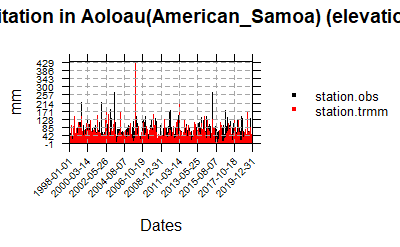

```r
temporalPlot(station.obs,station.trmm, xyplot.custom = list(main = paste("Precipitation in",station.trmm$Metadata$name,"(elevation",precip_trmm$Metadata$altitude[i],"m)"), ylab = "mm"))
```

```r
# temporalPlot(station.obs,station.reanalysis, xyplot.custom = list(main = paste("Precipitation in",station.trmm$Metadata$name,"(elevation",precip_trmm$Metadata$altitude[i],"m)"), ylab = "mm"))
```

```r
index.obs <- valueIndex1D(station.obs$Data[!is.na(station.obs$Data)],index.codes=c("Skewness","SDII","R10","R10p","R20","R20p","P98Wet"))
index.obs <- c(index.obs, valueIndex1D(station.obs$Data[!is.na(station.obs$Data)], index.codes = "P98WetAmount"))
index.obs.rv20max <- MaxReturnValue(station.obs)
```

```
[2021-03-25 18:27:33] Performing annual aggregation...
[2021-03-25 18:27:33] Done.
[2021-03-25 18:27:33] - Computing climatology...
[2021-03-25 18:27:33] - Done.
```

```r
index.trmm <- valueIndex1D(station.trmm$Data,index.codes=c("Skewness","SDII","R10","R10p","R20","R20p","P98Wet","P98WetAmount"))
index.trmm.rv20max <- MaxReturnValue(station.trmm)
```

```
[2021-03-25 18:27:33] Performing annual aggregation...
[2021-03-25 18:27:33] Done.
[2021-03-25 18:27:33] - Computing climatology...
[2021-03-25 18:27:33] - Done.
```

```r
# index.reanalysis <- valueIndex1D(station.reanalysis$Data,index.codes=c("Skewness","SDII","R10","R10p","R20","R20p","P98Wet","P98WetAmount"))
# index.reanalysis.rv20max <- MaxReturnValue(station.reanalysis)
```

```r
index.obs <- c(index.obs, index.obs.rv20max)
index.trmm <- c(index.trmm, index.trmm.rv20max)
# index.reanalysis <- c(index.reanalysis, index.reanalysis.rv20max)
```

```r
df <- data.frame(index.obs,index.trmm)
colnames(df) <- c("Obs", "TRMM")
format(df, digits = 3, scientific = 5)
```

|  | Obs | TRMM |
| --- | --- | --- |
| Skewness | 4.393 | 6.111 |
| SDII | 15.300 | 15.091 |
| R10 | 0.239 | 0.187 |
| R10p | 60145.000 | 46166.789 |
| R20 | 0.135 | 0.105 |
| R20p | 48076.900 | 36777.299 |
| P98Wet | 84.050 | 81.525 |
| P98WetAmount | 10493.700 | 8364.180 |
| RV20_max | 248.003 | 246.916 |

### Assessment conditioned on WT

#### k=5

```r
station.obs.cl1 <- subsetDimension(station.obs, dimension = "time", indices = which(kmModel5$cluster == 1))
station.obs.cl2 <- subsetDimension(station.obs, dimension = "time", indices = which(kmModel5$cluster == 2))
station.obs.cl3 <- subsetDimension(station.obs, dimension = "time", indices = which(kmModel5$cluster == 3))
station.obs.cl4 <- subsetDimension(station.obs, dimension = "time", indices = which(kmModel5$cluster == 4))
station.obs.cl5 <- subsetDimension(station.obs, dimension = "time", indices = which(kmModel5$cluster == 5))
```

```r
station.trmm.cl1 <- subsetDimension(station.trmm, dimension = "time", indices = which(kmModel5$cluster == 1))
station.trmm.cl2 <- subsetDimension(station.trmm, dimension = "time", indices = which(kmModel5$cluster == 2))
station.trmm.cl3 <- subsetDimension(station.trmm, dimension = "time", indices = which(kmModel5$cluster == 3))
station.trmm.cl4 <- subsetDimension(station.trmm, dimension = "time", indices = which(kmModel5$cluster == 4))
station.trmm.cl5 <- subsetDimension(station.trmm, dimension = "time", indices = which(kmModel5$cluster == 5))
```

```r
index.obs.cl1 <- valueIndex1D(station.obs.cl1$Data,index.codes=c("Skewness","SDII","R10","R10p","R20","R20p","P98Wet"))
index.obs.cl1 <- c(index.obs.cl1, valueIndex1D(station.obs.cl1$Data[!is.na(station.obs.cl1$Data)], index.codes = "P98WetAmount"))
index.obs.cl1.rv20max <- MaxReturnValue(station.obs.cl1)
```

```
[2021-03-25 18:27:34] Performing annual aggregation...
[2021-03-25 18:27:34] Done.
[2021-03-25 18:27:34] - Computing climatology...
[2021-03-25 18:27:34] - Done.
```

```r
index.trmm.cl1 <- valueIndex1D(station.trmm.cl1$Data,index.codes=c("Skewness","SDII","R10","R10p","R20","R20p","P98Wet"))
index.trmm.cl1 <- c(index.trmm.cl1, valueIndex1D(station.trmm.cl1$Data[!is.na(station.trmm.cl1$Data)], index.codes = "P98WetAmount"))
index.trmm.cl1.rv20max <- MaxReturnValue(station.trmm.cl1)
```

```
[2021-03-25 18:27:34] Performing annual aggregation...
[2021-03-25 18:27:34] Done.
[2021-03-25 18:27:34] - Computing climatology...
[2021-03-25 18:27:34] - Done.
```

```r
index.obs.cl1 <- c(index.obs.cl1, index.obs.cl1.rv20max)
index.trmm.cl1 <- c(index.trmm.cl1, index.trmm.cl1.rv20max)
```

##### Index assessment conditioned on WT1

```r
df <- data.frame(index.obs.cl1,index.trmm.cl1)
colnames(df) <- c("Obs", "TRMM")
format(df, digits = 3, scientific = 5)
```

|  | Obs | TRMM |
| --- | --- | --- |
| Skewness | 3.786 | 5.309 |
| SDII | 13.771 | 13.534 |
| R10 | 0.204 | 0.135 |
| R10p | 12234.800 | 8167.170 |
| R20 | 0.114 | 0.072 |
| R20p | 9622.700 | 6387.000 |
| P98Wet | 78.280 | 70.610 |
| P98WetAmount | 2121.900 | 1539.480 |
| RV20_max | 129.053 | 134.905 |

```r
index.obs.cl2 <- valueIndex1D(station.obs.cl2$Data,index.codes=c("Skewness","SDII","R10","R10p","R20","R20p","P98Wet"))
index.obs.cl2 <- c(index.obs.cl2, valueIndex1D(station.obs.cl2$Data[!is.na(station.obs.cl2$Data)], index.codes = "P98WetAmount"))
index.obs.cl2.rv20max <- MaxReturnValue(station.obs.cl2)
```

```
[2021-03-25 18:27:34] Performing annual aggregation...
[2021-03-25 18:27:34] Done.
[2021-03-25 18:27:34] - Computing climatology...
[2021-03-25 18:27:34] - Done.
```

```r
index.trmm.cl2 <- valueIndex1D(station.trmm.cl2$Data,index.codes=c("Skewness","SDII","R10","R10p","R20","R20p","P98Wet"))
index.trmm.cl2 <- c(index.trmm.cl2, valueIndex1D(station.trmm.cl2$Data[!is.na(station.trmm.cl2$Data)], index.codes = "P98WetAmount"))
index.trmm.cl2.rv20max <- MaxReturnValue(station.trmm.cl2)
```

```
[2021-03-25 18:27:34] Performing annual aggregation...
[2021-03-25 18:27:34] Done.
[2021-03-25 18:27:34] - Computing climatology...
[2021-03-25 18:27:34] - Done.
```

```r
index.obs.cl2 <- c(index.obs.cl2, index.obs.cl2.rv20max)
index.trmm.cl2<- c(index.trmm.cl2, index.trmm.cl2.rv20max)
```

##### Index assessment conditioned on WT2

```r
df <- data.frame(index.obs.cl2,index.trmm.cl2)
colnames(df) <- c("Obs", "TRMM")
format(df, digits = 3, scientific = 5)
```

|  | Obs | TRMM |
| --- | --- | --- |
| Skewness | 4.250 | 3.881 |
| SDII | 18.994 | 15.821 |
| R10 | 0.294 | 0.233 |
| R10p | 10717.000 | 7436.460 |
| R20 | 0.173 | 0.137 |
| R20p | 8853.300 | 6012.030 |
| P98Wet | 111.056 | 82.618 |
| P98WetAmount | 1937.400 | 1297.980 |
| RV20_max | 137.570 | 129.771 |

```r
index.obs.cl3 <- valueIndex1D(station.obs.cl3$Data,index.codes=c("Skewness","SDII","R10","R10p","R20","R20p","P98Wet"))
index.obs.cl3 <- c(index.obs.cl3, valueIndex1D(station.obs.cl3$Data[!is.na(station.obs.cl3$Data)], index.codes = "P98WetAmount"))
index.obs.cl3.rv20max <- MaxReturnValue(station.obs.cl3)
```

```
[2021-03-25 18:27:34] Performing annual aggregation...
[2021-03-25 18:27:34] Done.
[2021-03-25 18:27:34] - Computing climatology...
[2021-03-25 18:27:34] - Done.
```

```r
index.trmm.cl3 <- valueIndex1D(station.trmm.cl3$Data,index.codes=c("Skewness","SDII","R10","R10p","R20","R20p","P98Wet"))
index.trmm.cl3 <- c(index.trmm.cl3, valueIndex1D(station.trmm.cl3$Data[!is.na(station.trmm.cl3$Data)], index.codes = "P98WetAmount"))
index.trmm.cl3.rv20max <- MaxReturnValue(station.trmm.cl3)
```

```
[2021-03-25 18:27:35] Performing annual aggregation...
[2021-03-25 18:27:35] Done.
[2021-03-25 18:27:35] - Computing climatology...
[2021-03-25 18:27:35] - Done.
```

```r
index.obs.cl3 <- c(index.obs.cl3, index.obs.cl3.rv20max)
index.trmm.cl3 <- c(index.trmm.cl3, index.trmm.cl3.rv20max)
```

##### Index assessment conditioned on WT3

```r
df <- data.frame(index.obs.cl3,index.trmm.cl3)
colnames(df) <- c("Obs", "TRMM")
format(df, digits = 3, scientific = 5)
```

|  | Obs | TRMM |
| --- | --- | --- |
| Skewness | 3.739 | 3.994 |
| SDII | 15.331 | 15.404 |
| R10 | 0.240 | 0.195 |
| R10p | 14480.800 | 11965.590 |
| R20 | 0.131 | 0.108 |
| R20p | 11373.800 | 9412.770 |
| P98Wet | 84.720 | 91.818 |
| P98WetAmount | 2370.100 | 2108.400 |
| RV20_max | 185.684 | 141.268 |

```r
index.obs.cl4 <- valueIndex1D(station.obs.cl4$Data,index.codes=c("Skewness","SDII","R10","R10p","R20","R20p","P98Wet"))
index.obs.cl4 <- c(index.obs.cl4, valueIndex1D(station.obs.cl4$Data[!is.na(station.obs.cl4$Data)], index.codes = "P98WetAmount"))
index.obs.cl4.rv20max <- MaxReturnValue(station.obs.cl4)
```

```
[2021-03-25 18:27:35] Performing annual aggregation...
[2021-03-25 18:27:35] Done.
[2021-03-25 18:27:35] - Computing climatology...
[2021-03-25 18:27:35] - Done.
```

```r
index.trmm.cl4 <- valueIndex1D(station.trmm.cl4$Data,index.codes=c("Skewness","SDII","R10","R10p","R20","R20p","P98Wet"))
index.trmm.cl4 <- c(index.trmm.cl4, valueIndex1D(station.trmm.cl4$Data[!is.na(station.trmm.cl4$Data)], index.codes = "P98WetAmount"))
index.trmm.cl4.rv20max <- MaxReturnValue(station.trmm.cl4)
```

```
[2021-03-25 18:27:35] Performing annual aggregation...
[2021-03-25 18:27:35] Done.
[2021-03-25 18:27:35] - Computing climatology...
[2021-03-25 18:27:35] - Done.
```

```r
index.obs.cl4 <- c(index.obs.cl4, index.obs.cl4.rv20max)
index.trmm.cl4 <- c(index.trmm.cl4, index.trmm.cl4.rv20max)
```

##### Index assessment conditioned on WT4

```r
df <- data.frame(index.obs.cl4,index.trmm.cl4)
colnames(df) <- c("Obs", "TRMM")
format(df, digits = 3, scientific = 5)
```

|  | Obs | TRMM |
| --- | --- | --- |
| Skewness | 4.386 | 7.774 |
| SDII | 14.791 | 17.077 |
| R10 | 0.230 | 0.208 |
| R10p | 12880.500 | 12802.920 |
| R20 | 0.134 | 0.128 |
| R20p | 10364.400 | 10718.520 |
| P98Wet | 77.940 | 79.236 |
| P98WetAmount | 2208.400 | 2507.550 |
| RV20_max | 166.727 | 299.581 |

```r
index.obs.cl5 <- valueIndex1D(station.obs.cl5$Data,index.codes=c("Skewness","SDII","R10","R10p","R20","R20p","P98Wet"))
index.obs.cl5 <- c(index.obs.cl5, valueIndex1D(station.obs.cl5$Data[!is.na(station.obs.cl5$Data)], index.codes = "P98WetAmount"))
index.obs.cl5.rv20max <- MaxReturnValue(station.obs.cl5)
```

```
[2021-03-25 18:27:35] Performing annual aggregation...
[2021-03-25 18:27:35] Done.
[2021-03-25 18:27:35] - Computing climatology...
[2021-03-25 18:27:35] - Done.
```

```r
index.trmm.cl5 <- valueIndex1D(station.trmm.cl5$Data,index.codes=c("Skewness","SDII","R10","R10p","R20","R20p","P98Wet"))
index.trmm.cl5 <- c(index.trmm.cl5, valueIndex1D(station.trmm.cl5$Data[!is.na(station.trmm.cl5$Data)], index.codes = "P98WetAmount"))
index.trmm.cl5.rv20max <- MaxReturnValue(station.trmm.cl5)
```

```
[2021-03-25 18:27:35] Performing annual aggregation...
[2021-03-25 18:27:35] Done.
[2021-03-25 18:27:35] - Computing climatology...
[2021-03-25 18:27:35] - Done.
```

```r
index.obs.cl5 <- c(index.obs.cl5, index.obs.cl5.rv20max)
index.trmm.cl5 <- c(index.trmm.cl5, index.trmm.cl5.rv20max)
```

##### Index assessment conditioned on WT5

```r
df <- data.frame(index.obs.cl5,index.trmm.cl5)
colnames(df) <- c("Obs", "TRMM")
format(df, digits = 3, scientific = 5)
```

|  | Obs | TRMM |
| --- | --- | --- |
| Skewness | 5.211 | 4.4994 |
| SDII | 15.023 | 12.8333 |
| R10 | 0.200 | 0.1438 |
| R10p | 9831.900 | 5794.6499 |
| R20 | 0.111 | 0.0696 |
| R20p | 7862.700 | 4246.9799 |
| P98Wet | 82.880 | 71.2812 |
| P98WetAmount | 1854.400 | 1082.0700 |
| RV20_max | 183.428 | 117.7269 |

##### Difference between obs and raw/WT-conditioned data

```r
diff.df <- data.frame(abs(index.trmm-index.obs),abs(index.trmm.cl1-index.obs.cl1),
                      abs(index.trmm.cl2-index.obs.cl2), abs(index.trmm.cl3-index.obs.cl3), abs(index.trmm.cl4-index.obs.cl4), abs(index.trmm.cl5-index.obs.cl5)
                      )
colnames(diff.df) <- c("Raw","WT1", "WT2","WT3", "WT4","WT5")

format(diff.df, digits = 3, scientific = 5)
```

|  | Raw | WT1 | WT2 | WT3 | WT4 | WT5 |
| --- | --- | --- | --- | --- | --- | --- |
| Skewness | 1.7180 | 1.5228 | 0.3685 | 0.2556 | 3.38755 | 0.7117 |
| SDII | 0.2092 | 0.2375 | 3.1727 | 0.0732 | 2.28659 | 2.1901 |
| R10 | 0.0523 | 0.0690 | 0.0612 | 0.0447 | 0.02204 | 0.0566 |
| R10p | 13978.2110 | 4067.6302 | 3280.5401 | 2515.2103 | 77.58031 | 4037.2501 |
| R20 | 0.0303 | 0.0417 | 0.0364 | 0.0231 | 0.00606 | 0.0416 |
| R20p | 11299.6008 | 3235.7002 | 2841.2701 | 1961.0302 | 354.11974 | 3615.7201 |
| P98Wet | 2.5250 | 7.6702 | 28.4384 | 7.0980 | 1.29600 | 11.5988 |
| P98WetAmount | 2129.5202 | 582.4200 | 639.4200 | 261.7001 | 299.14997 | 772.3300 |
| RV20_max | 1.0871 | 5.8514 | 7.7987 | 44.4161 | 132.85393 | 65.7009 |

#### k = 6

```r
station.obs.cl1 <- subsetDimension(station.obs, dimension = "time", indices = which(kmModel6$cluster == 1))
station.obs.cl2 <- subsetDimension(station.obs, dimension = "time", indices = which(kmModel6$cluster == 2))
station.obs.cl3 <- subsetDimension(station.obs, dimension = "time", indices = which(kmModel6$cluster == 3))
station.obs.cl4 <- subsetDimension(station.obs, dimension = "time", indices = which(kmModel6$cluster == 4))
station.obs.cl5 <- subsetDimension(station.obs, dimension = "time", indices = which(kmModel6$cluster == 5))
station.obs.cl6 <- subsetDimension(station.obs, dimension = "time", indices = which(kmModel6$cluster == 6))
```

```r
station.trmm.cl1 <- subsetDimension(station.trmm, dimension = "time", indices = which(kmModel6$cluster == 1))
station.trmm.cl2 <- subsetDimension(station.trmm, dimension = "time", indices = which(kmModel6$cluster == 2))
station.trmm.cl3 <- subsetDimension(station.trmm, dimension = "time", indices = which(kmModel6$cluster == 3))
station.trmm.cl4 <- subsetDimension(station.trmm, dimension = "time", indices = which(kmModel6$cluster == 4))
station.trmm.cl5 <- subsetDimension(station.trmm, dimension = "time", indices = which(kmModel6$cluster == 5))
station.trmm.cl6 <- subsetDimension(station.trmm, dimension = "time", indices = which(kmModel6$cluster == 6))
```

```r
index.obs.cl1 <- valueIndex1D(station.obs.cl1$Data,index.codes=c("Skewness","SDII","R10","R10p","R20","R20p","P98Wet"))
index.obs.cl1 <- c(index.obs.cl1, valueIndex1D(station.obs.cl1$Data[!is.na(station.obs.cl1$Data)], index.codes = "P98WetAmount"))
index.obs.cl1.rv20max <- MaxReturnValue(station.obs.cl1)
```

```
[2021-03-25 18:27:36] Performing annual aggregation...
[2021-03-25 18:27:36] Done.
[2021-03-25 18:27:36] - Computing climatology...
[2021-03-25 18:27:36] - Done.
```

```r
index.trmm.cl1 <- valueIndex1D(station.trmm.cl1$Data,index.codes=c("Skewness","SDII","R10","R10p","R20","R20p","P98Wet"))
index.trmm.cl1 <- c(index.trmm.cl1, valueIndex1D(station.trmm.cl1$Data[!is.na(station.trmm.cl1$Data)], index.codes = "P98WetAmount"))
index.trmm.cl1.rv20max <- MaxReturnValue(station.trmm.cl1)
```

```
[2021-03-25 18:27:36] Performing annual aggregation...
[2021-03-25 18:27:36] Done.
[2021-03-25 18:27:36] - Computing climatology...
[2021-03-25 18:27:36] - Done.
```

```r
index.obs.cl1 <- c(index.obs.cl1, index.obs.cl1.rv20max)
index.trmm.cl1 <- c(index.trmm.cl1, index.trmm.cl1.rv20max)
```

##### Index assessment conditioned on WT1

```r
df <- data.frame(index.obs.cl1,index.trmm.cl1)
colnames(df) <- c("Obs", "TRMM")
format(df, digits = 3, scientific = 5)
```

|  | Obs | TRMM |
| --- | --- | --- |
| Skewness | 4.922 | 4.2209 |
| SDII | 15.061 | 14.9289 |
| R10 | 0.229 | 0.1746 |
| R10p | 12116.000 | 9266.9998 |
| R20 | 0.135 | 0.0922 |
| R20p | 9765.800 | 7205.0698 |
| P98Wet | 73.416 | 87.7500 |
| P98WetAmount | 2049.300 | 1617.9000 |
| RV20_max | 201.907 | 115.4209 |

```r
index.obs.cl2 <- valueIndex1D(station.obs.cl2$Data,index.codes=c("Skewness","SDII","R10","R10p","R20","R20p","P98Wet"))
index.obs.cl2 <- c(index.obs.cl2, valueIndex1D(station.obs.cl2$Data[!is.na(station.obs.cl2$Data)], index.codes = "P98WetAmount"))
index.obs.cl2.rv20max <- MaxReturnValue(station.obs.cl2)
```

```
[2021-03-25 18:27:37] Performing annual aggregation...
[2021-03-25 18:27:37] Done.
[2021-03-25 18:27:37] - Computing climatology...
[2021-03-25 18:27:37] - Done.
```

```r
index.trmm.cl2 <- valueIndex1D(station.trmm.cl2$Data,index.codes=c("Skewness","SDII","R10","R10p","R20","R20p","P98Wet"))
index.trmm.cl2 <- c(index.trmm.cl2, valueIndex1D(station.trmm.cl2$Data[!is.na(station.trmm.cl2$Data)], index.codes = "P98WetAmount"))
index.trmm.cl2.rv20max <- MaxReturnValue(station.trmm.cl2)
```

```
[2021-03-25 18:27:37] Performing annual aggregation...
[2021-03-25 18:27:37] Done.
[2021-03-25 18:27:37] - Computing climatology...
[2021-03-25 18:27:37] - Done.
```

```r
index.obs.cl2 <- c(index.obs.cl2, index.obs.cl2.rv20max)
index.trmm.cl2<- c(index.trmm.cl2, index.trmm.cl2.rv20max)
```

##### Index assessment conditioned on WT2

```r
df <- data.frame(index.obs.cl2,index.trmm.cl2)
colnames(df) <- c("Obs", "TRMM")
format(df, digits = 3, scientific = 5)
```

|  | Obs | TRMM |
| --- | --- | --- |
| Skewness | 3.596 | 4.211 |
| SDII | 17.053 | 15.774 |
| R10 | 0.266 | 0.220 |
| R10p | 10477.400 | 8009.910 |
| R20 | 0.144 | 0.127 |
| R20p | 8375.400 | 6423.240 |
| P98Wet | 97.830 | 91.726 |
| P98WetAmount | 1786.300 | 1413.360 |
| RV20_max | 108.370 | 140.254 |

```r
index.obs.cl3 <- valueIndex1D(station.obs.cl3$Data,index.codes=c("Skewness","SDII","R10","R10p","R20","R20p","P98Wet"))
index.obs.cl3 <- c(index.obs.cl3, valueIndex1D(station.obs.cl3$Data[!is.na(station.obs.cl3$Data)], index.codes = "P98WetAmount"))
index.obs.cl3.rv20max <- MaxReturnValue(station.obs.cl3)
```

```
[2021-03-25 18:27:37] Performing annual aggregation...
[2021-03-25 18:27:37] Done.
[2021-03-25 18:27:37] - Computing climatology...
[2021-03-25 18:27:37] - Done.
```

```r
index.trmm.cl3 <- valueIndex1D(station.trmm.cl3$Data,index.codes=c("Skewness","SDII","R10","R10p","R20","R20p","P98Wet"))
index.trmm.cl3 <- c(index.trmm.cl3, valueIndex1D(station.trmm.cl3$Data[!is.na(station.trmm.cl3$Data)], index.codes = "P98WetAmount"))
index.trmm.cl3.rv20max <- MaxReturnValue(station.trmm.cl3)
```

```
[2021-03-25 18:27:37] Performing annual aggregation...
[2021-03-25 18:27:37] Done.
[2021-03-25 18:27:37] - Computing climatology...
[2021-03-25 18:27:37] - Done.
```

```r
index.obs.cl3 <- c(index.obs.cl3, index.obs.cl3.rv20max)
index.trmm.cl3 <- c(index.trmm.cl3, index.trmm.cl3.rv20max)
```

##### Index assessment conditioned on WT3

```r
df <- data.frame(index.obs.cl3,index.trmm.cl3)
colnames(df) <- c("Obs", "TRMM")
format(df, digits = 3, scientific = 5)
```

|  | Obs | TRMM |
| --- | --- | --- |
| Skewness | 4.055 | 4.6877 |
| SDII | 14.614 | 12.8265 |
| R10 | 0.197 | 0.1412 |
| R10p | 7379.400 | 4451.6699 |
| R20 | 0.105 | 0.0693 |
| R20p | 5803.800 | 3268.1699 |
| P98Wet | 84.004 | 72.3828 |
| P98WetAmount | 1341.600 | 846.1500 |
| RV20_max | 150.203 | 115.1843 |

```r
index.obs.cl4 <- valueIndex1D(station.obs.cl4$Data,index.codes=c("Skewness","SDII","R10","R10p","R20","R20p","P98Wet"))
index.obs.cl4 <- c(index.obs.cl4, valueIndex1D(station.obs.cl4$Data[!is.na(station.obs.cl4$Data)], index.codes = "P98WetAmount"))
index.obs.cl4.rv20max <- MaxReturnValue(station.obs.cl4)
```

```
[2021-03-25 18:27:37] Performing annual aggregation...
[2021-03-25 18:27:37] Done.
[2021-03-25 18:27:38] - Computing climatology...
[2021-03-25 18:27:38] - Done.
```

```r
index.trmm.cl4 <- valueIndex1D(station.trmm.cl4$Data,index.codes=c("Skewness","SDII","R10","R10p","R20","R20p","P98Wet"))
index.trmm.cl4 <- c(index.trmm.cl4, valueIndex1D(station.trmm.cl4$Data[!is.na(station.trmm.cl4$Data)], index.codes = "P98WetAmount"))
index.trmm.cl4.rv20max <- MaxReturnValue(station.trmm.cl4)
```

```
[2021-03-25 18:27:38] Performing annual aggregation...
[2021-03-25 18:27:38] Done.
[2021-03-25 18:27:38] - Computing climatology...
[2021-03-25 18:27:38] - Done.
```

```r
index.obs.cl4 <- c(index.obs.cl4, index.obs.cl4.rv20max)
index.trmm.cl4 <- c(index.trmm.cl4, index.trmm.cl4.rv20max)
```

##### Index assessment conditioned on WT4

```r
df <- data.frame(index.obs.cl4,index.trmm.cl4)
colnames(df) <- c("Obs", "TRMM")
format(df, digits = 3, scientific = 5)
```

|  | Obs | TRMM |
| --- | --- | --- |
| Skewness | 3.903 | 4.8145 |
| SDII | 13.830 | 12.9781 |
| R10 | 0.207 | 0.1318 |
| R10p | 10574.500 | 6643.8598 |
| R20 | 0.112 | 0.0685 |
| R20p | 8219.400 | 5116.1399 |
| P98Wet | 79.030 | 67.2846 |
| P98WetAmount | 1867.200 | 1179.1800 |
| RV20_max | 147.159 | 119.0653 |

```r
index.obs.cl5 <- valueIndex1D(station.obs.cl5$Data,index.codes=c("Skewness","SDII","R10","R10p","R20","R20p","P98Wet"))
index.obs.cl5 <- c(index.obs.cl5, valueIndex1D(station.obs.cl5$Data[!is.na(station.obs.cl5$Data)], index.codes = "P98WetAmount"))
index.obs.cl5.rv20max <- MaxReturnValue(station.obs.cl5)
```

```
[2021-03-25 18:27:38] Performing annual aggregation...
[2021-03-25 18:27:38] Done.
[2021-03-25 18:27:38] - Computing climatology...
[2021-03-25 18:27:38] - Done.
```

```r
index.trmm.cl5 <- valueIndex1D(station.trmm.cl5$Data,index.codes=c("Skewness","SDII","R10","R10p","R20","R20p","P98Wet"))
index.trmm.cl5 <- c(index.trmm.cl5, valueIndex1D(station.trmm.cl5$Data[!is.na(station.trmm.cl5$Data)], index.codes = "P98WetAmount"))
index.trmm.cl5.rv20max <- MaxReturnValue(station.trmm.cl5)
```

```
[2021-03-25 18:27:38] Performing annual aggregation...
[2021-03-25 18:27:38] Done.
[2021-03-25 18:27:38] - Computing climatology...
[2021-03-25 18:27:38] - Done.
```

```r
index.obs.cl5 <- c(index.obs.cl5, index.obs.cl5.rv20max)
index.trmm.cl5 <- c(index.trmm.cl5, index.trmm.cl5.rv20max)
```

##### Index assessment conditioned on WT5

```r
df <- data.frame(index.obs.cl5,index.trmm.cl5)
colnames(df) <- c("Obs", "TRMM")
format(df, digits = 3, scientific = 5)
```

|  | Obs | TRMM |
| --- | --- | --- |
| Skewness | 4.403 | 7.570 |
| SDII | 14.819 | 17.409 |
| R10 | 0.226 | 0.200 |
| R10p | 12611.200 | 12673.350 |
| R20 | 0.131 | 0.127 |
| R20p | 10149.200 | 10782.060 |
| P98Wet | 78.660 | 90.130 |
| P98WetAmount | 2219.100 | 2501.850 |
| RV20_max | 172.718 | 277.875 |

```r
index.obs.cl6 <- valueIndex1D(station.obs.cl6$Data,index.codes=c("Skewness","SDII","R10","R10p","R20","R20p","P98Wet"))
index.obs.cl6 <- c(index.obs.cl6, valueIndex1D(station.obs.cl6$Data[!is.na(station.obs.cl6$Data)], index.codes = "P98WetAmount"))
index.obs.cl6.rv20max <- MaxReturnValue(station.obs.cl6)
```

```
[2021-03-25 18:27:38] Performing annual aggregation...
[2021-03-25 18:27:38] Done.
[2021-03-25 18:27:38] - Computing climatology...
[2021-03-25 18:27:38] - Done.
```

```r
index.trmm.cl6 <- valueIndex1D(station.trmm.cl6$Data,index.codes=c("Skewness","SDII","R10","R10p","R20","R20p","P98Wet"))
index.trmm.cl6 <- c(index.trmm.cl6, valueIndex1D(station.trmm.cl6$Data[!is.na(station.trmm.cl6$Data)], index.codes = "P98WetAmount"))
index.trmm.cl6.rv20max <- MaxReturnValue(station.trmm.cl6)
```

```
[2021-03-25 18:27:38] Performing annual aggregation...
[2021-03-25 18:27:38] Done.
[2021-03-25 18:27:38] - Computing climatology...
[2021-03-25 18:27:38] - Done.
```

```r
index.obs.cl6 <- c(index.obs.cl6, index.obs.cl6.rv20max)
index.trmm.cl6 <- c(index.trmm.cl6, index.trmm.cl6.rv20max)
```

##### Index assessment conditioned on WT6

```r
df <- data.frame(index.obs.cl6,index.trmm.cl6)
colnames(df) <- c("Obs", "TRMM")
format(df, digits = 3, scientific = 5)
```

|  | Obs | TRMM |
| --- | --- | --- |
| Skewness | 4.867 | 3.516 |
| SDII | 18.095 | 15.327 |
| R10 | 0.278 | 0.243 |
| R10p | 6986.500 | 5121.000 |
| R20 | 0.167 | 0.135 |
| R20p | 5763.300 | 3982.620 |
| P98Wet | 81.594 | 71.334 |
| P98WetAmount | 1320.300 | 771.720 |
| RV20_max | 108.267 | 98.998 |

##### Difference between obs and raw/WT-conditioned data

```r
diff.df <- data.frame(abs(index.trmm-index.obs),abs(index.trmm.cl1-index.obs.cl1),
                      abs(index.trmm.cl2-index.obs.cl2), abs(index.trmm.cl3-index.obs.cl3), abs(index.trmm.cl4-index.obs.cl4), abs(index.trmm.cl5-index.obs.cl5),abs(index.trmm.cl6-index.obs.cl6)
                      )
colnames(diff.df) <- c("Raw","WT1", "WT2","WT3", "WT4","WT5","WT6")

format(diff.df, digits = 3, scientific = 5)
```

|  | Raw | WT1 | WT2 | WT3 | WT4 | WT5 | WT6 |
| --- | --- | --- | --- | --- | --- | --- | --- |
| Skewness | 1.7180 | 0.7011 | 0.6142 | 0.6331 | 0.9113 | 3.1672 | 1.3509 |
| SDII | 0.2092 | 0.1317 | 1.2788 | 1.7876 | 0.8523 | 2.5895 | 2.7676 |
| R10 | 0.0523 | 0.0542 | 0.0459 | 0.0560 | 0.0754 | 0.0257 | 0.0351 |
| R10p | 13978.2110 | 2849.0002 | 2467.4902 | 2927.7301 | 3930.6402 | 62.1497 | 1865.5001 |
| R20 | 0.0303 | 0.0427 | 0.0167 | 0.0359 | 0.0432 | 0.0039 | 0.0324 |
| R20p | 11299.6008 | 2560.7302 | 1952.1601 | 2535.6301 | 3103.2601 | 632.8597 | 1780.6801 |
| P98Wet | 2.5250 | 14.3340 | 6.1038 | 11.6212 | 11.7454 | 11.4696 | 10.2600 |
| P98WetAmount | 2129.5202 | 431.4000 | 372.9400 | 495.4500 | 688.0200 | 282.7500 | 548.5800 |
| RV20_max | 1.0871 | 86.4862 | 31.8845 | 35.0183 | 28.0941 | 105.1569 | 9.2688 |